# NMR 16S rRNA gene sequencing analysis

# Preface

This document contains all statistical analyses conducted on the 16S rRNA gene sequencing output.

# 1 Processing QIIME2 output into phyloseq format, agglomeration by taxonomic rank

## 1.1 Introduction

Once you produce the feature table, taxonomic classification, and the phylogenetic tree in QIIME2, it’s time to perform downstream processing in R. First, we need to import the QZA files using `qiime2R` package. We will convert the QZA files directly into phyloseq objects.

The final output is the dataframe ps.q.agg and metadata custom.md. ps.q.agg and custom.md are saved as tsv files and rds files.

1. ps.q.agg is an ASV table with 7-13 columns  
   (7 if agglomerating at Phylum, 13 if agglomerating at ASV level):
- `Sample`: samples that were sequenced.
- `Abundance`: Absolute abundance of taxa.
- `class`: short names of animal hosts. The variable is factor with 9 levels at most (B6mouse, DMR, FVBNmouse, hare, MSMmouse, NMR, pvo, rabbit, spalax).  
  The next seven columns may not all be in the table. If you agglomerate by Genus, you don’t see the Species column. And if you agglomerate by Family, you don’t see Genus and Species. But these are taxonomic ranks for ASVs that we got from QIIME2.
- `Kingdom`
- `Phylum`
- `Class`
- `Order`
- `Family`
- `Genus`
- `Species`
- `OTU`: ASV IDs from QIIME2. phyloseq uses OTU, so we keep it as it is. Not included if you are not aggomerating by ASVs.
- `RelativeAbundance`: Relative abundance of taxa in each sample. We calculate it by summing the Abundance of a taxon in each sample and dividing that sum by the sum of reads in that sample.
- `MeanRelativeAbundance`: Average relative abundance of a taxon in each host. We calculate it by summing the absolute abundance of a taxon from all samples in a host and dividing by the sum of reads in that host.
2. custom.md is a dataframe with metadata. It has 5 variables:
- `class`: same as in ps.q.agg
- `animal`: full names of animal hosts. The variable is factor with 9 levels at most (“Fukomys Damarensis”, “FVB/N mouse”, “Lepus europaeus”, “MSM/Ms mouse”, “naked mole rat”, “Nannospalax leucodon”, “Oryctolagus cuniculus”, “Pteromys volans orii”, “SPF mouse, B6”). “Fukomys Damarensis” is DMR, “FVB/N mouse” is FVBNmouse, “Lepus europaeus” is hare, “MSM/Ms mouse” is MSMmouse, “naked mole rat” is NMR, “Nannospalax leucodon” is spalax, “Oryctolagus cuniculus” is rabbit, “Pteromys volans orii” is pvo, “SPF mouse, B6” is B6mouse.
- `sex`: sex of tested samples. Not all samples have it. It is a factor with four levels (F, M, NR, -)
- `birthday`: date of birth of samples. Not all samples have it. It is a Date format variable.
- `Sample`: same as in ps.q.agg

## 1.2 Load necessary libraries.

```r
# if (!requireNamespace("devtools", quietly = TRUE)){install.packages("devtools")}
# devtools::install_github("jbisanz/qiime2R")
# install.packages(
#   "microViz",
#   repos = c(davidbarnett = "https://david-barnett.r-universe.dev", getOption("repos"))
# )
# install.packages(c("tidyverse"))
# if(!requireNamespace("BiocManager")){
#   install.packages("BiocManager")
# }
# BiocManager::install("phyloseq")
library(qiime2R)
library(phyloseq)
library(tidyverse)
```

```
## ✖ purrr::%||%()   masks base::%||%()
```

```r
library(microViz)
```

```
## microViz version 0.12.1 - Copyright (C) 2021-2024 David Barnett
## ! Website: https://david-barnett.github.io/microViz
## ✔ Useful?  For citation details, run: `citation("microViz")`
## ✖ Silence? `suppressPackageStartupMessages(library(microViz))`
```

## 1.3 Import data from QIIME2.

```r
truncationlvl<-"234" # truncation level that we chose in QIIME2
authorname<-"pooled" # name of the folder with QIIME2 output
# qza_file_date_time<-"20240425_02_57_13"
qza_file_date_time<-"20260209_16_33_25"
read.end.type<-"single" # single reads or paired reads: decided in QIIME2
qiimedir<-file.path("./output/qiime",paste0(authorname,"-qiime"),
                    paste(qza_file_date_time,read.end.type,truncationlvl,sep="-")) # directory with QZA files

metadatadir<-file.path("./data/metadata",
                       paste(authorname,"metadata",sep = "-")) # directory with metadata
```

Specify the name of your metadata file.

```r
metadata.filename<-file.path(metadatadir,
                          paste("filenames",read.end.type,
                                authorname,"raw-supercomp.tsv",
                                sep = "-"))
biosample.md<-read.table("./data/metadata/pooled-metadata/biosample_metadata_for_ncbi.tsv",
                         sep = "\t", header= T)
```

## 1.4 Import qza files and convert them into a phyloseq object.

```r
ps.q<-qza_to_phyloseq(
  features = file.path(qiimedir, paste0(paste(qza_file_date_time,
                                              authorname,
                                              read.end.type,
                                              "trimmed-dada2-table",
                                              truncationlvl,
                                              "filtered",
                                              sep="-"),".qza")), # feature table
  taxonomy = file.path(qiimedir,paste0(paste(qza_file_date_time,
                                             authorname,
                                             read.end.type,
                                             "trimmed-dada2",
                                             truncationlvl,
                                             "filtered-taxonomy",
                                             sep="-"),".qza")), # taxonomy
  tree = file.path(qiimedir,paste0(paste(qza_file_date_time,
                                         authorname,
                                         read.end.type,
                                         "trimmed-dada2",
                                         truncationlvl,
                                         "filtered-rooted-tree",
                                         sep="-"),
                                   ".qza")) # rooted tree
)
```

Change the name d__Kingdom to Kingdom.

```r
ps.q.taxtab<-as.data.frame(tax_table(ps.q))
ps.q.taxtab$Kingdom<-
  gsub("d__","",ps.q.taxtab$Kingdom)
tax_table(ps.q)<-as.matrix(ps.q.taxtab)
rm(ps.q.taxtab)
```

## 1.5 Add custom metadata.

```r
custom.md<-read.table(metadata.filename, header = T)
colnames(custom.md)[1]<-"Sample" # set the first column name as Sample
```

Convert the Sample column into row names because phyloseq needs samples as rownames.

Remove absolute.filepath column.

```r
custom.md<-custom.md%>%
  dplyr::select(-absolute.filepath)%>%
  mutate(class= as.factor(class),
         sex = as.factor(sex),
         birthday = as.Date(birthday),
         animal = as.factor(animal))
# birthday=as.Date(ifelse(class=="B6mouse",sampling_date-weeks(12),birthday)))
rownames(custom.md)<-custom.md$Sample
```

Assign the custom metadata as your phyloseq object’s metadata.

```r
sample_data(ps.q)<-custom.md
```

### 1.5.1 For NMR, we create a separate metadata object with age groups.

```r
custom.md.ages<-custom.md%>%
  dplyr::select(Sample,class)%>%
  filter(class=="NMR")%>%
  left_join(biosample.md,by = join_by("Sample" =="host_subject_id"))%>%
  rename("sex"= host_sex,
         "age" = host_age)%>%
  dplyr::select(-organism,-env_broad_scale,
         -env_local_scale, -env_medium,
         -geo_loc_name, -lat_lon,
         -host)%>%
  mutate(age = as.numeric(age),
         agegroup=cut(age, breaks =c(0,10,16),
                      right = FALSE))
```

We create these new levels for differential microbial abundance.

```r
unique_levels <-custom.md.ages %>%
  ungroup()%>%
  distinct(agegroup)%>%
  arrange(agegroup) %>%
  mutate(new_agegroup = paste0("agegroup", agegroup))%>%
  mutate(new_agegroup = gsub("\\(|\\)|\\[|\\]","",new_agegroup))%>%
  mutate(new_agegroup = gsub("\\,","_",new_agegroup))
custom.md.ages <- custom.md.ages %>%
  left_join(unique_levels, by = "agegroup")
```

We preserve the old group names for visualisation.

```r
colnames(custom.md.ages)[which(colnames(custom.md.ages)=="agegroup")]<-"old_agegroup"
colnames(custom.md.ages)[which(colnames(custom.md.ages)=="new_agegroup")]<-"agegroup"

custom.md.ages<-custom.md.ages%>%
  as.data.frame()
rownames(custom.md.ages)<-custom.md.ages$sample_name

# saveRDS(custom.md.ages,file="./output/rdafiles/custom.md.ages.rds")
# write.table(custom.md.ages,file="./output/rtables/pooled/custom.md.ages.tsv",
#             row.names = F,sep = "\t")
```

You can exclude some samples based on class. Specify the excluded classes in a vector, then use the `%in%` operator. It will remove entries of the `class` column (animal hosts) from the `custom.md` object (metadata).

```r
# custom.md<-custom.md[!custom.md$class  %in% c('pal','ppg','pvo','tx',
#                                               'ntccontrol','rabbitcontrol',
#                                               'harecontrol'),]
custom.md<-custom.md[!custom.md$class  %in% c('pal','ppg','tx'),]
```

You can exclude samples based on their library size (total number of reads).

```r
custom.md<-custom.md[!rownames(custom.md) %in%
                       intersect(names(which(colSums(ps.q@otu_table)<20000)),
                                 rownames(custom.md)),]
# saveRDS(custom.md,file="./output/rdafiles/custom.md.rds")
# write.table(custom.md,file="./output/rtables/pooled/custom.md.tsv",
#             row.names = F,sep = "\t")
```

### 1.5.2 Construct the phyloseq object directly from QIIME2 output.

We combine the phyloseq object with new metadata (if we excluded samples).

```r
ps.foo <- phyloseq(otu_table(ps.q),
                   sample_data(custom.md),
                   tax_table(ps.q),
                   phy_tree(ps.q))
ps.q<-ps.foo
rm(ps.foo)
```

Number of features in the unfiltered dataset:

```r
length(rownames(ps.q@tax_table@.Data))
```

```
## [1] 13162
```

Total frequency in the unfiltered dataset:

```r
sum(colSums(ps.q@otu_table@.Data))
```

```
## [1] 13027170
```

Summary statistics (min, median, max, quartiles) of the unfiltered dataset:

```r
ps.q@otu_table@.Data%>%
  colSums()%>%
  summary()
```

```
##    Min. 1st Qu.  Median    Mean 3rd Qu.    Max.
##   21924   58453   88966  131588  154586  416954
```

Select only Bacteria. Remove chloroplast and mitochondria

```r
ps.q<-ps.q %>%
  subset_taxa(Kingdom%in%"Bacteria")%>%
  subset_taxa(!Order %in% "Chloroplast")%>%
  subset_taxa(!Family %in% "Mitochondria")
```

### 1.5.3 Fix empty taxa with higher rank taxon.

Because we want to remove NA values and make ambiguous “uncultured” or “unclassified” taxa more understandable.

```r
ps.q<-tax_fix(ps.q,unknowns = c("NA","uncultured","Unassigned",
                                "uncultured_bacterium","uncultured_rumen",
                                "gut_metagenome","human_gut","mouse_gut",
                                "wallaby_gut","uncultured_soil",
                                "uncultured_organism","uncultured_prokaryote"))
```

## 1.6 Convert the phyloseq object into a dataframe.

```r
ps.q.agg<-ps.q %>%
  psmelt()
ps.q.agg.phylum<-ps.q %>%
  tax_glom("Phylum",NArm = FALSE) %>% # agglomerate by phylum
  psmelt()  # transform the phyloseq object into an R dataframe
ps.q.agg.family<-ps.q %>%
  tax_glom("Family",NArm = FALSE) %>% # agglomerate by family
  psmelt()  # transform the phyloseq object into an R dataframe
ps.q.agg.genus<-ps.q %>%
  tax_glom("Genus",NArm = FALSE) %>% # agglomerate by genus
  psmelt()  # transform the phyloseq object into an R dataframe
```

```r
ps.list <- list("OTU" = ps.q.agg,
               "Phylum" = ps.q.agg.phylum,
               "Family" = ps.q.agg.family,
               "Genus" = ps.q.agg.genus)
for (ps.df.index in names(ps.list)){
  ps.df <- ps.list[[ps.df.index]]
  print(paste("Parsing data from the", ps.df.index, "table"))
  print(paste("Number of rows in the dataframe:", nrow(ps.df)))

  # Remove entries with zero Abundance.
  print("Removing rows with zero Abundance")
  ps.df <- ps.df %>%
    filter(Abundance!=0)%>%
    dplyr::select(-sample_Sample)%>% # remove the duplicate column
    dplyr::select(-sex,-birthday,-animal)
  print(paste("Number of rows in the filtered dataset:",nrow(ps.df)))
  ### 5.1 Number of samples in the filtered dataset. ####
  print(paste("Number of samples in the filtered dataset:"))
  ps.df%>%
    distinct(Sample)%>%
    tally()%>%
    print()
  ### 5.2 Number of features in the filtered dataset. ####
  print(paste("Number of features in the filtered dataset:"))
  ps.df%>%
    distinct(OTU)%>%
    tally()%>%
    print()
  ### 5.3 Total frequency in the filtered dataset. ####
  print(paste("Total frequency in the filtered dataset:"))
  ps.df%>%
    summarise(TotalAbundance=sum(Abundance))%>%
    print()
  ### 5.4 Summary statistics (min, median, max, quartiles) of the filtered dataset. ####
  print(paste("Summary statistics (min, median, max, quartiles) of the filtered dataset:"))
  ps.df%>%
    dplyr::select(Sample,Abundance)%>%
    group_by(Sample)%>%
    summarise(FrequencyPerSample=sum(Abundance))%>%
    dplyr::select(FrequencyPerSample)%>%
    summary()%>%
    print()

  ## 6. Add relative abundance column: Abundance divided by total abundance in a sample. ####
  ps.df<-ps.df%>%
    group_by(class,Sample)%>%
    mutate(TotalSample=sum(Abundance))%>%
    group_by_at(c("class","Sample",ps.df.index))%>%
    mutate(RelativeAbundance=Abundance/TotalSample*100)%>%
    ungroup()

  # Sanity check: is total relative abundance of each sample 100%?
  print(paste("Sanity check: is total relative abundance of each sample 100%?"))
  ps.df %>%
    group_by(Sample) %>% # Group by sample id
    summarise(sumRelativeAbundance = sum(RelativeAbundance)) %>% # Sum all abundances
    mutate(diff_from_100 = sumRelativeAbundance-100, # compare each value to 100
           is_different = as.logical(round(diff_from_100,digits = 10)))%>%
    arrange(desc(diff_from_100))%>% # show the most deviating samples
    print()

  ps.df %>%
    group_by(Sample)%>%
    mutate(sumRelativeAbundance = sum(RelativeAbundance)) %>%
    ungroup()%>%
    distinct(Sample,.keep_all = T)%>%
    ggplot(aes(x=Sample,y=sumRelativeAbundance))+
    geom_bar(stat="identity")+
    coord_flip()
  print(last_plot())
  ### 6.1 Add mean relative abundance data. ####
  # We will group the dataset by three columns: class (animal host),
  # two taxonomic ranks (e.g Genus, Family), and maybe OTU (actually ASV)
  # if we agglomerate at ASV level.

  # Group the dataframe by classes (animal hosts).
  # First, we calculate the library size per sample.
  # Then, inside each class, we take a agglom.rank, sum its abundances from all samples,
  # then take a mean. This will be our MeanRelativeAbundance.
  ps.df<-ps.df%>%
    group_by(class)%>% # group by class (animal host),
    mutate(TotalClass=sum(Abundance))%>%
    group_by_at(c("class",ps.df.index))%>%
    mutate(TotalAgglomRank=sum(Abundance))%>%
    mutate(MeanRelativeAbundance=TotalAgglomRank/TotalClass*100)%>%
    ungroup()


  if(ps.df.index != "OTU"){
    ps.df<-ps.df%>%
      dplyr::select(-OTU)
  }
  ps.df<-ps.df%>%
    ungroup()%>%
    dplyr::select(-TotalClass,-TotalSample,-TotalAgglomRank)
  # Save the tables in TSV format and as an RDS object
  # write.table(ps.df,
  #             file=file.path("./output/rtables",authorname,paste(
  #               paste(format(Sys.time(),format="%Y%m%d"),
  #                     format(Sys.time(),format = "%H_%M_%S"),sep = "_"),
  #               "phyloseq-qiime",authorname,ps.df.index,read.end.type,truncationlvl,
  #               "table.tsv",sep="-")),
  #             row.names = F,sep = "\t")
  # saveRDS(ps.df,
  #         file=file.path("./output/rdafiles",paste(
  #           paste(format(Sys.time(),format="%Y%m%d"),
  #                 format(Sys.time(),format = "%H_%M_%S"),sep = "_"),
  #           "phyloseq-qiime",authorname,ps.df.index,read.end.type,truncationlvl,
  #           "table.rds",sep="-")))

}
```

```
## [1] "Parsing data from the OTU table"
## [1] "Number of rows in the dataframe: 1233639"
## [1] "Removing rows with zero Abundance"
## [1] "Number of rows in the filtered dataset: 41826"
## [1] "Number of samples in the filtered dataset:"
##    n
## 1 99
## [1] "Number of features in the filtered dataset:"
##       n
## 1 12461
## [1] "Total frequency in the filtered dataset:"
##   TotalAbundance
## 1       12911847
## [1] "Summary statistics (min, median, max, quartiles) of the filtered dataset:"
##  FrequencyPerSample
##  Min.   : 21302
##  1st Qu.: 58453
##  Median : 88959
##  Mean   :130423
##  3rd Qu.:154575
##  Max.   :416947
## [1] "Sanity check: is total relative abundance of each sample 100%?"
## # A tibble: 99 × 4
##    Sample sumRelativeAbundance diff_from_100 is_different
##    <chr>                 <dbl>         <dbl> <lgl>
##  1 2D10                    100             0 FALSE
##  2 2D14                    100             0 FALSE
##  3 CG33                    100             0 FALSE
##  4 D27                     100             0 FALSE
##  5 DCG6                    100             0 FALSE
##  6 F198                    100             0 FALSE
##  7 F200                    100             0 FALSE
##  8 F201                    100             0 FALSE
##  9 F202                    100             0 FALSE
## 10 F212                    100             0 FALSE
## # ℹ 89 more rows
```

```
## [1] "Parsing data from the Phylum table"
## [1] "Number of rows in the dataframe: 2475"
## [1] "Removing rows with zero Abundance"
## [1] "Number of rows in the filtered dataset: 1132"
## [1] "Number of samples in the filtered dataset:"
##    n
## 1 99
## [1] "Number of features in the filtered dataset:"
##    n
## 1 25
## [1] "Total frequency in the filtered dataset:"
##   TotalAbundance
## 1       12911847
## [1] "Summary statistics (min, median, max, quartiles) of the filtered dataset:"
##  FrequencyPerSample
##  Min.   : 21302
##  1st Qu.: 58453
##  Median : 88959
##  Mean   :130423
##  3rd Qu.:154575
##  Max.   :416947
## [1] "Sanity check: is total relative abundance of each sample 100%?"
## # A tibble: 99 × 4
##    Sample sumRelativeAbundance diff_from_100 is_different
##    <chr>                 <dbl>         <dbl> <lgl>
##  1 F229                    100      1.42e-14 FALSE
##  2 F514                    100      1.42e-14 FALSE
##  3 F566                    100      1.42e-14 FALSE
##  4 H15                     100      1.42e-14 FALSE
##  5 MF_143                  100      1.42e-14 FALSE
##  6 MF_144                  100      1.42e-14 FALSE
##  7 PVO_17                  100      1.42e-14 FALSE
##  8 R10                     100      1.42e-14 FALSE
##  9 S15                     100      1.42e-14 FALSE
## 10 2D10                    100      0        FALSE
## # ℹ 89 more rows
```

```
## [1] "Parsing data from the Family table"
## [1] "Number of rows in the dataframe: 21978"
## [1] "Removing rows with zero Abundance"
## [1] "Number of rows in the filtered dataset: 5010"
## [1] "Number of samples in the filtered dataset:"
##    n
## 1 99
## [1] "Number of features in the filtered dataset:"
##     n
## 1 222
## [1] "Total frequency in the filtered dataset:"
##   TotalAbundance
## 1       12911847
## [1] "Summary statistics (min, median, max, quartiles) of the filtered dataset:"
##  FrequencyPerSample
##  Min.   : 21302
##  1st Qu.: 58453
##  Median : 88959
##  Mean   :130423
##  3rd Qu.:154575
##  Max.   :416947
## [1] "Sanity check: is total relative abundance of each sample 100%?"
## # A tibble: 99 × 4
##    Sample sumRelativeAbundance diff_from_100 is_different
##    <chr>                 <dbl>         <dbl> <lgl>
##  1 S11                     100      1.42e-14 FALSE
##  2 2D10                    100      0        FALSE
##  3 2D14                    100      0        FALSE
##  4 CG33                    100      0        FALSE
##  5 D27                     100      0        FALSE
##  6 DCG6                    100      0        FALSE
##  7 F198                    100      0        FALSE
##  8 F200                    100      0        FALSE
##  9 F201                    100      0        FALSE
## 10 F202                    100      0        FALSE
## # ℹ 89 more rows
```

```
## [1] "Parsing data from the Genus table"
## [1] "Number of rows in the dataframe: 51876"
## [1] "Removing rows with zero Abundance"
## [1] "Number of rows in the filtered dataset: 9103"
## [1] "Number of samples in the filtered dataset:"
##    n
## 1 99
## [1] "Number of features in the filtered dataset:"
##     n
## 1 524
## [1] "Total frequency in the filtered dataset:"
##   TotalAbundance
## 1       12911847
## [1] "Summary statistics (min, median, max, quartiles) of the filtered dataset:"
##  FrequencyPerSample
##  Min.   : 21302
##  1st Qu.: 58453
##  Median : 88959
##  Mean   :130423
##  3rd Qu.:154575
##  Max.   :416947
## [1] "Sanity check: is total relative abundance of each sample 100%?"
## # A tibble: 99 × 4
##    Sample sumRelativeAbundance diff_from_100 is_different
##    <chr>                 <dbl>         <dbl> <lgl>
##  1 2D10                    100             0 FALSE
##  2 2D14                    100             0 FALSE
##  3 CG33                    100             0 FALSE
##  4 D27                     100             0 FALSE
##  5 DCG6                    100             0 FALSE
##  6 F198                    100             0 FALSE
##  7 F200                    100             0 FALSE
##  8 F201                    100             0 FALSE
##  9 F202                    100             0 FALSE
## 10 F212                    100             0 FALSE
## # ℹ 89 more rows
```

```r
rm(list = ls(all=TRUE))
gc()
```

```
##            used  (Mb) gc trigger  (Mb) max used  (Mb)
## Ncells  5760375 307.7   10085427 538.7 10085427 538.7
## Vcells 10996046  83.9   67674822 516.4 84593527 645.4
```

# 2 Analysing QIIME2 data with phyloseq.

## 2.1 Introduction

In this script, we will explore the imported dataset from QIIME2 using qiime2R and phyloseq.

We will also rarefy the data for future analyses.

We will use the data from 001-phyloseq-qiime2.R script (ps.q.agg agglomerated tables at phylum, family, genus, and OTU level).

## 2.2 Load necessary libraries and scripts.

```r
# install.packages(c("tidyverse","vegan","ggtext","Polychrome","ggrepel"))
library(tidyverse)
```

```
## ✖ purrr::%||%()   masks base::%||%()
```

```r
library(vegan)
library(Polychrome)
library(ggtext)
library(ggrepel)
```

Load necessary scripts.

```r
source("./code/r-scripts/get_n_uniq_taxa_per_host.R")
source("./code/r-scripts/create_summary_stats_table.R")
source("./code/r-scripts/add_relab_to_tax_df.R")
source("./code/r-scripts/add_agegroup_to_tax_df.R")
source("./code/r-scripts/get_unclassified_summary_stats.R")
source("./code/r-scripts/get_dominant_taxa_in_host.R")
source("./code/r-scripts/ggplot_species.R")
source("./code/r-scripts/add_zero_rows.R")
```

## 2.3 Specifying parameters and directory/file names.

Name of the folder with QIIME2 output:

```r
authorname<-"pooled"
```

Directories with input files:

```r
rdafiles.directory<-"./output/rdafiles"
rtables.directory<-file.path("./output/rtables",authorname)
```

Truncation level that we chose in QIIME2:

```r
truncationlvl<-"234"
```

Single reads or paired reads (decided in QIIME2):

```r
read.end.type<-"single"
```

Import datasets as rds files.

```r
ps.q.agg<-readRDS(file=file.path(
  rdafiles.directory,
  # paste("20240620_12_38_18","phyloseq-qiime",authorname,"OTU",read.end.type,# old
  paste("20260211_17_01_07","phyloseq-qiime",authorname,"OTU",read.end.type, # new
        truncationlvl,"table.rds",sep = "-")))
ps.q.agg.genus<-readRDS(file=file.path(
  rdafiles.directory,
  # paste("20240620_12_40_41","phyloseq-qiime",authorname,"Genus",read.end.type,
  paste("20260211_17_01_10","phyloseq-qiime",authorname,"Genus",read.end.type,
        truncationlvl,"table.rds",sep = "-")))

ps.q.agg.family<-readRDS(file=file.path(
  rdafiles.directory,
  # paste("20240917_10_54_12-phyloseq-qiime",authorname,"Family",read.end.type,
  paste("20260211_17_01_09-phyloseq-qiime",authorname,"Family",read.end.type,
        truncationlvl,"table.rds",sep = "-")))
ps.q.agg.phylum<-readRDS(file=file.path(
  rdafiles.directory,
  # paste("20240917_21_29_36-phyloseq-qiime",authorname,"Phylum",read.end.type,
  paste("20260211_17_01_08-phyloseq-qiime",authorname,"Phylum",read.end.type,
        truncationlvl,"table.rds",sep = "-")))
```

Import metadata:

```r
custom.md<-readRDS(file.path(rdafiles.directory,"custom.md.rds"))
```

Specify paths and image formats:

```r
barplot.directory<-"./images/barplots/"
boxplot.directory<-"./images/boxplots/"
image.formats<-c("png","tiff")
```

## 2.4 Setup plots.

```r
pretty.level.names<-c("NMR" = "*Heterocephalus glaber*", # better labels for facets
                      "DMR" = "*Fukomys damarensis*",
                      "B6mouse" = "B6 mouse",
                      "MSMmouse" = "MSM/Ms mouse",
                      "FVBNmouse" = "FVB/N mouse",
                      "spalax" = "*Nannospalax leucodon*",
                      "pvo" = "*Pteromys volans orii*",
                      "hare" = "*Lepus europaeus*",
                      "rabbit" = "*Oryctolagus cuniculus*")
```

Use only the taxa that are present in the workspace (custom.md is metadata from the rdafile).

```r
custom.levels<-intersect(names(pretty.level.names),custom.md$class)
```

Setup general ggplot theme

```r
mytheme<-theme(axis.text.y = element_text(size=10), # size of y axis ticks
               axis.title = element_text(size = 10), # size of axis names
               legend.text = element_text(size = 10), # size of legend text
               legend.title = element_text(size = 15), # size of legend title
               panel.grid.minor = element_blank(),
               panel.grid.major = element_blank()
)
```

## 2.5 Calculating summary statistics.

### 2.5.1 Check the total number of unique ASV/phyla/families/genera per class.

We will use it for the summary table in the next section.

```r
n.asv.per.host<-get_n_uniq_taxa_per_host(ps.q.agg,"OTU")
n.phylum.per.host<-get_n_uniq_taxa_per_host(ps.q.agg.phylum,"Phylum")
n.family.per.host<-get_n_uniq_taxa_per_host(ps.q.agg.family,"Family")
n.genus.per.host<-get_n_uniq_taxa_per_host(ps.q.agg.genus,"Genus")
```

### 2.5.2 Create a summary table.

The columns are:  
- Total reads  
- Library size (mean Abundance ± SD)  
- Number of ASV per host  
- Number of phyla per host  
- Number of families per host  
- Number of genera per host

```r
summary.stats.table<-create_summary_stats_table(ps.q.agg,
                                                n.asv.per.host,
                                                n.phylum.per.host,
                                                n.family.per.host,
                                                n.genus.per.host)
print(summary.stats.table)
```

```
## # A tibble: 9 × 9
## # Groups:   class [9]
##   class     TotalSamplesPerHost TotalReadsPerHost MeanLibrarySize SDLibrarySize
##   <fct>                   <int>             <dbl>           <dbl>         <dbl>
## 1 B6mouse                     4            350539           87635          9606
## 2 DMR                        20           3226720          161336         68602
## 3 FVBNmouse                   3            236930           78977          9116
## 4 hare                        8           2923880          365485         48701
## 5 MSMmouse                    8            613902           76738          8144
## 6 NMR                        24           1844935           76872         26287
## 7 pvo                        10            758468           75847         55176
## 8 rabbit                      7           2417378          345340         70861
## 9 spalax                     15            539095           35940         11383
## # ℹ 4 more variables: ASVPerHost <int>, PhylaPerHost <int>,
## #   FamiliesPerHost <int>, GeneraPerHost <int>
```

```r
# write.table(summary.stats.table,
#             file=file.path(rtables.directory,
#                            paste(paste(format(Sys.time(),format="%Y%m%d"),
#                                        format(Sys.time(),format = "%H_%M_%S"),sep = "_"),
#                                  "summary-table.tsv",sep="-")),
#             row.names = F,sep = "\t")
```

## 2.6 Add relative abundance and average relative abundance columns.

```r
ps.q.agg.phylum.relab<-add_relab_to_tax_df(ps.q.agg.phylum,"Phylum")
ps.q.agg.family.relab<-add_relab_to_tax_df(ps.q.agg.family,"Family")
ps.q.agg.genus.relab<-add_relab_to_tax_df(ps.q.agg.genus,"Genus")
ps.q.agg.relab<-add_relab_to_tax_df(ps.q.agg,"OTU")
head(ps.q.agg.phylum.relab)
```

```
## # A tibble: 6 × 11
##   Sample Abundance class  Kingdom Phylum RelativeAbundance MeanRelativeAbundance
##   <chr>      <dbl> <fct>  <chr>   <chr>              <dbl>                 <dbl>
## 1 MF_153    391461 rabbit Bacter… Firmi…              94.4                  84.0
## 2 MF_154    363129 rabbit Bacter… Firmi…              89.6                  84.0
## 3 MF_144    305772 rabbit Bacter… Firmi…              87.3                  84.0
## 4 MF_151    287896 hare   Bacter… Firmi…              69.0                  60.6
## 5 MF_140    275649 rabbit Bacter… Firmi…              84.7                  84.0
## 6 MF_136    267945 hare   Bacter… Firmi…              64.5                  60.6
## # ℹ 4 more variables: TotalSample <dbl>, TotalClass <dbl>,
## #   TotalAgglomRank <dbl>, sdRelativeAbundance <dbl>
```

```r
head(ps.q.agg.family.relab)
```

```
## # A tibble: 6 × 14
##   Sample Abundance class  Kingdom  Phylum   Class Order Family RelativeAbundance
##   <chr>      <dbl> <fct>  <chr>    <chr>    <chr> <chr> <chr>              <dbl>
## 1 MF_153    351733 rabbit Bacteria Firmicu… Clos… Clos… Clost…              84.8
## 2 MF_144    192256 rabbit Bacteria Firmicu… Clos… Clos… Clost…              54.9
## 3 MF_143    131605 rabbit Bacteria Firmicu… Clos… Pept… Pepto…              35.8
## 4 F568      122474 DMR    Bacteria Bactero… Bact… Bact… Murib…              38.1
## 5 MF_140    113241 rabbit Bacteria Firmicu… Clos… Osci… Rumin…              34.8
## 6 MF_136    112693 hare   Bacteria Firmicu… Clos… Lach… Lachn…              27.1
## # ℹ 5 more variables: MeanRelativeAbundance <dbl>, TotalSample <dbl>,
## #   TotalClass <dbl>, TotalAgglomRank <dbl>, sdRelativeAbundance <dbl>
```

```r
head(ps.q.agg.genus.relab)
```

```
## # A tibble: 6 × 15
##   Sample Abundance class  Kingdom  Phylum       Class       Order   Family Genus
##   <chr>      <dbl> <fct>  <chr>    <chr>        <chr>       <chr>   <chr>  <chr>
## 1 MF_153    351692 rabbit Bacteria Firmicutes   Clostridia  Clostr… Clost… Clos…
## 2 MF_144    163176 rabbit Bacteria Firmicutes   Clostridia  Clostr… Clost… Clos…
## 3 MF_143    131605 rabbit Bacteria Firmicutes   Clostridia  Peptos… Pepto… Pept…
## 4 F568      120752 DMR    Bacteria Bacteroidota Bacteroidia Bacter… Murib… Muri…
## 5 MF_136    103379 hare   Bacteria Firmicutes   Clostridia  Lachno… Lachn… Lach…
## 6 F541       93198 DMR    Bacteria Bacteroidota Bacteroidia Bacter… Murib… Muri…
## # ℹ 6 more variables: RelativeAbundance <dbl>, MeanRelativeAbundance <dbl>,
## #   TotalSample <dbl>, TotalClass <dbl>, TotalAgglomRank <dbl>,
## #   sdRelativeAbundance <dbl>
```

```r
head(ps.q.agg.relab)
```

```
## # A tibble: 6 × 17
##   OTU     Sample Abundance class Kingdom Phylum Class Order Family Genus Species
##   <chr>   <chr>      <dbl> <fct> <chr>   <chr>  <chr> <chr> <chr>  <chr> <chr>
## 1 29e99f… MF_153    317376 rabb… Bacter… Firmi… Clos… Clos… Clost… Clos… Clostr…
## 2 c731b1… MF_144    144914 rabb… Bacter… Firmi… Clos… Clos… Clost… Clos… Clostr…
## 3 dc17e8… MF_143    109556 rabb… Bacter… Firmi… Clos… Pept… Pepto… Pept… Peptos…
## 4 a45df8… MF_143     87032 rabb… Bacter… Verru… Verr… Verr… Akker… Akke… Akkerm…
## 5 2972be… MF_140     67455 rabb… Bacter… Firmi… Clos… Osci… Rumin… Rumi… uncult…
## 6 4514fc… F519       65842 DMR   Bacter… Prote… Gamm… Ente… Enter… Esch… Escher…
## # ℹ 6 more variables: RelativeAbundance <dbl>, MeanRelativeAbundance <dbl>,
## #   TotalSample <dbl>, TotalClass <dbl>, TotalAgglomRank <dbl>,
## #   sdRelativeAbundance <dbl>
```

## 2.7 Add agegroup variable to NMR data (must run for plotting).

```r
custom.md.ages<-readRDS(file.path(rdafiles.directory,"custom.md.ages.rds"))%>%
  filter(sequencing_type == "Naked mole-rat 16S rRNA gene sequencing")

ps.q.agg.genus.relab.nmr<-ps.q.agg.genus.relab%>%
  filter(class=="NMR")

ps.q.agg.relab.nmr<-ps.q.agg.relab%>%
  filter(class=="NMR")
```

Add the age groups.

```r
ps.q.agg.genus.relab.nmr<-add_agegroup_to_tax_df(ps.q.agg.genus.relab.nmr,"Genus",
                                             custom.md.ages)
ps.q.agg.relab.nmr<-add_agegroup_to_tax_df(ps.q.agg.relab.nmr,"OTU",
                                       custom.md.ages)
head(ps.q.agg.genus.relab.nmr)
```

```
## # A tibble: 6 × 18
##   Sample Abundance class Kingdom  Phylum       Class       Order    Family Genus
##   <chr>      <dbl> <fct> <chr>    <chr>        <chr>       <chr>    <chr>  <chr>
## 1 CG33       22665 NMR   Bacteria Firmicutes   Clostridia  Eubacte… Eubac… Euba…
## 2 2D10       17907 NMR   Bacteria Firmicutes   Bacilli     Erysipe… Erysi… Allo…
## 3 D27        16698 NMR   Bacteria Firmicutes   Clostridia  Eubacte… Eubac… Euba…
## 4 2D14       16108 NMR   Bacteria Firmicutes   Bacilli     Erysipe… Erysi… Allo…
## 5 L133       15999 NMR   Bacteria Bacteroidota Bacteroidia Bactero… Murib… Muri…
## 6 Y66b       15163 NMR   Bacteria Bacteroidota Bacteroidia Bactero… Murib… Muri…
## # ℹ 9 more variables: RelativeAbundance <dbl>, MeanRelativeAbundance <dbl>,
## #   TotalSample <dbl>, TotalClass <dbl>, TotalAgglomRank <dbl>,
## #   sdRelativeAbundance <dbl>, agegroup <chr>, old_agegroup <fct>,
## #   MeanRelativeAbundanceAgegroup <dbl>
```

```r
head(ps.q.agg.relab.nmr)
```

```
## # A tibble: 6 × 20
##   OTU     Sample Abundance class Kingdom Phylum Class Order Family Genus Species
##   <chr>   <chr>      <dbl> <fct> <chr>   <chr>  <chr> <chr> <chr>  <chr> <chr>
## 1 775f1d… D27        12318 NMR   Bacter… Firmi… Clos… Euba… Eubac… Euba… Eubact…
## 2 fbcb14… 2D10       12293 NMR   Bacter… Firmi… Baci… Erys… Erysi… Allo… Alloba…
## 3 5a8180… DCG6       11288 NMR   Bacter… Bacte… Bact… Bact… p-251… p-25… p-251-…
## 4 2a9b76… L122       10857 NMR   Bacter… Fibro… Fibr… Fibr… Fibro… Fibr… Fibrob…
## 5 fbcb14… 2D14       10674 NMR   Bacter… Firmi… Baci… Erys… Erysi… Allo… Alloba…
## 6 5a8180… GA17       10346 NMR   Bacter… Bacte… Bact… Bact… p-251… p-25… p-251-…
## # ℹ 9 more variables: RelativeAbundance <dbl>, MeanRelativeAbundance <dbl>,
## #   TotalSample <dbl>, TotalClass <dbl>, TotalAgglomRank <dbl>,
## #   sdRelativeAbundance <dbl>, agegroup <chr>, old_agegroup <fct>,
## #   MeanRelativeAbundanceAgegroup <dbl>
```

## 2.8 Calculate summary stats of unclassified genera in each animal (unrarefied).

Here, we are interested in unclassified genera, but you can also try Families, Orders, Classes, etc.

```r
all.ranks<-c("Kingdom", "Phylum", "Class", "Order", "Family","Genus")
agglom.rank<-"Genus"
unclassified.genus.summary.stats.table<-
  get_unclassified_summary_stats(ps.q.agg.genus.relab,"Genus")
unclassified.genus.summary.stats.table
```

```
## # A tibble: 9 × 10
##   class     MeanTotalUnclassifie…¹ SDTotalUnclassifiedP…² minTotalUnclassified…³
##   <fct>                      <dbl>                  <dbl>                  <dbl>
## 1 pvo                           30                     11                     12
## 2 NMR                           29                      6                     17
## 3 hare                          28                      8                     18
## 4 DMR                           26                     11                      6
## 5 rabbit                        23                     15                      6
## 6 MSMmouse                      13                      9                      7
## 7 B6mouse                       11                      6                      4
## 8 spalax                        10                      7                      2
## 9 FVBNmouse                      9                      7                      4
## # ℹ abbreviated names: ¹MeanTotalUnclassifiedPercent,
## #   ²SDTotalUnclassifiedPercent, ³minTotalUnclassifiedPercent
## # ℹ 6 more variables: maxTotalUnclassifiedPercent <dbl>,
## #   MedianTotalUnclassifiedPercent <dbl>, NumUnclassifiedTaxa <int>,
## #   NumClassifiedTaxa <int>, MinTotalTaxa <int>, MaxTotalTaxa <int>
```

```r
# write.table(unclassified.genus.summary.stats.table,
#             file=file.path(rtables.directory,
#                            paste(paste(format(Sys.time(),format="%Y%m%d"),
#                                        format(Sys.time(),format = "%H_%M_%S"),sep = "_"),
#                                  "unclassified-genus-summary-table.tsv",sep="-")),
#             row.names = F,sep = "\t")
```

## 2.9 Rarefy the table and check the percentage of unclassified taxa.

Convert the data frame into wide format: rows are samples and columns are taxa

```r
get_rarefied_table<-function(tax.df,tax.rank,host.classes){
  tax.df.wide<-tax.df%>%
    filter(class %in% host.classes,Abundance!=0)%>%
    dplyr::select(Sample,Abundance,class,all_of(tax.rank))%>%
    filter(Abundance!=0)%>%
    pivot_wider(names_from = all_of(tax.rank),
                values_from = "Abundance",
                values_fill = 0)%>%
    as.data.frame()%>%
    column_to_rownames("Sample")%>% # Set sample names as row names
    dplyr::select(-class)
  # Find the smallest sample size
  min.n_seqs.all<-tax.df%>%
    filter(class %in% host.classes,Abundance!=0)%>%
    dplyr::select(Sample,all_of(tax.rank),Abundance)%>%
    group_by(Sample)%>%
    summarize(n_seqs=sum(Abundance))%>%
    summarize(min=min(n_seqs))%>%
    pull(min)
  print(paste("Smallest sample size:", min.n_seqs.all))

  ### Rarefied asv table with vegan ####
  set.seed(1)
  tax.df.rare<-rrarefy(tax.df.wide,sample=min.n_seqs.all)
  tax.df.rare<-tax.df.rare%>%
    as_tibble(rownames="Sample")%>%
    pivot_longer(-Sample)%>%
    as.data.frame()%>%
    left_join(unique(tax.df[,c("Sample","class")]),
              by="Sample")
  if(tax.rank=="OTU"){
    tax.df.rare<-tax.df.rare%>%
      rename(OTU=name,Abundance=value)%>%
      filter(Abundance!=0)
  }else{
    # rename the 'name' column corresponding to the tax.rank
    tax.df.rare[,paste(tax.rank)]<-tax.df.rare$name
    tax.df.rare<-tax.df.rare%>%
      dplyr::select(-name)%>%
      rename(Abundance=value)%>%
      filter(Abundance!=0)
  }
  # write.table(tax.df.rare,
  #             file = file.path(rtables.directory,paste0(
  #               paste(
  #                 paste(format(Sys.time(),format="%Y%m%d"),
  #                       format(Sys.time(),format = "%H_%M_%S"),sep = "_"),
  #                 "ps.q.df.rare-nonfiltered",tax.rank,
  #                 paste(host.classes,collapse = '-'),sep = "-"),
  #               ".tsv")),
  #             row.names = F,
  #             sep = "\t")
  # saveRDS(tax.df.rare,
  #         file = file.path(rdafiles.directory,paste0(
  #           paste(
  #             paste(format(Sys.time(),format="%Y%m%d"),
  #                   format(Sys.time(),format = "%H_%M_%S"),sep = "_"),
  #             "ps.q.df.rare-nonfiltered",tax.rank,
  #             paste(host.classes,collapse = '-'),sep = "-"),
  #           ".rds")))
  return(tax.df.rare)
}

ps.q.agg.rare<-get_rarefied_table(ps.q.agg,"OTU",custom.levels)
```

```
## [1] "Smallest sample size: 21302"
```

```r
ps.q.agg.phylum.rare<-get_rarefied_table(ps.q.agg.phylum,"Phylum",custom.levels)
```

```
## [1] "Smallest sample size: 21302"
```

```r
ps.q.agg.family.rare<-get_rarefied_table(ps.q.agg.family,"Family",custom.levels)
```

```
## [1] "Smallest sample size: 21302"
```

```r
ps.q.agg.genus.rare<-get_rarefied_table(ps.q.agg.genus,"Genus",custom.levels)
```

```
## [1] "Smallest sample size: 21302"
```

```r
ps.q.agg.genus.nmr.rare<-get_rarefied_table(ps.q.agg.genus.relab.nmr,"Genus","NMR")
```

```
## [1] "Smallest sample size: 25421"
```

```r
ps.q.agg.nmr.rare<-get_rarefied_table(ps.q.agg.relab.nmr,"OTU","NMR")
```

```
## [1] "Smallest sample size: 25421"
```

```r
head(ps.q.agg.relab.nmr)
```

```
## # A tibble: 6 × 20
##   OTU     Sample Abundance class Kingdom Phylum Class Order Family Genus Species
##   <chr>   <chr>      <dbl> <fct> <chr>   <chr>  <chr> <chr> <chr>  <chr> <chr>
## 1 775f1d… D27        12318 NMR   Bacter… Firmi… Clos… Euba… Eubac… Euba… Eubact…
## 2 fbcb14… 2D10       12293 NMR   Bacter… Firmi… Baci… Erys… Erysi… Allo… Alloba…
## 3 5a8180… DCG6       11288 NMR   Bacter… Bacte… Bact… Bact… p-251… p-25… p-251-…
## 4 2a9b76… L122       10857 NMR   Bacter… Fibro… Fibr… Fibr… Fibro… Fibr… Fibrob…
## 5 fbcb14… 2D14       10674 NMR   Bacter… Firmi… Baci… Erys… Erysi… Allo… Alloba…
## 6 5a8180… GA17       10346 NMR   Bacter… Bacte… Bact… Bact… p-251… p-25… p-251-…
## # ℹ 9 more variables: RelativeAbundance <dbl>, MeanRelativeAbundance <dbl>,
## #   TotalSample <dbl>, TotalClass <dbl>, TotalAgglomRank <dbl>,
## #   sdRelativeAbundance <dbl>, agegroup <chr>, old_agegroup <fct>,
## #   MeanRelativeAbundanceAgegroup <dbl>
```

```r
head(ps.q.agg.genus.nmr.rare)
```

```
##   Sample Abundance class                      Genus
## 1   CG33      5236   NMR      Eubacteriaceae Family
## 2   CG33      2828   NMR                Allobaculum
## 3   CG33      2468   NMR             Muribaculaceae
## 4   CG33      1349   NMR                Fibrobacter
## 5   CG33       357   NMR     Lachnospiraceae Family
## 6   CG33      1906   NMR Erysipelotrichaceae Family
```

```r
head(ps.q.agg.nmr.rare)
```

```
##   Sample                              OTU Abundance class
## 1    D27 775f1d61e616978239ee36c337b0403c      3284   NMR
## 2    D27 5a818007a6452d5db9223ef1388e451c      1580   NMR
## 3    D27 2a9b76ddc8fc1e5f0e10f1fd40de1c79       784   NMR
## 4    D27 c513b4ef037af47125244161fb1eab50      1356   NMR
## 5    D27 72aa784b6a3f05f45910fe33902caa81       353   NMR
## 6    D27 37d6420f6843a99bbb892a3b37178db1      1000   NMR
```

### 2.9.1 Add relative abundances and taxonomic information to the rarefied dataframe.

All hosts (genus)

```r
ps.q.agg.genus.rare.relab<-add_relab_to_tax_df(ps.q.agg.genus.rare,"Genus")
head(ps.q.agg.genus.rare.relab)
```

```
## # A tibble: 6 × 10
##   Sample Abundance class  Genus         TotalSample RelativeAbundance TotalClass
##   <chr>      <dbl> <fct>  <chr>               <dbl>             <dbl>      <dbl>
## 1 MF_153     18071 rabbit Clostridium_…       21302           84.8        149114
## 2 MF_153        42 rabbit Lachnospirac…       21302            0.197      149114
## 3 MF_153       314 rabbit Ruminococcus        21302            1.47       149114
## 4 MF_153        11 rabbit Akkermansia         21302            0.0516     149114
## 5 MF_153        10 rabbit Escherichia-…       21302            0.0469     149114
## 6 MF_153        16 rabbit Bacteroidale…       21302            0.0751     149114
## # ℹ 3 more variables: TotalAgglomRank <dbl>, MeanRelativeAbundance <dbl>,
## #   sdRelativeAbundance <dbl>
```

Add other taxonomic ranks to the dataframe

```r
ps.q.agg.genus.rare.relab<-ps.q.agg.genus.rare.relab%>%
  left_join(unique(ps.q.agg.genus[,c("Kingdom","Phylum","Class","Order","Family","Genus")]))
head(ps.q.agg.genus.rare.relab)
```

```
## # A tibble: 6 × 15
##   Sample Abundance class  Genus         TotalSample RelativeAbundance TotalClass
##   <chr>      <dbl> <fct>  <chr>               <dbl>             <dbl>      <dbl>
## 1 MF_153     18071 rabbit Clostridium_…       21302           84.8        149114
## 2 MF_153        42 rabbit Lachnospirac…       21302            0.197      149114
## 3 MF_153       314 rabbit Ruminococcus        21302            1.47       149114
## 4 MF_153        11 rabbit Akkermansia         21302            0.0516     149114
## 5 MF_153        10 rabbit Escherichia-…       21302            0.0469     149114
## 6 MF_153        16 rabbit Bacteroidale…       21302            0.0751     149114
## # ℹ 8 more variables: TotalAgglomRank <dbl>, MeanRelativeAbundance <dbl>,
## #   sdRelativeAbundance <dbl>, Kingdom <chr>, Phylum <chr>, Class <chr>,
## #   Order <chr>, Family <chr>
```

Add relative abundances to NMR dataframe (ASV level)

```r
ps.q.agg.nmr.rare.relab<-add_relab_to_tax_df(ps.q.agg.nmr.rare,"OTU")
ps.q.agg.nmr.rare.relab<-ps.q.agg.nmr.rare.relab%>%
  left_join(unique(ps.q.agg[,c("Kingdom","Phylum","Class","Order","Family","Genus","OTU")]))
```

```r
### 8.2 Plot a rarefaction curve. ####
# ps.q.mat<-as(t(otu_table(ps.q)),"matrix") # from phyloseq
# ps.q.genus.mat<-ps.q.agg.genus%>%
#   filter(class %in% custom.levels,Abundance!=0)%>%
#   dplyr::select(Sample,Abundance,class,all_of(agglom.rank))%>%
#   filter(Abundance!=0)%>%
#   pivot_wider(names_from = all_of(agglom.rank),
#               values_from = "Abundance",
#               values_fill = 0)%>%
#   as.data.frame()%>%
#   column_to_rownames("Sample")%>% # Set sample names as row names
#   dplyr::select(-class)%>%
#   as.matrix() # convert to matrix
# set.seed(1)
# rare.df<-rarecurve(ps.q.genus.mat,step = 100,sample=min(rowSums(ps.q.genus.mat)),tidy = TRUE)
# rare.df%>%
#   # filter(Sample<=100000)%>%
#   group_by(Site)%>% # site is sample name
#   mutate(label=if_else(Sample==max(Sample),as.character(Site),NA_character_))%>%
#   # filter(Site%in%rownames(custom.md[which(custom.md$class=="NMR"),]))%>%
#   filter(Site%in%unique(ps.q.agg.genus$Sample[ps.q.agg.genus$class%in%custom.levels]))%>%
#   ggplot(.,aes(x=Sample,y=Species,col=Site))+
#   geom_line()+
#   # coord_cartesian(xlim=c(0,100000))+
#   geom_vline(xintercept = min(rowSums(ps.q.genus.mat)))+
#   annotate("text",
#            x=min(rowSums(ps.q.genus.mat))+2000,
#            y=10,
#            label=min(rowSums(ps.q.genus.mat)))+
#   geom_label_repel(aes(label = label),
#                    nudge_x = 1,
#                    na.rm = TRUE) +
#   theme_bw()+
#   labs(x="Sample size",
#        y="ASV")+
#   theme(legend.position = "none")
# ggsave(paste0("./images/lineplots/",
#               paste(paste(format(Sys.time(),format="%Y%m%d"),
#                           format(Sys.time(),format = "%H_%M_%S"),sep = "_"),
#                     "rarecurve",
#                     truncationlvl,agglom.rank,
#                     sep = "-"),".png"),
#        plot=last_plot(),
#        width = 4500,height = 3000,
#        units = "px",dpi=300,device = "png")
```

### 2.9.2 Create a summary stats table for the rarefied dataframe.

```r
n.asv.per.host.rare<-get_n_uniq_taxa_per_host(ps.q.agg.rare,"OTU")
n.phylum.per.host.rare<-get_n_uniq_taxa_per_host(ps.q.agg.phylum.rare,"Phylum")
n.family.per.host.rare<-get_n_uniq_taxa_per_host(ps.q.agg.family.rare,"Family")
n.genus.per.host.rare<-get_n_uniq_taxa_per_host(ps.q.agg.genus.rare,"Genus")

summary.stats.table.rare<-create_summary_stats_table(ps.q.agg.rare,
                                                n.asv.per.host.rare,
                                                n.phylum.per.host.rare,
                                                n.family.per.host.rare,
                                                n.genus.per.host.rare)
summary.stats.table.rare
```

```
## # A tibble: 9 × 9
## # Groups:   class [9]
##   class     TotalSamplesPerHost TotalReadsPerHost MeanLibrarySize SDLibrarySize
##   <fct>                   <int>             <dbl>           <dbl>         <dbl>
## 1 B6mouse                     4             85208           21302             0
## 2 DMR                        20            426040           21302             0
## 3 FVBNmouse                   3             63906           21302             0
## 4 hare                        8            170416           21302             0
## 5 MSMmouse                    8            170416           21302             0
## 6 NMR                        24            511248           21302             0
## 7 pvo                        10            213020           21302             0
## 8 rabbit                      7            149114           21302             0
## 9 spalax                     15            319530           21302             0
## # ℹ 4 more variables: ASVPerHost <int>, PhylaPerHost <int>,
## #   FamiliesPerHost <int>, GeneraPerHost <int>
```

## 2.10 Calculate summary stats of unclassified genera in rarefied data.

```r
unclassified.genus.summary.stats.table.rare<-get_unclassified_summary_stats(ps.q.agg.genus.rare.relab,
                                                                            "Genus")
unclassified.genus.summary.stats.table.rare
```

```
## # A tibble: 9 × 10
##   class     MeanTotalUnclassifie…¹ SDTotalUnclassifiedP…² minTotalUnclassified…³
##   <fct>                      <dbl>                  <dbl>                  <dbl>
## 1 pvo                           30                     11                     12
## 2 NMR                           29                      6                     17
## 3 hare                          28                      8                     18
## 4 DMR                           26                     11                      5
## 5 rabbit                        23                     15                      6
## 6 MSMmouse                      13                      9                      7
## 7 B6mouse                       11                      6                      4
## 8 spalax                        10                      7                      2
## 9 FVBNmouse                      9                      7                      4
## # ℹ abbreviated names: ¹MeanTotalUnclassifiedPercent,
## #   ²SDTotalUnclassifiedPercent, ³minTotalUnclassifiedPercent
## # ℹ 6 more variables: maxTotalUnclassifiedPercent <dbl>,
## #   MedianTotalUnclassifiedPercent <dbl>, NumUnclassifiedTaxa <int>,
## #   NumClassifiedTaxa <int>, MinTotalTaxa <int>, MaxTotalTaxa <int>
```

```r
# write.table(unclassified.genus.summary.stats.table.rare,
#             file=file.path(rtables.directory,
#                            paste(paste(format(Sys.time(),format="%Y%m%d"),
#                                        format(Sys.time(),format = "%H_%M_%S"),sep = "_"),
#                                  "unclassified-genus-summary-table-rarefied.tsv",sep="-")),
#             row.names = F,sep = "\t")
```

## 2.11 Check the most abundant phyla, families, genera in NMR and other hosts.

Phyla:

```r
ps.q.agg.dominant.phyla.all_hosts<-ps.q.agg.phylum.relab%>%
  group_by(class,Phylum)%>%
  mutate(min=min(RelativeAbundance),
         max=max(RelativeAbundance),
         n=n())%>%
  distinct(class,Phylum, MeanRelativeAbundance,sdRelativeAbundance,
           min, max, n)%>%
  group_by(class,Phylum)%>%
  arrange(class,desc(MeanRelativeAbundance))%>%
  ungroup()
head(ps.q.agg.dominant.phyla.all_hosts)
```

```
## # A tibble: 6 × 7
##   class   Phylum  MeanRelativeAbundance sdRelativeAbundance     min    max     n
##   <fct>   <chr>                   <dbl>               <dbl>   <dbl>  <dbl> <int>
## 1 B6mouse Firmic…                51.6                 6.51  43.3    59.0       4
## 2 B6mouse Bacter…                45.5                 7.53  36.2    54.3       4
## 3 B6mouse Actino…                 1.02                0.652  0.341   1.89      4
## 4 B6mouse Proteo…                 0.722               0.291  0.427   1.06      4
## 5 B6mouse Desulf…                 0.535               0.812  0.0649  1.70      4
## 6 B6mouse Patesc…                 0.266               0.130  0.0955  0.389     4
```

```r
ps.q.agg.dominant.phyla.nmr<-ps.q.agg.dominant.phyla.all_hosts%>%
  filter(class=="NMR")
head(ps.q.agg.dominant.phyla.nmr)
```

```
## # A tibble: 6 × 7
##   class Phylum     MeanRelativeAbundance sdRelativeAbundance     min   max     n
##   <fct> <chr>                      <dbl>               <dbl>   <dbl> <dbl> <int>
## 1 NMR   Bacteroid…                 47.0               10.4   23.8    61.0     24
## 2 NMR   Firmicutes                 38.7               10.5   20.6    60       24
## 3 NMR   Fibrobact…                  5.71               5.01   0.0185 18.6     23
## 4 NMR   Spirochae…                  2.63               2.65   0.633  11.6     23
## 5 NMR   Synergist…                  1.16               0.648  0.168   3.31    24
## 6 NMR   Actinobac…                  1.10               0.569  0.0661  2.64    24
```

Families

```r
ps.q.agg.dominant.families.all_hosts<-ps.q.agg.family.relab%>%
  group_by(class,Family)%>%
  mutate(min=min(RelativeAbundance),
         max=max(RelativeAbundance),
         n=n())%>%
  distinct(class, Phylum, Family, MeanRelativeAbundance, sdRelativeAbundance,
           min,max,n)%>%
  group_by(class,Phylum,Family)%>%
  arrange(class,desc(MeanRelativeAbundance))%>%
  ungroup()
head(ps.q.agg.dominant.families.all_hosts)
```

```
## # A tibble: 6 × 8
##   class   Phylum   Family MeanRelativeAbundance sdRelativeAbundance    min   max
##   <fct>   <chr>    <chr>                  <dbl>               <dbl>  <dbl> <dbl>
## 1 B6mouse Bactero… Murib…                 35.0                 6.09 29.6   43.4
## 2 B6mouse Firmicu… Lachn…                 18.3                12.7   5.52  35.4
## 3 B6mouse Firmicu… Lacto…                 14.6                13.2   1.50  30.4
## 4 B6mouse Firmicu… Erysi…                  8.13                7.79  0.138 17.1
## 5 B6mouse Firmicu… Clost…                  3.83                7.88  0.219 14.3
## 6 B6mouse Bactero… Prevo…                  3.75                3.21  1.85   8.69
## # ℹ 1 more variable: n <int>
```

```r
ps.q.agg.dominant.families.nmr<-ps.q.agg.dominant.families.all_hosts%>%
  filter(class=="NMR")
head(ps.q.agg.dominant.families.nmr)
```

```
## # A tibble: 6 × 8
##   class Phylum    Family MeanRelativeAbundance sdRelativeAbundance     min   max
##   <fct> <chr>     <chr>                  <dbl>               <dbl>   <dbl> <dbl>
## 1 NMR   Bacteroi… Prevo…                 19.5                 7.61 0.0242   31.7
## 2 NMR   Firmicut… Erysi…                 11.5                 6.87 0.834    24.4
## 3 NMR   Bacteroi… Murib…                 11.1                 3.14 5.97     17.9
## 4 NMR   Firmicut… Eubac…                  8.09                5.68 0.519    20.2
## 5 NMR   Firmicut… Lachn…                  6.49                5.20 1.67     23.5
## 6 NMR   Bacteroi… p-251…                  6.32                3.73 0.00441  12.6
## # ℹ 1 more variable: n <int>
```

Genera:

```r
ps.q.agg.dominant.genera.all_hosts<-ps.q.agg.genus.relab%>%
  group_by(class, Genus)%>%
  mutate(min=min(RelativeAbundance),
         max=max(RelativeAbundance),
         n=n())%>%
  distinct(class,Phylum,Family,Genus, MeanRelativeAbundance,sdRelativeAbundance,
           min, max, n)%>%
  group_by(class,Phylum,Family,Genus)%>%
  arrange(class,desc(MeanRelativeAbundance))%>%
  ungroup()
head(ps.q.agg.dominant.genera.all_hosts)
```

```
## # A tibble: 6 × 9
##   class   Phylum   Family Genus MeanRelativeAbundance sdRelativeAbundance    min
##   <fct>   <chr>    <chr>  <chr>                 <dbl>               <dbl>  <dbl>
## 1 B6mouse Bactero… Murib… Muri…                 34.0                 6.32 28.0
## 2 B6mouse Firmicu… Lachn… Lach…                  9.26                4.91  3.00
## 3 B6mouse Firmicu… Lacto… Ligi…                  6.74                7.51  0.215
## 4 B6mouse Firmicu… Lachn… Lach…                  5.57                6.34  0.731
## 5 B6mouse Firmicu… Lacto… Lact…                  5.20                6.45  1.09
## 6 B6mouse Bactero… Bacte… Bact…                  3.65                3.60  1.22
## # ℹ 2 more variables: max <dbl>, n <int>
```

```r
ps.q.agg.dominant.genera.nmr<-ps.q.agg.dominant.genera.all_hosts%>%
  filter(class=="NMR")
head(ps.q.agg.dominant.genera.nmr)
```

```
## # A tibble: 6 × 9
##   class Phylum    Family Genus MeanRelativeAbundance sdRelativeAbundance     min
##   <fct> <chr>     <chr>  <chr>                 <dbl>               <dbl>   <dbl>
## 1 NMR   Bacteroi… Murib… Muri…                 11.1                 3.14 5.97
## 2 NMR   Firmicut… Eubac… Euba…                  7.95                5.73 0.438
## 3 NMR   Bacteroi… p-251… p-25…                  6.32                3.73 0.00441
## 4 NMR   Fibrobac… Fibro… Fibr…                  5.71                5.01 0.0185
## 5 NMR   Firmicut… Erysi… Erys…                  5.53                4.57 0.783
## 6 NMR   Bacteroi… Prevo… Prev…                  5.48                2.66 0.00551
## # ℹ 2 more variables: max <dbl>, n <int>
```

```r
# write.table(ps.q.agg.dominant.phyla.nmr,
#             file=file.path(rtables.directory,
#                            # paste("20240523_12_02_33",
#                             paste(paste(format(Sys.time(),format="%Y%m%d"),
#                                        format(Sys.time(),format = "%H_%M_%S"),sep = "_"),
#                                  "dominant-phyla-table-nmr.tsv",sep="-")),
#             row.names = F,sep = "\t")
#
# write.table(ps.q.agg.dominant.families.nmr,
#             file=file.path(rtables.directory,
#                            # paste("20240523_12_07_02",
#                            paste(paste(format(Sys.time(),format="%Y%m%d"),
#                                        format(Sys.time(),format = "%H_%M_%S"),sep = "_"),
#                                  "dominant-families-table-nmr.tsv",sep="-")),
#             row.names = F,sep = "\t")
#
# write.table(ps.q.agg.dominant.genera.nmr,
#             file=file.path(rtables.directory,
#                            # paste("20240523_12_31_19",
#                            paste(paste(format(Sys.time(),format="%Y%m%d"),
#                                        format(Sys.time(),format = "%H_%M_%S"),sep = "_"),
#                                  "dominant-genera-table-nmr.tsv",sep="-")),
#             row.names = F,sep = "\t")
# # For all hosts
# write.table(ps.q.agg.dominant.phyla.all_hosts,
#             file=file.path(rtables.directory,
#                            paste(paste(format(Sys.time(),format="%Y%m%d"),
#                                        format(Sys.time(),format = "%H_%M_%S"),sep = "_"),
#                                  "dominant-phyla-table-all_hosts.tsv",sep="-")),
#             row.names = F,sep = "\t")
#
# write.table(ps.q.agg.dominant.families.all_hosts,
#             file=file.path(rtables.directory,
#                            paste(paste(format(Sys.time(),format="%Y%m%d"),
#                                        format(Sys.time(),format = "%H_%M_%S"),sep = "_"),
#                                  "dominant-families-table-all_hosts.tsv",sep="-")),
#             row.names = F,sep = "\t")
#
# write.table(ps.q.agg.dominant.genera.all_hosts,
#             file=file.path(rtables.directory,
#                            paste(paste(format(Sys.time(),format="%Y%m%d"),
#                                        format(Sys.time(),format = "%H_%M_%S"),sep = "_"),
#                                  "dominant-genera-table-all_hosts.tsv",sep="-")),
#             row.names = F,sep = "\t")
```

## 2.12 Check how much Bacteroidaceae are in NMR.

```r
bacteroidaceae.nmr<-ps.q.agg.dominant.families.nmr%>%
  filter(Family=="Bacteroidaceae")
bacteroidaceae.nmr
```

```
## # A tibble: 1 × 8
##   class Phylum     Family MeanRelativeAbundance sdRelativeAbundance    min   max
##   <fct> <chr>      <chr>                  <dbl>               <dbl>  <dbl> <dbl>
## 1 NMR   Bacteroid… Bacte…                  1.11                1.69 0.0923  8.68
## # ℹ 1 more variable: n <int>
```

```r
# write.table(bacteroidaceae.nmr,
#             file=file.path(rtables.directory,
#                            paste(paste(format(Sys.time(),format="%Y%m%d"),
#                                        format(Sys.time(),format = "%H_%M_%S"),sep = "_"),
#                                  "bacteroidaceae-table-nmr.tsv",sep="-")),
#             row.names = F,sep = "\t")
```

### 2.12.1 Check the most dominant Bacteroidota families in NMR.

```r
bacteroidota.nmr<-ps.q.agg.dominant.families.nmr%>%
  filter(Phylum=="Bacteroidota")
head(bacteroidota.nmr)
```

```
## # A tibble: 6 × 8
##   class Phylum    Family MeanRelativeAbundance sdRelativeAbundance     min   max
##   <fct> <chr>     <chr>                  <dbl>               <dbl>   <dbl> <dbl>
## 1 NMR   Bacteroi… Prevo…                 19.5                 7.61 0.0242  31.7
## 2 NMR   Bacteroi… Murib…                 11.1                 3.14 5.97    17.9
## 3 NMR   Bacteroi… p-251…                  6.32                3.73 0.00441 12.6
## 4 NMR   Bacteroi… Riken…                  3.59                2.21 1.31    11.1
## 5 NMR   Bacteroi… Palud…                  2.17                1.51 0.616    6.82
## 6 NMR   Bacteroi… Bacte…                  1.96                1.25 0.517    4.89
## # ℹ 1 more variable: n <int>
```

```r
# write.table(bacteroidota.nmr,
#             file=file.path(rtables.directory,
#                            paste(paste(format(Sys.time(),format="%Y%m%d"),
#                                        format(Sys.time(),format = "%H_%M_%S"),sep = "_"),
#                                  "bacteroidota-table-nmr.tsv",sep="-")),
#             row.names = F,sep = "\t")
```

## 2.13 Check Spirochaetaceae, Spirochaetota, and Treponema in NMR.

```r
spirochaetaceae.nmr<-ps.q.agg.dominant.families.nmr%>%
  filter(Family=="Spirochaetaceae",class=="NMR")
spirochaetaceae.nmr
```

```
## # A tibble: 1 × 8
##   class Phylum      Family MeanRelativeAbundance sdRelativeAbundance   min   max
##   <fct> <chr>       <chr>                  <dbl>               <dbl> <dbl> <dbl>
## 1 NMR   Spirochaet… Spiro…                  2.63                2.65 0.633  11.6
## # ℹ 1 more variable: n <int>
```

```r
spirochaetota.nmr<-ps.q.agg.dominant.phyla.nmr%>%
  filter(Phylum=="Spirochaetota")
spirochaetota.nmr
```

```
## # A tibble: 1 × 7
##   class Phylum       MeanRelativeAbundance sdRelativeAbundance   min   max     n
##   <fct> <chr>                        <dbl>               <dbl> <dbl> <dbl> <int>
## 1 NMR   Spirochaeto…                  2.63                2.65 0.633  11.6    23
```

```r
# write.table(spirochaetaceae.nmr,
#             file=file.path(rtables.directory,
#                            paste(paste(format(Sys.time(),format="%Y%m%d"),
#                                        format(Sys.time(),format = "%H_%M_%S"),sep = "_"),
#                                  "spirochaetaceae-table-nmr.tsv",sep="-")),
#             row.names = F,sep = "\t")

treponema.nmr<-ps.q.agg.dominant.genera.nmr%>%
  filter(Genus=="Treponema")
treponema.nmr
```

```
## # A tibble: 1 × 9
##   class Phylum      Family Genus MeanRelativeAbundance sdRelativeAbundance   min
##   <fct> <chr>       <chr>  <chr>                 <dbl>               <dbl> <dbl>
## 1 NMR   Spirochaet… Spiro… Trep…                  2.20                2.71 0.159
## # ℹ 2 more variables: max <dbl>, n <int>
```

```r
# write.table(treponema.nmr,
#             file=file.path(rtables.directory,
#                            paste(paste(format(Sys.time(),format="%Y%m%d"),
#                                        format(Sys.time(),format = "%H_%M_%S"),sep = "_"),
#                                  "treponema-table-nmr.tsv",sep="-")),
#             row.names = F,sep = "\t")
```

### 2.13.1 Check the number of ASVs in Treponema from NMR.

```r
ps.q.agg%>%
  filter(Genus=="Treponema",class=="NMR")%>%
  distinct(OTU)%>%
  tally
```

```
## # A tibble: 1 × 1
##       n
##   <int>
## 1   109
```

## 2.14 Check Mogibacteriaceae (renamed to Anaerovoracaceae) in all hosts.

```r
mogibacteriaceae_anaerovoracaceae.all<-ps.q.agg.dominant.families.all_hosts%>%
  filter(Family=="Anaerovoracaceae")
head(mogibacteriaceae_anaerovoracaceae.all)
```

```
## # A tibble: 6 × 8
##   class     Phylum Family MeanRelativeAbundance sdRelativeAbundance    min   max
##   <fct>     <chr>  <chr>                  <dbl>               <dbl>  <dbl> <dbl>
## 1 B6mouse   Firmi… Anaer…                 0.136              0.0392 0.0872 0.183
## 2 DMR       Firmi… Anaer…                 0.194              0.190  0.0279 0.829
## 3 FVBNmouse Firmi… Anaer…                 0.371              0.103  0.286  0.486
## 4 hare      Firmi… Anaer…                 0.499              0.146  0.339  0.721
## 5 MSMmouse  Firmi… Anaer…                 0.361              0.117  0.212  0.528
## 6 NMR       Firmi… Anaer…                 0.740              0.510  0.0744 1.71
## # ℹ 1 more variable: n <int>
```

```r
# write.table(mogibacteriaceae_anaerovoracaceae.all,
#             file=file.path(rtables.directory,
#                            paste(paste(format(Sys.time(),format="%Y%m%d"),
#                                        format(Sys.time(),format = "%H_%M_%S"),sep = "_"),
#                                  "mogibacteriaceae_anaerovoracaceae-all-table.tsv",sep="-")),
#             row.names = F,sep = "\t")
```

## 2.15 Analyse sulfur-metabolising bacteria in NMR.

```r
desulfobacterota.nmr<-ps.q.agg.dominant.genera.nmr%>%
  filter(Phylum=="Desulfobacterota",class=="NMR")
head(desulfobacterota.nmr)
```

```
## # A tibble: 5 × 9
##   class Phylum    Family Genus MeanRelativeAbundance sdRelativeAbundance     min
##   <fct> <chr>     <chr>  <chr>                 <dbl>               <dbl>   <dbl>
## 1 NMR   Desulfob… Desul… Desu…               0.385               0.307   0.0107
## 2 NMR   Desulfob… Desul… Desu…               0.152               0.179   0.00661
## 3 NMR   Desulfob… Desul… Bilo…               0.0398              0.0905  0.00305
## 4 NMR   Desulfob… Desul… Desu…               0.00835             0.0176  0.00367
## 5 NMR   Desulfob… Desul… Mail…               0.00488             0.00805 0.00392
## # ℹ 2 more variables: max <dbl>, n <int>
```

Desulfobacterota in other hosts

```r
desulfobacterota.all<-ps.q.agg.dominant.genera.all_hosts%>%
  filter(Phylum=="Desulfobacterota")
head(desulfobacterota.all)
```

```
## # A tibble: 6 × 9
##   class   Phylum  Family Genus MeanRelativeAbundance sdRelativeAbundance     min
##   <fct>   <chr>   <chr>  <chr>                 <dbl>               <dbl>   <dbl>
## 1 B6mouse Desulf… Desul… Desu…                0.424              1.03    0.0218
## 2 B6mouse Desulf… Desul… Desu…                0.0628             0.0580  0.0746
## 3 B6mouse Desulf… Desul… Bilo…                0.0485             0.00396 0.0606
## 4 DMR     Desulf… Desul… Desu…                0.168              0.243   0.0137
## 5 DMR     Desulf… Desul… Desu…                0.0493             0.0452  0.00528
## 6 DMR     Desulf… Desul… Bilo…                0.0294             0.0273  0.00356
## # ℹ 2 more variables: max <dbl>, n <int>
```

### 2.15.1 Total Desulfobacterota in NMR.

```r
ps.q.agg.dominant.phyla.nmr%>%
  filter(Phylum=="Desulfobacterota")
```

```
## # A tibble: 1 × 7
##   class Phylum      MeanRelativeAbundance sdRelativeAbundance    min   max     n
##   <fct> <chr>                       <dbl>               <dbl>  <dbl> <dbl> <int>
## 1 NMR   Desulfobac…                 0.590               0.315 0.0827  1.38    24
```

```r
# write.table(desulfobacterota.nmr,
#             file=file.path(rtables.directory,
#                            paste(paste(format(Sys.time(),format="%Y%m%d"),
#                                        format(Sys.time(),format = "%H_%M_%S"),sep = "_"),
#                                  "desulfobacterota-table-nmr.tsv",sep="-")),
#             row.names = F,sep = "\t")
# write.table(desulfobacterota.all,
#             file=file.path(rtables.directory,
#                            paste(paste(format(Sys.time(),format="%Y%m%d"),
#                                        format(Sys.time(),format = "%H_%M_%S"),sep = "_"),
#                                  "desulfobacterota-table-all.tsv",sep="-")),
#             row.names = F,sep = "\t")
```

### 2.15.2 Plot Desulfobacterota.

```r
# It's a flipped plot
desulfobacterota.plot<-ps.q.agg.genus.relab%>%
  mutate(class=factor(class,levels=custom.levels))%>%
  filter(Phylum=="Desulfobacterota")%>%
  group_by(class,Genus)%>%
  ggplot(aes(x=factor(class,levels=rev(custom.levels)),
             y=RelativeAbundance,
             fill=factor(class)))+
  geom_boxplot(show.legend = FALSE,
               outliers = FALSE)+
  geom_jitter(aes(color=class),
              width = 0.1, # jitter spread
              shape = 1, # empty dots
              size=2,
              show.legend = FALSE)+
  scale_color_viridis_d(direction = -1,option="C")+
  facet_wrap(~Genus,scales = "free_x",
             ncol = 2)+
  theme_bw()+
  coord_flip()+
  labs(x="",
       y="Relative abundance (%)")+
  # VVV scale_x_discrete works on x axis but the final labels are on y because the coord_flip() flipped the plot.
  # So, we use rev() to address the flipping VVV
  scale_x_discrete(labels=rev(pretty.level.names), # new labels (named vector) on the axis
                   limits=rev(custom.levels) # limits adjust which levels (and in what order) are displayed
  )+ # rename boxplot labels
  scale_fill_viridis_d(option="C")+
  stat_summary(fun=median, geom="point", shape=23, size=2, color="black",fill="white",
               position = position_dodge2(width = 0.75,
                                          preserve = "single"))+
  # ggtitle(paste0("Relative abundance of Desulfobacterota phylum members"))+
  mytheme+
  theme(axis.text.y = ggtext::element_markdown(size=10),
        axis.title.y = element_blank(),
        axis.title.x = element_text(size=12),
        axis.text.x = element_text(size=10),
        strip.text.x = element_text(size=10),
        plot.title = element_text(size = 8), # size of plot title
        plot.caption = element_text(size=8), # size of plot caption
        legend.position = "none")
```

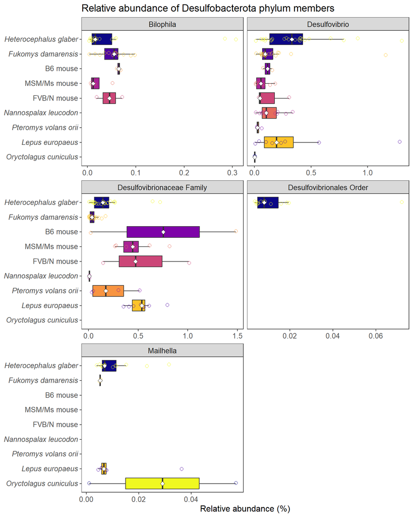

```r
print(desulfobacterota.plot +
  ggtitle(paste0("Relative abundance of Desulfobacterota phylum members"))+
  theme(plot.title = element_text(size = 14))
)
```

```r
# for (image.format in c("png","tiff")){
#   ggsave(paste0("./images/taxaboxplots/",
#                 paste(paste(format(Sys.time(),format="%Y%m%d"),
#                             format(Sys.time(),format = "%H_%M_%S"),sep = "_"),
#                       "Desulfobacterota phylum members-all-hosts",
#                       sep = "-"),".",image.format),
#          plot=desulfobacterota.plot,
#          width=8, height=10,units="in",
#          # width = 4000,height = 6000,
#          # width = 1200,
#          # units = "px",
#          dpi=300,device = image.format)
# }
```

## 2.16 Plot Treponema and other Spirochaetota.

```r
spirochaetota.plot<-ps.q.agg.genus.relab%>%
  mutate(class=factor(class,levels=custom.levels))%>%
  filter(Phylum=="Spirochaetota")%>%
  group_by(class,Genus)%>%
  ggplot(aes(x=factor(class,levels=rev(custom.levels)),
             y=RelativeAbundance,
             fill=factor(class)))+
  geom_boxplot(show.legend = FALSE,
               outliers = FALSE)+
  geom_jitter(aes(color=class),
              width = 0.1, # jitter spread
              shape = 1, # empty dots
              size=2,
              show.legend = FALSE)+
  scale_color_viridis_d(direction = -1,option="C")+
  facet_wrap(~Genus,scales = "free_x",
             ncol = 2)+
  theme_bw()+
  coord_flip()+
  labs(x="",
       y="Relative abundance (%)")+
  # VVV scale_x_discrete works on x axis but the final labels are on y because the coord_flip() flipped the plot.
  # So, we use rev() to address the flipping VVV
  scale_x_discrete(labels=rev(pretty.level.names), # new labels (named vector) on the axis
                   limits=rev(custom.levels) # limits adjust which levels (and in what order) are displayed
  )+ # rename boxplot labels
  scale_fill_viridis_d(option="C")+
  stat_summary(fun=median, geom="point", shape=23, size=2, color="black",fill="white",
               position = position_dodge2(width = 0.75,
                                          preserve = "single"))+
  # ggtitle(paste0("Relative abundance of Spirochaetota phylum members"))+
  mytheme+
  theme(axis.text.y = ggtext::element_markdown(size=10),
        axis.title.y = element_blank(),
        axis.title.x = element_text(size=12),
        axis.text.x = element_text(size=10),
        strip.text.x = element_text(size=10),
        plot.title = element_text(size = 8), # size of plot title
        plot.caption = element_text(size=8), # size of plot caption
        legend.position = "none")
```

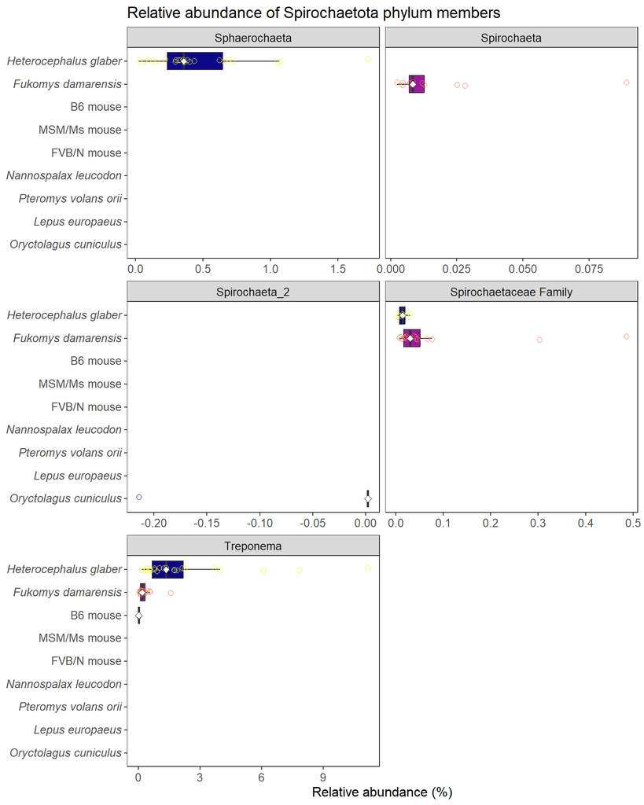

```r
print(spirochaetota.plot +
        ggtitle(paste0("Relative abundance of Spirochaetota phylum members"))+
        theme(plot.title = element_text(size = 14))
        )
```

```r
# for (image.format in c("png","tiff")){
#   ggsave(paste0("./images/taxaboxplots/",
#                 paste(paste(format(Sys.time(),format="%Y%m%d"),
#                             format(Sys.time(),format = "%H_%M_%S"),sep = "_"),
#                       "Spirochaetota phylum members-all-hosts",
#                       sep = "-"),".",image.format),
#          plot=spirochaetota.plot,
#          width=8, height=10,units="in",
#          # width = 4000,height = 6000,
#          # width = 1200,
#          # units = "px",
#          dpi=300,device = image.format)
# }
```

## 2.17 Analysis of naked mole-rat data ASVs.

Give ASVs shorter names: Genus, “ASV”, OTU, OTU number. For example, Allobaculum_ASV_22.

```r
nmr.asv.names<-ps.q.agg.relab.nmr%>%
  dplyr::select(OTU,Genus)%>%
  group_by(Genus)%>%
  distinct(OTU,.keep_all = T)%>%
  arrange(Genus,OTU)%>%
  mutate(row.index=row_number())%>%
  mutate(ASV_name=paste(Genus,row.index,sep="_ASV_"))
head(nmr.asv.names)
```

```
## # A tibble: 6 × 4
## # Groups:   Genus [3]
##   OTU                              Genus                      row.index ASV_name
##   <chr>                            <chr>                          <int> <chr>
## 1 1630c97bc99db59912c92545f184a2c8 ASF356                             1 ASF356_…
## 2 a5d3cef1b84bffa024ae0259ebbe7819 ASF356                             2 ASF356_…
## 3 fc224cd4a1ffe36b74bdec848bbba352 ASF356                             3 ASF356_…
## 4 3c23ed3c668cb5db5fe54e0920da4c77 Absconditabacteriales_(SR…         1 Abscond…
## 5 446609f70ba4143bd817f44c210a0a4c Acetanaerobacterium                1 Acetana…
## 6 ba4f8c14f1a6f625c90f05848475b43a Acetanaerobacterium                2 Acetana…
```

The new name becomes the OTU column. The old name becomes OTU_old_name column.

```r
ps.q.agg.relab.nmr<-ps.q.agg.relab.nmr%>%
  left_join(nmr.asv.names[,c("Genus","OTU","ASV_name")])%>%
  rename("OTU_old_name"="OTU",
         "OTU"="ASV_name")%>%
  relocate(OTU,.before = Sample)%>%
  relocate(OTU_old_name,.after = Genus)
```

### 2.17.1 How many ASVs are shared between two age groups?

First, find ASVs in young samples

```r
otu.young<-ps.q.agg.relab.nmr%>%
  filter(agegroup=="agegroup0_10",Abundance!=0)%>%
  distinct(OTU,.keep_all = T)%>%
  arrange(-MeanRelativeAbundanceAgegroup)%>%
  dplyr::select(OTU,agegroup,MeanRelativeAbundanceAgegroup, sdRelativeAbundance)
```

Next, find ASVs in old samples

```r
otu.old<-ps.q.agg.relab.nmr%>%
  filter(agegroup=="agegroup10_16",Abundance!=0)%>%
  distinct(OTU,.keep_all = T)%>%
  arrange(-MeanRelativeAbundanceAgegroup)%>%
  dplyr::select(OTU,agegroup,MeanRelativeAbundanceAgegroup)
```

1745 ASVs in young individuals:

```r
nrow(otu.young)
```

```
## [1] 1745
```

771 ASVs in old individuals:

```r
nrow(otu.old)
```

```
## [1] 771
```

668 shared ASVs:

```r
shared.otu<-intersect(otu.young$OTU,otu.old$OTU)
length(shared.otu)
```

```
## [1] 668
```

ASVs unique to old samples: 771 - 668 = 103

```r
length(otu.old$OTU)-length(shared.otu)
```

```
## [1] 103
```

### 2.17.2 Check 103 ASV only in old individuals.

```r
ps.q.agg.relab.nmr%>%
  group_by(OTU,agegroup)%>%
  mutate(n_samples=n_distinct(Sample))%>% # Find the number of old samples the ASV was found in
  filter(OTU %in% otu.old$OTU,
         !OTU %in% shared.otu)%>%
  filter(n_samples >= 3)%>%
  arrange(desc(MeanRelativeAbundanceAgegroup))%>%
  dplyr::select(OTU,MeanRelativeAbundance,MeanRelativeAbundanceAgegroup)
```

```
## # A tibble: 0 × 4
## # Groups:   OTU, agegroup [0]
## # ℹ 4 variables: agegroup <chr>, OTU <chr>, MeanRelativeAbundance <dbl>,
## #   MeanRelativeAbundanceAgegroup <dbl>
```

No ASVs with at least 3 samples! The 103 ASVs are individual-specific. Which genera do the 103 old-specific ASVs belong to?

```r
ps.q.agg.relab.nmr%>%
  filter(OTU %in% otu.old$OTU, # ASV in old but not shared vector
         !OTU %in% shared.otu)%>%
  dplyr::select(OTU,Family,Genus, MeanRelativeAbundance,MeanRelativeAbundanceAgegroup)%>%
  group_by(Family, Genus)%>%
  summarise(n=n_distinct(OTU))%>%
  arrange(desc(n))%>%
  head
```

```
## # A tibble: 6 × 3
## # Groups:   Family [6]
##   Family              Genus                      n
##   <chr>               <chr>                  <int>
## 1 Lachnospiraceae     Lachnospiraceae Family    14
## 2 Bacteria Kingdom    Bacteria Kingdom          11
## 3 Prevotellaceae      Prevotellaceae Family      7
## 4 Spirochaetaceae     Treponema                  5
## 5 Bacteroidales Order Bacteroidales Order        4
## 6 Muribaculaceae      Muribaculaceae             4
```

### 2.17.3 How much % do shared ASVs take on average?

```r
ps.q.agg.relab.nmr%>%
  # no separation by age
  filter(OTU%in%shared.otu)%>%
  group_by(Sample)%>%
  summarise(SumRelAbSharedASV=sum(RelativeAbundance))%>%
  summarise(MeanRelAbSharedASVTotal = mean(SumRelAbSharedASV),
            sdRelaAbSharedASVTotal = sd(SumRelAbSharedASV))
```

```
## # A tibble: 1 × 2
##   MeanRelAbSharedASVTotal sdRelaAbSharedASVTotal
##                     <dbl>                  <dbl>
## 1                    94.2                   10.9
```

On average 94.2% ± 10.9%

### 2.17.4 How much % do shared ASVs take in each age group?

```r
ps.q.agg.relab.nmr%>%
  filter(OTU%in%shared.otu)%>%
  # separation by age
  group_by(Sample,agegroup)%>%
  summarise(SumRelAbSharedASV=sum(RelativeAbundance))%>%
  arrange(agegroup)%>%
  group_by(agegroup)%>%
  summarise(MeanRelAbSharedASVTotalAge=mean(SumRelAbSharedASV),
            sdRelaAbSharedASVTotal = sd(SumRelAbSharedASV))
```

```
## # A tibble: 2 × 3
##   agegroup      MeanRelAbSharedASVTotalAge sdRelaAbSharedASVTotal
##   <chr>                              <dbl>                  <dbl>
## 1 agegroup0_10                        92.6                  12.2
## 2 agegroup10_16                       98.8                   1.77
```

Higher variation in young individuals

### 2.17.5 Are the shared ASVs enriched in certain genera?

First, get the table of shared ASVs and their genera.

```r
shared.otu.genera<-ps.q.agg.relab.nmr%>%
  filter(OTU%in%shared.otu)%>%
  # keep unique rows
  distinct(Genus,OTU)%>%
  group_by(Genus)
head(shared.otu.genera)
```

```
## # A tibble: 6 × 2
## # Groups:   Genus [5]
##   Genus                      OTU
##   <chr>                      <chr>
## 1 Eubacteriaceae Family      Eubacteriaceae Family_ASV_16
## 2 Allobaculum                Allobaculum_ASV_22
## 3 p-251-o5                   p-251-o5_ASV_2
## 4 Fibrobacter                Fibrobacter_ASV_2
## 5 Erysipelotrichaceae Family Erysipelotrichaceae Family_ASV_11
## 6 Fibrobacter                Fibrobacter_ASV_5
```

Calculate the ASVs in each genus with cumsum() and pull the most numerous genera.

```r
shared.otu.genera.cumsum<-shared.otu.genera%>%
  group_by(Genus)%>%
  # count rows (ASVs) for each genus; add as a column for sorting
  summarise(num_asvs =n_distinct(OTU))%>%
  # genera with the highest number of ASVs will be on top
  arrange(-num_asvs,Genus)%>%
  ungroup()%>%
  # cumulative sum shows how many ASVs the top genera take
  mutate(cum_sum=cumsum(num_asvs))

head(shared.otu.genera.cumsum)
```

```
## # A tibble: 6 × 3
##   Genus                   num_asvs cum_sum
##   <chr>                      <int>   <int>
## 1 Lachnospiraceae Family        55      55
## 2 Muribaculaceae                54     109
## 3 Treponema                     42     151
## 4 Bacteria Kingdom              30     181
## 5 Oscillospiraceae Family       22     203
## 6 Parabacteroides               22     225
```

Six genera account for 1/3 shared ASVs (225 out of 668 ASVS)

### 2.17.6 How many ASVs of the top 5 genera in shared.otu.genera are actually found there?

The five most common genera according to the shared.otu.genera dataframe are Lachnospiraceae Family (55 ASVs), Muribaculaceae (54 ASVS), Treponema (42 ASVs), Bacteria Kingdom (30 ASVs), and Oscillospiraceae Family (22 ASVs).

```r
ps.q.agg.relab.nmr%>%
  filter(Genus%in%c("Lachnospiraceae Family","Treponema",
                    "Muribaculaceae","Bacteria Kingdom",
                    "Oscillospiraceae Family"))%>%
  distinct(Genus,OTU)%>%
  mutate(is_shared=ifelse(OTU %in%shared.otu.genera$OTU, TRUE, FALSE))%>%
  group_by(Genus,is_shared)%>%
  summarise(n_asvs=n())%>%
  ungroup()%>%
  arrange(Genus,desc(is_shared))
```

```
## # A tibble: 10 × 3
##    Genus                   is_shared n_asvs
##    <chr>                   <lgl>      <int>
##  1 Bacteria Kingdom        TRUE          30
##  2 Bacteria Kingdom        FALSE        125
##  3 Lachnospiraceae Family  TRUE          55
##  4 Lachnospiraceae Family  FALSE        108
##  5 Muribaculaceae          TRUE          54
##  6 Muribaculaceae          FALSE         71
##  7 Oscillospiraceae Family TRUE          22
##  8 Oscillospiraceae Family FALSE         25
##  9 Treponema               TRUE          42
## 10 Treponema               FALSE         67
```

Lachnospiraceae Family: 55 ASVs are shared, 108 are not. Muribaculaceae: 54 are shared, 71 are not. Treponema: 42 ASVs are shared, 67 are not. Bacteria Kingdom: 30 ASVs are shared, 125 are not. Oscillospiraceae Family: 22 ASVs are shared, 25 are not.

### 2.17.7 What is the average relative abundance of each genus in the top 5 of shared.otu.genera?

TODO: This might be the correction of our paper

```r
ps.q.agg.relab.nmr%>%
  # the subset command relies on the fact that we sorted the shared.otu.genera
  # by the number of ASVs. So, the unique(shared.otu.genera$Genus)[1:5] has
  # genera with the highest number of ASVs
  filter(OTU%in%subset(shared.otu.genera,
                       Genus %in% unique(shared.otu.genera.cumsum$Genus)[1:5])$OTU)%>%
  group_by(Genus,Sample)%>%
  summarise(TotalGenus=sum(RelativeAbundance))%>%
  group_by(Genus)%>%
  summarise(MeanRelAbGenus = mean(TotalGenus),
            sdRelAbGenus = sd(TotalGenus))%>%
  arrange(-MeanRelAbGenus)
```

```
## # A tibble: 5 × 3
##   Genus                   MeanRelAbGenus sdRelAbGenus
##   <chr>                            <dbl>        <dbl>
## 1 Muribaculaceae                  10.6          3.17
## 2 Lachnospiraceae Family           1.93         1.91
## 3 Treponema                        1.91         2.26
## 4 Oscillospiraceae Family          0.426        0.237
## 5 Bacteria Kingdom                 0.282        0.201
```

## 2.18 Plot ASVs in NMR.

Setup sample levels for NMR for barplots.

```r
sample.levels<-custom.md.ages%>%
  ungroup()%>%
  dplyr::select(Sample,age)%>%
  arrange(age)%>%
  distinct()%>%
  mutate(NewSample=paste0(Sample," (",age,")"))%>%
  mutate(Sample=factor(Sample,levels=Sample),
         NewSample=factor(NewSample,levels=NewSample))
```

Bar plot of abundances: high variability

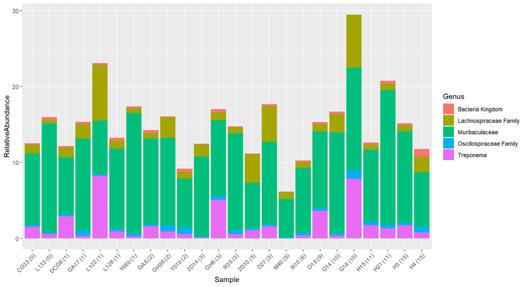

```r
ps.q.agg.relab.nmr%>%
  left_join(custom.md.ages)%>%
  mutate(Sample=factor(Sample,levels=sample.levels$Sample),
         NewSample=paste0(Sample," (",age,")"),
         NewSample=factor(NewSample,levels=sample.levels$NewSample))%>%
  filter(OTU%in%subset(shared.otu.genera,
                       Genus%in%unique(shared.otu.genera.cumsum$Genus)[1:5])$OTU)%>%
  ggplot(aes(x=NewSample,y=RelativeAbundance,fill=Genus))+
  geom_bar(stat="identity")+
  labs(x = "Sample")+
  theme(axis.text.x = element_text(angle = 45, hjust=1))
```

Find the most abundant ASVs on average.

```r
top10.asv.average<-ps.q.agg.relab.nmr%>%
  filter(OTU%in%shared.otu)%>%
  group_by(OTU)%>%
  distinct(OTU,.keep_all = T)%>%
  arrange(-MeanRelativeAbundance)%>%
  dplyr::select(Genus,OTU,MeanRelativeAbundance)%>%
  head(n=10)
top10.asv.average%>%
  arrange(Genus)
```

```
## # A tibble: 10 × 3
## # Groups:   OTU [10]
##    Genus                      OTU                          MeanRelativeAbundance
##    <chr>                      <chr>                                        <dbl>
##  1 Allobaculum                Allobaculum_ASV_22                            3.28
##  2 Erysipelotrichaceae Family Erysipelotrichaceae Family_…                  4.15
##  3 Eubacteriaceae Family      Eubacteriaceae Family_ASV_16                  1.74
##  4 Eubacteriaceae Family      Eubacteriaceae Family_ASV_4                   1.67
##  5 Fibrobacter                Fibrobacter_ASV_2                             4.16
##  6 Prevotella                 Prevotella_ASV_7                              2.35
##  7 Prevotellaceae Family      Prevotellaceae Family_ASV_31                  2.48
##  8 Prevotellaceae_UCG-003     Prevotellaceae_UCG-003_ASV_…                  2.68
##  9 Prevotellaceae_UCG-003     Prevotellaceae_UCG-003_ASV_2                  1.53
## 10 p-251-o5                   p-251-o5_ASV_2                                6.31
```

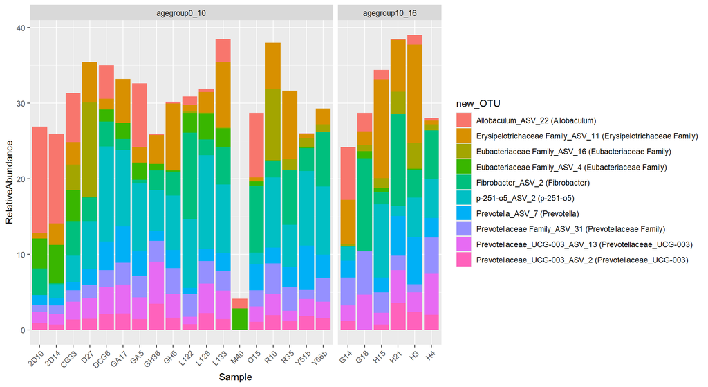

```r
ps.q.agg.relab.nmr%>%
  filter(OTU%in%top10.asv.average$OTU)%>%
  mutate(new_OTU=paste0(OTU," (",Genus,")"))%>%
  ggplot(aes(x=Sample,y=RelativeAbundance,fill=new_OTU))+
  geom_bar(stat="identity")+
  facet_grid(~agegroup,
             scales="free",
             space = "free")+
  labs(x = "Sample")+
  theme(axis.text.x = element_text(angle = 45, hjust=1))
```

```r
### 17.2 Most abundant shared ASVs in each age group. ####
```

### 2.18.2 Most abundant shared ASVs in each age group.

```r
top.shared.asvs.by_age<-ps.q.agg.relab.nmr%>%
  filter(OTU%in%shared.otu)%>%
  group_by(OTU,agegroup)%>%
  distinct(OTU,.keep_all = T)%>%
  arrange(-MeanRelativeAbundance)%>%
  dplyr::select(Genus,OTU,agegroup,MeanRelativeAbundance,MeanRelativeAbundanceAgegroup)%>%
  ungroup()
head(top.shared.asvs.by_age)
```

```
## # A tibble: 6 × 5
##   Genus              OTU   agegroup MeanRelativeAbundance MeanRelativeAbundanc…¹
##   <chr>              <chr> <chr>                    <dbl>                  <dbl>
## 1 p-251-o5           p-25… agegrou…                  6.31                   6.66
## 2 p-251-o5           p-25… agegrou…                  6.31                   4.02
## 3 Fibrobacter        Fibr… agegrou…                  4.16                   3.90
## 4 Fibrobacter        Fibr… agegrou…                  4.16                   5.84
## 5 Erysipelotrichace… Erys… agegrou…                  4.15                   3.73
## 6 Erysipelotrichace… Erys… agegrou…                  4.15                   6.82
## # ℹ abbreviated name: ¹MeanRelativeAbundanceAgegroup
```

```r
top10.shared.asv.young<-top.shared.asvs.by_age%>%
  filter(agegroup=="agegroup0_10")%>%
  arrange(-MeanRelativeAbundanceAgegroup)%>%
  head(n=10)

top10.shared.asv.old<-top.shared.asvs.by_age%>%
  filter(agegroup=="agegroup10_16")%>%
  arrange(-MeanRelativeAbundanceAgegroup)%>%
  head(n=10)
```

Are top 10 most abundant ASVs same in two age groups?

```r
setequal(top10.shared.asv.young$OTU,top10.shared.asv.old$OTU)
```

```
## [1] FALSE
```

No. How many are common?

```r
intersect(top10.shared.asv.young$OTU,top10.shared.asv.old$OTU)
```

```
## [1] "p-251-o5_ASV_2"                    "Fibrobacter_ASV_2"
## [3] "Erysipelotrichaceae Family_ASV_11" "Allobaculum_ASV_22"
## [5] "Prevotellaceae_UCG-003_ASV_13"     "Prevotellaceae Family_ASV_31"
## [7] "Prevotella_ASV_7"
```

Seven ASVs

Union of the top 10 ASVs in each of the two age groups.

```r
top10.shared.asv.union<-sort(union(top10.shared.asv.young$OTU,top10.shared.asv.old$OTU))
```

Make the names shorter for the barplot

```r
top10.shared.asv.union<-top10.shared.asv.union%>%
  as_tibble()%>%
  rename("OTU"="value")%>%
  mutate(new_OTU = OTU,
         new_OTU = gsub("Allobaculum_", "Allob. ",new_OTU),
         new_OTU = gsub("Erysipelotrichaceae Family_", "Erysip. F. ",new_OTU),
         new_OTU = gsub("Eubacteriaceae Family_", "Eubac. F. ",new_OTU),
         new_OTU = gsub("Fibrobacter_", "Fibrob. ",new_OTU),
         new_OTU = gsub("Muribaculaceae_", "Murib. ",new_OTU),
         new_OTU = gsub("Paludibacteraceae Family_", "Palud. F. ",new_OTU),
         new_OTU = gsub("o5_ASV", "o5 ASV",new_OTU),
         new_OTU = gsub("Prevotella_", "Prev. ",new_OTU),
         new_OTU = gsub("Prevotellaceae Family_", "Prevot. F. ",new_OTU),
         new_OTU = gsub("Prevotellaceae_UCG", "Prevot. UCG",new_OTU),
         new_OTU = gsub("UCG-001_", "UCG-001 ",new_OTU),
         new_OTU = gsub("UCG-003_", "UCG-003 ",new_OTU)
         )
```

Prepare a custom fill with Polychrome package

```r
set.seed(1)
otu.fill<-createPalette(nrow(top10.shared.asv.union),
                        seedcolors = c("#FF0000", "#00FF00", "#0000FF"),
                        range=c(30, 80))
names(otu.fill)<-top10.shared.asv.union$new_OTU
```

### 2.18.3 Barplot of the most abundant ASVs.

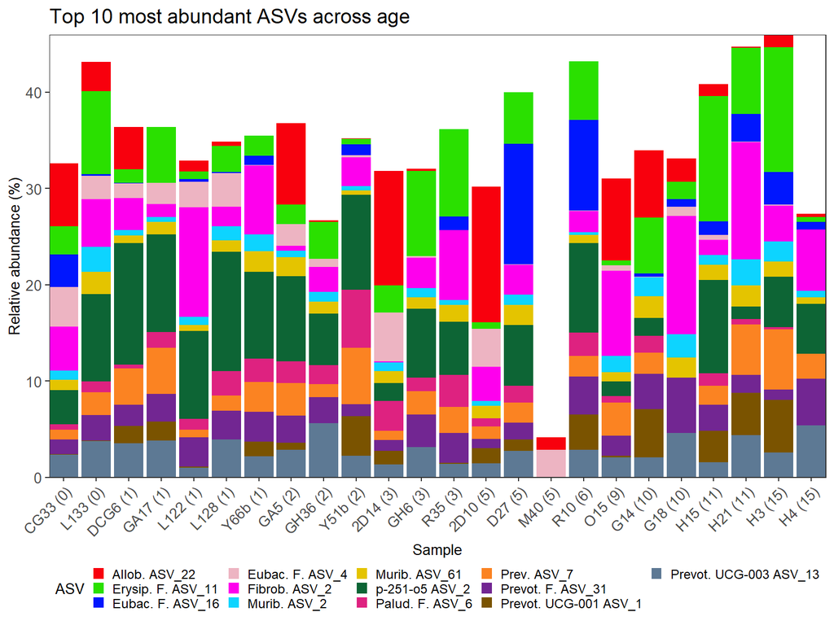

```r
top10.shared.asv.plot<-ps.q.agg.relab.nmr%>%
  left_join(custom.md.ages)%>%
  filter(OTU%in%top10.shared.asv.union$OTU) %>%
  # mutate(new_OTU=paste0(OTU," (",Genus,")"))%>%
  left_join(top10.shared.asv.union)%>%
  mutate(Sample=factor(Sample,levels=sample.levels$Sample),
         NewSample=paste0(Sample," (",age,")"),
         NewSample=factor(NewSample,levels=sample.levels$NewSample))%>%

  ggplot(aes(x=NewSample,y=RelativeAbundance,fill=new_OTU))+
  geom_bar(stat="identity")+
  scale_fill_manual(labels=names(otu.fill),
                    values=otu.fill)+
  theme_bw()+
  coord_cartesian(expand = FALSE)+
  labs(x="Sample",
       y="Relative abundance (%)",
       # title="Top 10 most abundant ASVs across age",
       fill="ASV"
       )+
  mytheme +
  theme(
    legend.title = element_text(size=10),
    legend.text = element_text(size=9),
    legend.key.size = unit(0.3, 'cm'), #change legend key size
    legend.key.spacing.y = unit(0.1, "lines"), # distant between key text
    legend.box.spacing = unit(0.1,"lines"), # space between the plot and the legend box
    axis.title.y = element_text(size = 10),
    axis.text.x = element_text(angle=45,size=10,hjust=1),# rotate
    strip.text.x = ggtext::element_markdown(size=10),
    panel.spacing = unit(0.8, "cm"), # increase distance between facets
    plot.title = element_text(size = 8), # size of plot title
    plot.caption = element_text(size=8), # size of plot caption
    legend.position = "bottom")
print(top10.shared.asv.plot+
  ggtitle("Top 10 most abundant ASVs across age")+
  theme(plot.title = element_text(size = 14)))
```

```r
# for(image.format in image.formats){
#   ggsave(file.path("./images/barplots",
#                  paste0(paste(format(Sys.time(),format="%Y%m%d"),
#                              format(Sys.time(),format = "%H_%M_%S"),sep = "_"),
#                        "-top10-asv", ".",image.format)),
#        plot=top10.shared.asv.plot,
#        width=8, height=6,units="in",
#        # width = 5000,height = 3500,
#        # units = "px",
#        dpi=300,device = image.format)
# }
```

### 2.18.4 M40 sample is very different.

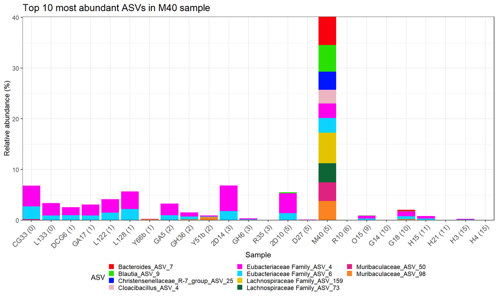

```r
m40.asvs<-ps.q.agg.relab.nmr%>%
  filter(Sample=="M40")%>%
  dplyr::select(OTU,Genus,RelativeAbundance,MeanRelativeAbundance,
         MeanRelativeAbundanceAgegroup)%>%
  arrange(-RelativeAbundance)%>%
  head(n=10)

set.seed(1)
m40.otu.fill<-createPalette(length(m40.asvs$OTU),
                            seedcolors = c("#FF0000", "#00FF00", "#0000FF"),
                            range=c(30, 80))
names(m40.otu.fill)<-sort(m40.asvs$OTU)
m40.asv.plot<-ps.q.agg.relab.nmr%>%
  left_join(custom.md.ages)%>%
  mutate(Sample=factor(Sample,levels=sample.levels$Sample),
         NewSample=paste0(Sample," (",age,")"),
         NewSample=factor(NewSample,levels=sample.levels$NewSample))%>%
  filter(OTU%in%m40.asvs$OTU)%>%
  # mutate(new_OTU=paste0(OTU," (",Genus,")"))%>%
  ggplot(aes(x=NewSample,y=RelativeAbundance,fill=OTU))+
  geom_bar(stat="identity")+
  scale_fill_manual(labels=names(m40.otu.fill),
                    values=m40.otu.fill)+
  theme_bw()+
  coord_cartesian(expand = FALSE)+
  labs(x="Sample",
       y="Relative abundance (%)",
       fill="ASV",
       title="Top 10 most abundant ASVs in M40 sample")+
  guides(fill = guide_legend(ncol = 3))+
  theme(
    legend.title = element_text(size=10),
    legend.text = element_text(size=9),
    legend.key.size = unit(0.3, 'cm'), #change legend key size
    legend.key.spacing.y = unit(0.1, "lines"), # distant between key text
    legend.box.spacing = unit(0.1,"lines"), # space between the plot and the legend box
    axis.title.y = element_text(size = 10),
    axis.text.x = element_text(angle=45,size=10,hjust=1),# rotate
    strip.text.x = ggtext::element_markdown(size=10),
    panel.spacing = unit(0.8, "cm"), # increase distance between facets
    plot.title = element_text(size = 14), # size of plot title
    plot.caption = element_text(size=8), # size of plot caption
    legend.position = "bottom")
print(m40.asv.plot)
```

```r
# ggsave(file.path("./images/barplots",
#                  paste(paste(format(Sys.time(),format="%Y%m%d"),
#                              format(Sys.time(),format = "%H_%M_%S"),sep = "_"),
#                        "top10-asv-m40.png")),
#        plot=last_plot(),
#        width=8, height=6,units="in",
#        units = "px",dpi=300,device = "png")
```

## 2.19 Import the rarefied dataframe

```r
# Between NMR (ASV level)
# ps.q.df.preprocessed.date_time<-"20240524_13_58_11"
ps.q.df.preprocessed.date_time<-"20260211_17_14_21"
ps.q.df.preprocessed<-read.table(
  file.path("./output/rtables/",authorname,paste0(
    paste(
      ps.q.df.preprocessed.date_time,
      paste0("ps.q.df.","rare"),"nonfiltered","OTU",
      paste("NMR",collapse = '-'),sep = "-"),
    ".tsv")),
  header = T)
```

Or between species (Genus level)

```r
ps.q.df.preprocessed<-read.table(
  file.path("./output/rtables/",authorname,paste0(
    paste(
      # "20240426_22_00_04",
      "20260211_17_14_18",
      paste0("ps.q.df.","rare"),"nonfiltered","Genus",
      paste(custom.levels,collapse = '-'),sep = "-"),
    ".tsv")),
  header = T)
```

### 2.19.1 Let’s find which major ASVs are specific to one age group

```r
young.ps.q.agg.relab.nmr<-ps.q.agg.relab.nmr%>%
  filter(agegroup=="agegroup0_10")%>%
  arrange(-MeanRelativeAbundanceAgegroup)

old.ps.q.agg.relab.nmr<-ps.q.agg.relab.nmr%>%
  filter(agegroup=="agegroup10_16")%>%
  arrange(-MeanRelativeAbundanceAgegroup)

length(unique(young.ps.q.agg.relab.nmr$OTU))
```

```
## [1] 1745
```

```r
length(unique(old.ps.q.agg.relab.nmr$OTU))
```

```
## [1] 771
```

### 2.19.2 How many genera are shared between two age groups

```r
genera.young<-ps.q.agg.genus.relab.nmr%>%
  # add_agegroup_to_tax_df(.,"Genus",custom.md.ages)%>%
  # left_join(custom.md.ages)%>%
  filter(agegroup=="agegroup0_10",Abundance!=0)%>%
  distinct(Genus,.keep_all = T)%>%
  arrange(-MeanRelativeAbundanceAgegroup)
genera.old<-ps.q.agg.genus.relab.nmr%>%
  # add_agegroup_to_tax_df(.,"Genus",custom.md.ages)%>%
  # left_join(custom.md.ages)%>%
  filter(agegroup=="agegroup10_16",Abundance!=0)%>%
  distinct(Genus,.keep_all = T)%>%
  arrange(-MeanRelativeAbundanceAgegroup)

length(genera.young$Genus)
```

```
## [1] 229
```

```r
length(genera.old$Genus)
```

```
## [1] 157
```

```r
shared.genera<-intersect(genera.young$Genus,genera.old$Genus)
length(shared.genera)
```

```
## [1] 155
```

```r
unique.to_old.genera<-setdiff(genera.old$Genus,genera.young$Genus)
ps.q.agg.genus.relab.nmr%>%
  # add_agegroup_to_tax_df(.,"Genus",custom.md.ages)%>%
  filter(Genus %in% unique.to_old.genera)%>%
  dplyr::select(Sample,Family,Genus,MeanRelativeAbundance,MeanRelativeAbundanceAgegroup )
```

```
## # A tibble: 3 × 5
##   Sample Family          Genus      MeanRelativeAbundance MeanRelativeAbundanc…¹
##   <chr>  <chr>           <chr>                      <dbl>                  <dbl>
## 1 G18    Lachnospiraceae Roseburia               0.00141                 0.0106
## 2 G14    Veillonellaceae Veillonel…              0.000434                0.00326
## 3 H15    Veillonellaceae Veillonel…              0.000434                0.00326
## # ℹ abbreviated name: ¹MeanRelativeAbundanceAgegroup
```

```r
# How much % do common genera take in each age group on average?
ps.q.agg.relab.nmr%>%
  filter(Genus%in%shared.genera)%>%
  group_by(Sample,agegroup)%>%
  summarise(SumRelAbCommonASV=sum(RelativeAbundance))%>%
  arrange(agegroup)%>%
  group_by(agegroup)%>%
  summarise(MeanRelAbCommonASVTotalAge=mean(SumRelAbCommonASV))
```

```
## # A tibble: 2 × 2
##   agegroup      MeanRelAbCommonASVTotalAge
##   <chr>                              <dbl>
## 1 agegroup0_10                        99.6
## 2 agegroup10_16                      100.0
```

```r
rm(list = ls(all=TRUE))
gc()
```

```
##           used  (Mb) gc trigger  (Mb) max used  (Mb)
## Ncells 2968951 158.6    4379735 234.0  4379735 234.0
## Vcells 5240330  40.0   21892305 167.1 21324459 162.7
```

# 3 Compare our data with results from the original papers.

## 3.1 Introduction

In this script, we will compare the results from original papers on DMR, flying squirrels (PVO), and hares and rabbits with our re-analysis. We will also create a bar plot of dominant families in our data vs the original wild NMR data.

## 3.2 Load necessary libraries and scripts.

```r
# install.packages(c("tidyverse","ggtext"))
# install.packages(c("tidyverse"))
# if(!requireNamespace("BiocManager")){
#   install.packages("BiocManager")
# }
# BiocManager::install("phyloseq")
library(tidyverse)
```

```
## ✖ purrr::%||%()   masks base::%||%()
```

```r
library(phyloseq)
library(ggtext)
source("./code/r-scripts/get_dominant_taxa_in_host.R")
source("./code/r-scripts/get_n_uniq_taxa_per_host.R")
```

## 3.3 Specifying parameters and directory/file names.

Name of the folder with QIIME2 output:

```r
authorname<-"pooled"
```

Name of the folder with QIIME2 output:

```r
rdafiles.directory<-"./output/rdafiles"
```

Truncation level that we chose in QIIME2:

```r
truncationlvl<-"234"
```

Single reads or paired reads: decided in QIIME2.

```r
read.end.type<-"single"
```

## 3.4 Import datasets.

Import datasets as rds files.

```r
ps.q.agg<-readRDS(file=file.path(
  rdafiles.directory,
  paste(
    "20260211_17_01_07",
        "phyloseq-qiime",authorname,"OTU",read.end.type,
        truncationlvl,"table.rds",sep = "-")))
ps.q.agg.genus<-readRDS(file=file.path(
  rdafiles.directory,
  paste("20260211_17_01_10",
        "phyloseq-qiime",authorname,"Genus",read.end.type,
        truncationlvl,"table.rds",sep = "-")))

ps.q.agg.family<-readRDS(file=file.path(
  rdafiles.directory,
  paste("20260211_17_01_09-phyloseq-qiime",authorname,"Family",read.end.type,
        truncationlvl,"table.rds",sep = "-")))
ps.q.agg.phylum<-readRDS(file=file.path(
  rdafiles.directory,
  paste("20260211_17_01_08-phyloseq-qiime",authorname,"Phylum",read.end.type,
        truncationlvl,"table.rds",sep = "-")))
```

Import metadata:

```r
custom.md<-readRDS(file.path(rdafiles.directory,"custom.md.rds"))
```

## 3.5 Re-analysis of the DMR dataset.

Data was taken from github of the original study.

```r
dmr.asvs <- read_tsv("./data/dmr-original-data/asv_table_FreezedriedVsFrozen.tsv",
                     col_types =cols(asv = col_character(),
                                     sample = col_character(),
                                     count = col_double(),
                                     relab = col_double() ))
dmr.metadata <- read_csv("./data/dmr-original-data/FDvsFrozenMetadata.csv",
                         col_types = cols(.default = col_character(),
                                          SampleDate = col_date(format = ""),
                                          SampleOrder = col_number())) %>%
  suppressWarnings()
```

Rename SampleNumber

```r
dmr.metadata  <- dmr.metadata %>%
  dplyr::rename(OldSampleNumber = SampleNumber,
                SampleNumber = NewSampleNumber )
```

Make a character of the sample number

```r
dmr.metadata <- dmr.metadata %>%
  mutate(Asample = paste("A", sample, sep= "_"))
dmr.taxonomy <- read_tsv("./data/dmr-original-data/taxonomy_FreezedriedVsFrozen.tsv",
                         col_types =  cols(asv = col_character(),
                                           kingdom = col_character(),
                                           phylum = col_character(),
                                           class = col_character(),
                                           order = col_character(),
                                           family = col_character(),
                                           genus = col_character(),
                                           species = col_character()))
```

Rename unclassified taxa:

```r
dmr.taxonomy  <- dmr.taxonomy %>%
  mutate(
    phylum = ifelse(is.na(phylum), sprintf("%s unclassified", kingdom),
                    phylum),
    class = ifelse(is.na(class), sprintf("%s unclassified",
                                         str_remove(phylum, "unclassified")),
                   class),
    order = ifelse(is.na(order), sprintf("%s unclassified",
                                         str_remove(class, "unclassified")),
                   order),
    family = ifelse(is.na(family), sprintf("%s unclassified",
                                           str_remove(order, "unclassified")),
                    family),
    genus = ifelse(is.na(genus), sprintf("%s unclassified",
                                         str_remove(family, "unclassified")),
                   genus),
    species = ifelse(is.na(species), sprintf("%s unclassified",
                                             str_remove(genus, "unclassified")),
                     species))
```

### 3.5.1 Filter to keep only frozen samples.

Also, join the asv data with taxonomy table.

```r
dmr.asv.tax.df<-dmr.asvs%>%
  left_join(dmr.taxonomy)%>%
  rename("Sample"=sample)%>%
  rename("Abundance"=count)%>%
  rename("Kingdom"=kingdom)%>%
  rename("Phylum"=phylum)%>%
  rename("Class"=class)%>%
  rename("Order"=order)%>%
  rename("Family"=family)%>%
  rename("Genus"=genus)%>%
  rename("Species"=species)%>%
  mutate(class="DMR")
dmr.asv.tax.df.frozen<-dmr.asv.tax.df%>%
  filter(Sample%in%subset(dmr.metadata,Treatment=="Frozen")$sample)
dmr.taxonomy.frozen<-dmr.taxonomy%>%
  filter(asv%in%dmr.asv.tax.df.frozen$asv)

## ====== Results after Table 1: ====== ####
```

### 3.5.2 Compare numbers of phyla, families, genera, and asv between datasets.

Phyla in original frozen (19), original total (19), and my data (21).

```r
get_n_uniq_taxa_per_host(tax.df = dmr.asv.tax.df.frozen,tax.rank = "Phylum")
```

```
## # A tibble: 1 × 2
##   class     n
##   <chr> <int>
## 1 DMR      19
```

```r
get_n_uniq_taxa_per_host(tax.df = dmr.asv.tax.df,tax.rank = "Phylum")
```

```
## # A tibble: 1 × 2
##   class     n
##   <chr> <int>
## 1 DMR      19
```

```r
get_n_uniq_taxa_per_host(tax.df = subset(ps.q.agg.phylum, class=="DMR"),
                         tax.rank = "Phylum")
```

```
## # A tibble: 1 × 2
##   class     n
##   <fct> <int>
## 1 DMR      21
```

Families in original frozen (97), original total (117), and my data (156).

```r
get_n_uniq_taxa_per_host(tax.df = dmr.asv.tax.df.frozen,tax.rank = "Family")
```

```
## # A tibble: 1 × 2
##   class     n
##   <chr> <int>
## 1 DMR      97
```

```r
get_n_uniq_taxa_per_host(tax.df = dmr.asv.tax.df,tax.rank = "Family")
```

```
## # A tibble: 1 × 2
##   class     n
##   <chr> <int>
## 1 DMR     117
```

```r
get_n_uniq_taxa_per_host(tax.df = subset(ps.q.agg.family, class=="DMR"),
                         tax.rank = "Family")
```

```
## # A tibble: 1 × 2
##   class     n
##   <fct> <int>
## 1 DMR     156
```

Genera in original frozen (165), original total (210), and my data (257).

```r
get_n_uniq_taxa_per_host(tax.df = dmr.asv.tax.df.frozen,tax.rank = "Genus")
```

```
## # A tibble: 1 × 2
##   class     n
##   <chr> <int>
## 1 DMR     165
```

```r
get_n_uniq_taxa_per_host(tax.df = dmr.asv.tax.df,tax.rank = "Genus")
```

```
## # A tibble: 1 × 2
##   class     n
##   <chr> <int>
## 1 DMR     210
```

```r
get_n_uniq_taxa_per_host(tax.df = subset(ps.q.agg.genus, class=="DMR"),
                         tax.rank = "Genus")
```

```
## # A tibble: 1 × 2
##   class     n
##   <fct> <int>
## 1 DMR     257
```

ASVs in original frozen (1368), original total (1768), and my data (1826).

```r
get_n_uniq_taxa_per_host(tax.df = dmr.asv.tax.df.frozen,tax.rank = "asv")
```

```
## # A tibble: 1 × 2
##   class     n
##   <chr> <int>
## 1 DMR    1368
```

```r
get_n_uniq_taxa_per_host(tax.df = dmr.asv.tax.df,tax.rank = "asv")
```

```
## # A tibble: 1 × 2
##   class     n
##   <chr> <int>
## 1 DMR    1768
```

```r
get_n_uniq_taxa_per_host(tax.df = subset(ps.q.agg, class=="DMR"),
                         tax.rank = "OTU")
```

```
## # A tibble: 1 × 2
##   class     n
##   <fct> <int>
## 1 DMR    1826
```

### 3.5.3 Classified and unclassified genera.

41 unclassified genera in frozen samples:

```r
dmr.taxonomy.frozen[grepl("uncultured|unclassified",dmr.taxonomy.frozen$genus),]%>%
  distinct(genus,.keep_all = T)%>%
  select(genus)%>%
  tally
```

```
## # A tibble: 1 × 1
##       n
##   <int>
## 1    41
```

51 unclassified genera in all samples:

```r
dmr.taxonomy[grepl("uncultured|unclassified",dmr.taxonomy$genus),]%>%
  distinct(genus,.keep_all = T)%>%
  select(genus)%>%
  tally
```

```
## # A tibble: 1 × 1
##       n
##   <int>
## 1    51
```

124 classified genera in frozen samples:

```r
dmr.taxonomy.frozen[!grepl("uncultured|unclassified",dmr.taxonomy.frozen$genus),]%>%
  distinct(genus,.keep_all = T)%>%
  select(genus)%>%
  tally
```

```
## # A tibble: 1 × 1
##       n
##   <int>
## 1   124
```

159 classified genera in all samples:

```r
dmr.taxonomy[!grepl("uncultured|unclassified",dmr.taxonomy$genus),]%>%
  distinct(genus,.keep_all = T)%>%
  select(genus)%>%
  tally
```

```
## # A tibble: 1 × 1
##       n
##   <int>
## 1   159
```

### 3.5.4 How many total reads in frozen data.

1,853,295 reads in frozen data:

```r
sum(dmr.asv.tax.df.frozen$Abundance)
```

```
## [1] 1853295
```

3,626,584 reads in total:

```r
sum(dmr.asv.tax.df$Abundance)
```

```
## [1] 3626584
```

### 3.5.5 Library size in frozen data.

Mean 92665, SD 44202

```r
dmr.asv.tax.df.frozen%>%
  group_by(Sample)%>%
  summarise(LibrarySize=sum(Abundance))%>%
  summarise(MeanLibrarySize=mean(LibrarySize),
            SDLibrarySize=sd(LibrarySize))
```

```
## # A tibble: 1 × 2
##   MeanLibrarySize SDLibrarySize
##             <dbl>         <dbl>
## 1          92665.        44202.
```

### 3.5.6 Dominant phyla in the frozen dataset vs my data (Results).

Original data:

```r
dmr.asv.tax.df.frozen %>%
  group_by(Sample, Phylum) %>%
  summarise(sample_relab = sum(relab)*100) %>%
  group_by(Phylum) %>%
  summarise(MeanRelativeAbundance =mean(sample_relab),
            MinRelativeAbundance= min(sample_relab),
            MaxRelativeAbundance= max(sample_relab))%>%
  arrange(desc(MeanRelativeAbundance)) %>%
  mutate(MeanRelativeAbundance = round(MeanRelativeAbundance,digits = 5),
         MinRelativeAbundance = round(MinRelativeAbundance,digits = 5),
         MaxRelativeAbundance = round(MaxRelativeAbundance,digits = 5))
```

```
## # A tibble: 19 × 4
##    Phylum        MeanRelativeAbundance MinRelativeAbundance MaxRelativeAbundance
##    <chr>                         <dbl>                <dbl>                <dbl>
##  1 Bacteroidetes              68.9                 31.4                 86.7
##  2 Firmicutes                 20.3                  5.20                47.8
##  3 Proteobacter…               4.07                 0.319               60.9
##  4 Cyanobacteria               3.37                 0.121                6.93
##  5 Actinobacter…               2.46                 0.788                8.82
##  6 Spirochaetes                0.406                0.0339               1.90
##  7 Patescibacte…               0.272                0.00997              0.755
##  8 Synergistetes               0.137                0.0177               0.260
##  9 Lentisphaerae               0.102                0.00207              0.559
## 10 Bacteria unc…               0.0621               0.0031               0.192
## 11 Tenericutes                 0.0124               0.00374              0.0201
## 12 Deferribacte…               0.00957              0.00171              0.0300
## 13 Verrucomicro…               0.00816              0.00109              0.0310
## 14 Euryarchaeota               0.0062               0.0062               0.0062
## 15 Chloroflexi                 0.00378              0.00378              0.00378
## 16 Gemmatimonad…               0.00303              0.00303              0.00303
## 17 Chlamydiae                  0.00292              0.00292              0.00292
## 18 Fusobacteria                0.0029               0.0029               0.0029
## 19 Planctomycet…               0.00179              0.00151              0.00207
```

My data:

```r
ps.q.agg.phylum%>%
  filter(class=="DMR")%>%
  group_by(Phylum) %>%
  summarise(MeanRelativeAbundance =mean(RelativeAbundance ),
            MinRelativeAbundance= min(RelativeAbundance ),
            MaxRelativeAbundance= max(RelativeAbundance ))%>%
  arrange(desc(MeanRelativeAbundance)) %>%
  mutate(MeanRelativeAbundance = round(MeanRelativeAbundance,digits = 5),
         MinRelativeAbundance = round(MinRelativeAbundance,digits = 5),
         MaxRelativeAbundance = round(MaxRelativeAbundance,digits = 5))%>%
  print(n = 21)
```

```
## # A tibble: 21 × 4
##    Phylum        MeanRelativeAbundance MinRelativeAbundance MaxRelativeAbundance
##    <chr>                         <dbl>                <dbl>                <dbl>
##  1 Bacteroidota               69.7                 41.8                 90.4
##  2 Firmicutes                 22.5                  4.01                40.4
##  3 Cyanobacteria               2.43                 0.0855               5.19
##  4 Proteobacter…               2.22                 0.0299              40.0
##  5 Actinobacter…               1.68                 0.734                5.32
##  6 Rs-K70_termi…               0.374                0.0950               1.38
##  7 Spirochaetota               0.347                0.0315               2.13
##  8 Desulfobacte…               0.252                0.0386               1.24
##  9 Patescibacte…               0.157                0.00726              0.478
## 10 Bacteria Kin…               0.130                0.0230               0.394
## 11 Synergistota                0.0947               0.0153               0.166
## 12 Verrucomicro…               0.0649               0.00178              0.387
## 13 Deferribacte…               0.00717              0.00138              0.0194
## 14 Gemmatimonad…               0.00595              0.00595              0.00595
## 15 Chloroflexi                 0.00494              0.00093              0.0109
## 16 Acidobacteri…               0.00285              0.00093              0.00793
## 17 Elusimicrobi…               0.00226              0.00226              0.00226
## 18 Fusobacterio…               0.00178              0.00178              0.00178
## 19 Methylomirab…               0.00149              0.00149              0.00149
## 20 Myxococcota                 0.00138              0.00062              0.00181
## 21 Planctomycet…               0.00126              0.00062              0.00198
```

## 3.6 Re-analysis of the PVO dataset.

We don’t have the original data, so I’m showing my results. The comparison is provided in the manuscript.

### 3.6.1 Dominant phyla (Results).

```r
ps.q.agg.phylum%>%
  filter(class=="pvo")%>%
  ungroup()%>%
  group_by(Phylum)%>%
  summarise(MeanRelativeAbundance = round(mean(RelativeAbundance), digits = 5),
            MinRelativeAbundance= round(min(RelativeAbundance), digits = 5),
            MaxRelativeAbundance= round(max(RelativeAbundance), digits = 5),
            sd_relab = round(sd(RelativeAbundance), digits =5))%>%
  arrange(desc(MeanRelativeAbundance))
```

```
## # A tibble: 13 × 5
##    Phylum        MeanRelativeAbundance MinRelativeAbundance MaxRelativeAbundance
##    <chr>                         <dbl>                <dbl>                <dbl>
##  1 Firmicutes                 62.7                 27.8                 75.4
##  2 Bacteroidota               20.6                 15.0                 31.4
##  3 Proteobacter…               5.69                 0.357               44.9
##  4 Bacteria Kin…               5.50                 1.69                 9.84
##  5 Actinobacter…               3.44                 0.848                7.95
##  6 Verrucomicro…               0.965                0.00436              5.59
##  7 Cyanobacteria               0.870                0.341                1.73
##  8 Elusimicrobi…               0.217                0.0155               0.749
##  9 Desulfobacte…               0.207                0.0286               0.515
## 10 Campylobacte…               0.0335               0.0152               0.0568
## 11 Gemmatimonad…               0.0128               0.0128               0.0128
## 12 Planctomycet…               0.0128               0.0128               0.0128
## 13 Patescibacte…               0.00827              0.00782              0.00873
## # ℹ 1 more variable: sd_relab <dbl>
```

### 3.6.2 Dominant families (Results).

```r
get_dominant_taxa_in_host(ps.q.agg.family,
                          tax.rank = "Family",
                          host = "pvo",
                          nonbacterial.table = F)
```

```
## # A tibble: 96 × 3
## # Groups:   Family [96]
##    Phylum           Family                                MeanRelativeAbundance
##    <chr>            <chr>                                                 <dbl>
##  1 Firmicutes       Lachnospiraceae                                       36.6
##  2 Bacteroidota     Muribaculaceae                                        15.3
##  3 Firmicutes       Ruminococcaceae                                        9.22
##  4 Firmicutes       Clostridia_UCG-014                                     7.57
##  5 Firmicutes       Oscillospiraceae                                       7.12
##  6 Bacteria Kingdom Bacteria Kingdom                                       6.05
##  7 Actinobacteriota Eggerthellaceae                                        2.12
##  8 Bacteroidota     Rikenellaceae                                          1.60
##  9 Firmicutes       Clostridia_vadinBB60_group                             1.60
## 10 Firmicutes       [Eubacterium]_coprostanoligenes_group                  1.01
## # ℹ 86 more rows
```

## 3.7 Re-analysis of the Hares and rabbits dataset.

### 3.7.1 Remove pregnant and lactating samples.

```r
selected.hare_rabbit.samples<-c("Hare 1","Hare 2", "Hare 3","Hare 4","Hare 5",
                                "Hare 6","Hare 7","Hare 8",
                                "Rabbit 2","Rabbit 3", "Rabbit 6","Rabbit 7",
                                "Rabbit 10", "Rabbit 11", "Rabbit 12")
```

Import abundances from the original paper (supplementary data). Only Illumina samples.

```r
hare_rabbit.phylum<-read.table("./data/hares-rabbits-original-data/phyla.tsv",sep = "\t",
                               header = T)%>%
  as_tibble()
```

Change to long format and remove the “Unassigned” taxon.

```r
hare_rabbit.phylum<-hare_rabbit.phylum%>%
  filter(Sample%in%selected.hare_rabbit.samples)%>%
  pivot_longer(!Sample,names_to = "Phylum",values_to = "Abundance")%>%
  filter(Phylum!="Unassigned")%>%
  filter(Abundance!=0)
```

Import family abundances.

```r
hare_rabbit.family<-read.table("./data/hares-rabbits-original-data/families.tsv",
                               sep = "\t",
                               header = T)%>%
  as_tibble()%>%
  filter(Sample_ID%in%selected.hare_rabbit.samples)%>%
  rename(Sample=Sample_ID)%>%
  pivot_longer(!Sample,names_to = "Family",values_to = "Abundance")%>%
  filter(Family!="unassigned")%>%
  filter(Abundance!=0)
```

Import genus abundances.

```r
hare_rabbit.genus<-read.table("./data/hares-rabbits-original-data/genera.tsv",sep = "\t",
                              header = T)%>%
  as_tibble()%>%
  filter(Sample_ID%in%selected.hare_rabbit.samples)%>%
  rename(Sample=Sample_ID)%>%
  pivot_longer(!Sample,names_to = "Genus",values_to = "Abundance")%>%
  filter(Abundance!=0)
```

### 3.7.2 Compare numbers of phyla, families, genera, and asv between datasets.

14 phyla in the original data

```r
hare_rabbit.phylum%>%
  distinct(Phylum)%>%
  tally()
```

```
## # A tibble: 1 × 1
##       n
##   <int>
## 1    14
```

17 phyla in the my data

```r
ps.q.agg.phylum%>%
  filter(class%in%c("hare","rabbit"))%>%
  ungroup%>%
  distinct(Phylum)%>%
  tally
```

```
## # A tibble: 1 × 1
##       n
##   <int>
## 1    17
```

83 families in the original data

```r
hare_rabbit.family%>%
  distinct(Family)%>%
  tally()
```

```
## # A tibble: 1 × 1
##       n
##   <int>
## 1    83
```

120 families in my data

```r
ps.q.agg.family%>%
  filter(class%in%c("hare","rabbit"))%>%
  ungroup%>%
  distinct(Family)%>%
  tally
```

```
## # A tibble: 1 × 1
##       n
##   <int>
## 1   120
```

70 genera in the original data

```r
hare_rabbit.genus%>%
  distinct(Genus)%>%
  tally()
```

```
## # A tibble: 1 × 1
##       n
##   <int>
## 1    70
```

241 genera in my data

```r
ps.q.agg.genus%>%
  filter(class%in%c("hare","rabbit"))%>%
  ungroup%>%
  distinct(Genus)%>%
  tally
```

```
## # A tibble: 1 × 1
##       n
##   <int>
## 1   241
```

4642 ASV in my data

```r
ps.q.agg%>%
  filter(class%in%c("hare","rabbit"))%>%
  ungroup%>%
  distinct(OTU)%>%
  tally
```

```
## # A tibble: 1 × 1
##       n
##   <int>
## 1  4642
```

### 3.7.3 Compare dominant taxa between datasets.

Phyla in the original dataset.

```r
hare_rabbit.phylum%>%
  mutate(class = ifelse(grepl("Hare",Sample), "hare", "rabbit"))%>%
  group_by(Sample)%>%
  mutate(RelativeAbundance=Abundance/sum(Abundance)*100)%>%
  group_by(class,Phylum)%>%
  summarise(MeanRelativeAbundance =mean(RelativeAbundance ),
            MinRelativeAbundance= min(RelativeAbundance ),
            MaxRelativeAbundance= max(RelativeAbundance ))%>%
  arrange(desc(MeanRelativeAbundance))
```

```
## # A tibble: 22 × 5
## # Groups:   class [2]
##    class  Phylum MeanRelativeAbundance MinRelativeAbundance MaxRelativeAbundance
##    <chr>  <chr>                  <dbl>                <dbl>                <dbl>
##  1 rabbit Firmi…                 82.7               64.9                   95.5
##  2 hare   Firmi…                 62.3               49.0                   69.1
##  3 hare   Bacte…                 31.0               22.4                   44.5
##  4 rabbit Bacte…                  6.03               1.15                  18.6
##  5 rabbit Verru…                  4.85               0.0343                21.3
##  6 rabbit Cyano…                  2.33               0.0806                 8.11
##  7 rabbit Actin…                  1.83               0.528                  4.18
##  8 hare   Lenti…                  1.61               0.309                  3.45
##  9 hare   Prote…                  1.35               0.886                  2.29
## 10 rabbit Tener…                  1.32               0.259                  3.01
## # ℹ 12 more rows
```

Phyla in my dataset.

```r
get_dominant_taxa_in_host(ps.q.agg.phylum,tax.rank = "Phylum",
                          host = c("hare","rabbit"),
                          nonbacterial.table = F)
```

```
## # A tibble: 27 × 3
## # Groups:   class, Phylum [27]
##    class  Phylum            MeanRelativeAbundance
##    <fct>  <chr>                             <dbl>
##  1 rabbit Firmicutes                       84.0
##  2 hare   Firmicutes                       60.6
##  3 hare   Bacteroidota                     32.9
##  4 rabbit Bacteroidota                      7.15
##  5 rabbit Verrucomicrobiota                 5.05
##  6 rabbit Actinobacteriota                  2.03
##  7 hare   Verrucomicrobiota                 1.36
##  8 hare   Actinobacteriota                  1.18
##  9 hare   Patescibacteria                   1.01
## 10 hare   Synergistota                      0.967
## # ℹ 17 more rows
```

Families in the original dataset.

```r
hare_rabbit.family%>%
  mutate(class = ifelse(grepl("Hare",Sample), "hare", "rabbit"))%>%
  group_by(Sample)%>%
  mutate(RelativeAbundance=Abundance/sum(Abundance)*100)%>%
  group_by(class,Family)%>%
  summarise(MeanRelativeAbundance =mean(RelativeAbundance ),
            MinRelativeAbundance= min(RelativeAbundance ),
            MaxRelativeAbundance= max(RelativeAbundance ))%>%
  arrange(desc(MeanRelativeAbundance)) %>%
  mutate(Family=sub(".*\\.\\.","",Family))%>%
  head
```

```
## # A tibble: 6 × 5
## # Groups:   class [2]
##   class  Family  MeanRelativeAbundance MinRelativeAbundance MaxRelativeAbundance
##   <chr>  <chr>                   <dbl>                <dbl>                <dbl>
## 1 rabbit Rumino…                  42.8             5.64                     68.4
## 2 rabbit Clostr…                  37.2             0.0114                   87.5
## 3 hare   Rumino…                  33.8            28.3                      42.3
## 4 hare   Bacter…                  18.9            12.3                      26.8
## 5 hare   Lachno…                  17.2             8.61                     27.4
## 6 rabbit Peptos…                  16.0             0.000978                 32.0
```

Families in my dataset.

```r
get_dominant_taxa_in_host(ps.q.agg.family,
                          tax.rank = "Family",
                          host = c("hare","rabbit"),
                          nonbacterial.table = F)
```

```
## # A tibble: 188 × 4
## # Groups:   class, Family [188]
##    class  Phylum       Family                MeanRelativeAbundance
##    <fct>  <chr>        <chr>                                 <dbl>
##  1 rabbit Firmicutes   Clostridiaceae                        22.9
##  2 hare   Firmicutes   Lachnospiraceae                       17.3
##  3 hare   Firmicutes   Ruminococcaceae                       17.3
##  4 rabbit Firmicutes   Ruminococcaceae                       16.5
##  5 rabbit Firmicutes   Oscillospiraceae                       9.93
##  6 hare   Bacteroidota Bacteroidaceae                         9.72
##  7 hare   Bacteroidota Bacteroidales Order                    9.52
##  8 hare   Firmicutes   Christensenellaceae                    8.54
##  9 hare   Bacteroidota Rikenellaceae                          5.99
## 10 rabbit Firmicutes   Peptostreptococcaceae                  5.44
## # ℹ 178 more rows
```

## 3.8 Bar plot of dominant families reported in the wild NMR paper.

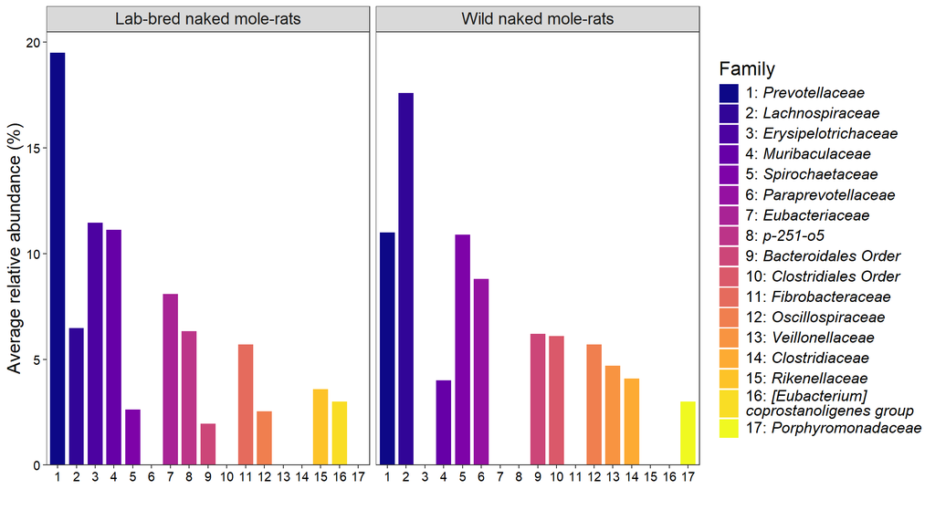

```r
wild.nmr.families<-data.frame(
  Family=c("Lachnospiraceae",
           "Prevotellaceae",
           "Paraprevotellaceae",
           "Bacteroidales Order",
           "Clostridiales Order",
           "Oscillospiraceae",
           "Veillonellaceae",
           "Clostridiaceae",
           "Muribaculaceae",
           "Porphyromonadaceae",
           "Spirochaetaceae"),
  MeanRelativeAbundance=c(17.6,
                          11,
                          8.8,
                          6.2,
                          6.1,
                          5.7,
                          4.7,
                          4.1,
                          4,
                          3,
                          10.9)
)

ps.q.agg.dominant.families.nmr<-ps.q.agg.family%>%
  filter(class=="NMR")%>%
  distinct(class,Phylum,Family, MeanRelativeAbundance)%>%
  arrange(class,desc(MeanRelativeAbundance))

# Add a column if the family was reported as dominant or not
ps.q.agg.dominant.families.nmr.with_domin<-ps.q.agg.dominant.families.nmr%>%
  mutate(row.index=as.numeric(rownames(ps.q.agg.dominant.families.nmr)),
         dominant=ifelse(row.index<=10,"dominant","not_dominant"))

debebe.comparison.plot<-ps.q.agg.dominant.families.nmr.with_domin%>%
  select(Family,MeanRelativeAbundance,dominant)%>%
  filter(Family%in%wild.nmr.families$Family)%>%
  full_join(ps.q.agg.dominant.families.nmr.with_domin[1:10,
                                                      c("Family",
                                                        "MeanRelativeAbundance",
                                                        "dominant")])%>%
  full_join(wild.nmr.families[,c("Family","MeanRelativeAbundance")],
            by="Family")%>%
  rename(NMR=MeanRelativeAbundance.x,NMRwt=MeanRelativeAbundance.y)%>%
  pivot_longer(cols = c("NMR","NMRwt"),
               names_to = "class",
               values_to = "MeanRelativeAbundance")%>%
  arrange(-MeanRelativeAbundance)%>%
  mutate(Family = ifelse(!grepl(" ",Family),
                         paste0("<i>",Family,"</i>"),
                         Family),
         Family = gsub ("Bacteroidales Order", "<i>Bacteroidales Order</i>", Family),
         Family = gsub ("Clostridiales Order", "<i>Clostridiales Order</i>", Family)
         )%>%
  mutate(Family=factor(Family,levels=unique(Family)))%>%
  group_by(Family)%>%
  mutate(Family_id=cur_group_id(),
         Family_id=factor(Family_id,levels=unique(sort(Family_id))))%>%
  ungroup%>%
  mutate(animal=ifelse(class=="NMR","Lab-bred naked mole-rats","Wild naked mole-rats"))%>%
  replace_na(replace =list( MeanRelativeAbundance=0))%>%
  mutate(Family=gsub("_", " ", Family),
         Family = stringr::str_wrap(Family,width=30),
         Family = stringr::str_replace_all(Family, "\n", "<br>"),
         Family=paste(Family_id,Family,sep = ": "),
         Family=factor(Family, levels=unique(Family)))%>%
  arrange(animal,desc(MeanRelativeAbundance))%>%
  ggplot(aes(x=Family_id,
             y=MeanRelativeAbundance,
             fill=Family))+
  geom_bar(stat = "identity",
           position = position_dodge2(),
           width=0.8 # distance between bars
           )+
  theme_bw()+
  facet_grid(~animal,
             scales="free_x",  # each species will have its own bars inside
             # facet (instead of all bars)
             space = "free_x")+
  labs(x="",
       y="Average relative abundance (%)")+
  coord_cartesian(expand = c("bottom"=FALSE))+
  scale_fill_viridis_d(option = "C")+
  theme(axis.text.x = element_text(angle=0,size=11,hjust=0.5,colour = "black"),# shift
        # the x-axis labels to the right
        # legend.position = "inside",
        axis.title = element_text(size = 15), # size of axis names
        axis.text.y = element_text(size=11,color="black"),
        strip.text.x = ggtext::element_markdown(size = 14),# the name of
        # each facet will be recognised as a markdown object, so we can
        # add line breaks (cause host names are too long)
        legend.position.inside = c(0.9,0.8),
        legend.text = ggtext::element_markdown(size=13),
        legend.title = element_text(size = 16), # size of legend title
        plot.caption = element_text(size=15), # size of plot caption
        panel.grid.minor = element_blank(),
        panel.grid.major = element_blank()
        )
print(debebe.comparison.plot)
```

```r
rm(list = ls(all=TRUE))
gc()
```

```
##           used  (Mb) gc trigger  (Mb) max used  (Mb)
## Ncells 5621895 300.3    8825951 471.4  8701554 464.8
## Vcells 9733391  74.3   16146932 123.2 13389110 102.2
```

# 4 Barplots

## 4.1 Introduction

After importing the QZA files into R and processing them with phyloseq, it’s time to explore the taxonomic composition of our data. We will use the `Polychrome` package to create a custom palette for the barplots. We will build a combined barplot for all hosts.

## 4.2 Load necessary libraries.

```r
# install.packages(c("tidyverse","ggtext","Polychrome"))
library(tidyverse)
```

```
## ✖ purrr::%||%()   masks base::%||%()
```

```r
library(Polychrome)
library(ggtext)
```

## 4.3 Specifying parameters and directory/file names.

Name of the folder with QIIME2 output:

```r
authorname<-"pooled"
```

The taxonomic rank that was used for agglomeration:

```r
agglom.rank<-"Genus"
```

Truncation level that we chose in QIIME2:

```r
truncationlvl<-"234"
```

Single reads or paired reads: decided in QIIME2.

```r
read.end.type<-"single"
```

Specify paths and image formats:

```r
barplot.directory<-"./images/barplots/"
rdafiles.directory<-"./output/rdafiles"
```

Path for custom metadata:

```r
metadata.directory<-"./output/rdafiles"
image.formats<-c("png","tiff")
```

Import abundance table as an rds file (NOT rarefied):

```r
ps.q.agg.date_time<-"20260211_17_01_10"
ps.q.agg<-readRDS(file=file.path(
  rdafiles.directory,
  paste(ps.q.agg.date_time,"phyloseq-qiime",authorname,agglom.rank,
        read.end.type, truncationlvl,"table.rds",sep = "-")))

# 20260211_17_01_07 ps.q.agg.date_time ASV level, all hosts
# 20260211_17_01_10 ps.q.agg.date_time genus level, all hosts
# 20260211_17_01_09 ps.q.agg.date_time family level, all hosts
# 20260211_17_01_08 ps.q.agg.date_time phylum level, all hosts
```

Import metadata:

```r
custom.md<-readRDS(file.path(metadata.directory,"custom.md.rds"))
custom.levels<-c("NMR","B6mouse","MSMmouse","FVBNmouse",
                 "DMR","hare","rabbit","spalax","pvo")
```

Set “pretty” labels for barplot facets that correspond to animal hosts. Here, the left side of the vector (values) is taken from the metadata, while the right side (names) are the pretty labels that will be shown on the final barplot.

```r
pretty.level.names<-c("NMR" = "*Heterocephalus glaber*", # better labels for facets
                      "DMR" = "*Fukomys damarensis*",
                      "B6mouse" = "B6 mouse",
                      "MSMmouse" = "MSM/Ms mouse",
                      "FVBNmouse" = "FVB/N<br>mouse",
                      "spalax" = "*Nannospalax leucodon*",
                      "pvo" = "*Pteromys volans orii*",
                      "hare" = "*Lepus europaeus*",
                      "rabbit" = "*Oryctolagus cuniculus*")
```

## 4.4 Set up the barplot.

First, find where the agglom.rank column is located (what number the `Genus` columns is located at, for example). In case of ASV table, the column is actually called `OTU`.  
We also need to know the location of the preceding taxonomic rank (e.g. `Family`). Usually, it’s to the left of the agglom.rank column.

```r
if(agglom.rank=="OTU"){
  agglom.rank.col<-which(colnames(ps.q.agg) =="Species")
}else{
  agglom.rank.col<-which(colnames(ps.q.agg) ==agglom.rank)
  preceding.rank.col<-which(colnames(ps.q.agg) ==agglom.rank)-1
  preceding.rank<-colnames(ps.q.agg)[preceding.rank.col]
}
custom_order <- c("Kingdom", "Phylum", "Class", "Order", "Family",
                  "Genus","Species")
```

If we agglomerate by higher level (Order, Class, etc), need to adjust the rank by removing the levels below. In case of Order-level data, remove the `Family`, and `Genus`

```r
if(agglom.rank%in%custom_order){
  agglom.rank.index<-match(agglom.rank,custom_order)
  custom_order<-custom_order[1:agglom.rank.index-1]
}
```

### 4.4.1 Tidy up the taxonomic names.

First, merge the taxonomic columns into the “taxon” column to find unclassified taxa. If a taxon has “Kingdom”, “Phylum”, “Class”, “Order”, etc. in one of those columns, this taxon is unclassified. These will be left as they are (“taxon” value becomes the agglom.rank), but classified taxa should have the preceding rank in the brackets (agglom.rank and preceding.rank). For example, “Prevotella (Prevotellaceae)” is classified, while “Lachnospiraceae Family” is not. The barplot needs to reflect this. At this point, the “taxon” column is changed. Moreover, if the average relative abundance of a taxon is less than 1%, the “taxon” value becomes “Remainder (mean relative abundance < 1%)” to avoid too many names in the legend.

Unclassified taxa need to be separate from classified ones: we put unclassified ones at the top of the legend. Then, we sort both groups alphabetically.  
Another thing we need to do is wrapping long names using `str_wrap`. We convert the “taxon” column into factor and set the levels as follows: the first level is the “Remainder (mean relative abundance < 1%)” string. Next, unclassified taxa, then classified taxa. We use the str_detect to find unclassified taxa because these have Kingdom or Phylum in the name.

```r
new.df<-ps.q.agg%>%
  unite("taxon",Kingdom:all_of(agglom.rank),sep = ";",remove = FALSE)%>%
  mutate(is_unclassified = grepl
         ("Kingdom|Phylum|Class|Order|Family|Genus|Species",taxon))%>% # add column to show that a taxon was unclassified
  mutate(taxon=ifelse(is_unclassified,
                       get(agglom.rank),
                       paste0(get(agglom.rank), " (",get(preceding.rank),
                              ")")),
         taxon=ifelse(MeanRelativeAbundance<1,"Remainder (mean relative abundance < 1%)",taxon))%>% # if a taxon is classified, we change it to show the preceding rank, e.g Family (Genus)
  group_by_at(c("is_unclassified",preceding.rank))%>%
  arrange(desc(is_unclassified),
          get(preceding.rank),
          taxon,
          .by_group = TRUE)%>% # sort within unclassified and classified taxa (by group)
  ungroup()%>%
  mutate(taxon = gsub("_", " ", taxon),
         taxon = str_wrap(taxon,width=32))%>%
  mutate(taxon=factor(taxon,levels=unique(taxon)),
         taxon=taxon%>%
           fct_relevel(c("Remainder (mean relative\nabundance < 1%)",
                         unique(unlist(lapply(custom_order,
                                              function(pat){levels(.)[str_detect(levels(.),
                                                                                 fixed(pat))]
                                                            })))
                         ),
                       after=0))%>% # change taxon column to factor. Then, we set "Remainder" as the first level, unclassified taxa next, then classified taxa. we use the str_detect to find unclassified taxa because these have Kingdom or Phylum in the name
  ungroup()
```

Create a color palette

```r
set.seed(1)
plot.cols<-createPalette(length(levels(unique(new.df$taxon))),
                         seedcolors =rainbow(7))# input: number of rows

plot.cols<-c("#C1CDCD",plot.cols[1:length(plot.cols)-1])
col.vec<-setNames(plot.cols,levels(new.df$taxon))
```

## 4.5 Plot the barplot.

We will concatenate the sample name on the x-axis with the number of reads in that sample. It will look like “Sample 1 (n = 25000)”. Actually, this kind of string will be stored in a new column called NewSample.

Then, we will convert the “class” column (host names) into factors that we defined in custom.levels. This will order our bars according to the vector of levels. It must be factor because this allows us ordering custom.levels as we want, otherwise it would be alphabetic. And in our vector, the first level is naked mole-rats. So, the first facet will also be naked mole-rats. Facets are panels that correspond to animal host.

```r
barplot.all<-new.df%>%
  group_by(Sample)%>%
  mutate(TotalAbundance=sum(Abundance))%>% # add total counts per sample,
  # so we can have info about sample size
  ungroup()%>%
  mutate(NewSample=paste0(Sample," (n = ", TotalAbundance, ")"))%>% # add a
  # column where sample names are together with sample sizes
  mutate(class=fct_relevel(class,
                           custom.levels,
                           after = 0))%>%
  # filter(class%in%c("NMR","B6mouse"))%>%
  ggplot(aes(x=NewSample,y=RelativeAbundance,fill=taxon))+
  geom_bar(stat="identity")+
  facet_grid(~class, # separate animal hosts
             scales="free",  # each species will have its own bars inside
             # facet (instead of all bars)
             space = "free",
             labeller = labeller(class=pretty.level.names))+
  theme(legend.position = "bottom")+
  coord_cartesian(expand=FALSE) +
  scale_fill_manual(values = col.vec)+ # custom fill that is based on our
  # custom palette
  xlab("") +
  ylab("Relative Abundance (%)")+
  labs(fill="Taxon",
       caption="Mean Relative Abundance was calculated for each host separately")+
  theme_bw()+
  guides(fill = guide_legend(ncol = 6))+
  # ggtitle(paste(agglom.rank,"level gut microbiota profiles of fecal samples from different rodents"))+
  theme(plot.margin=unit(c(0.1,0.1,0.1,0.5), 'cm'),
        axis.text.y = element_text(size=5), # size of y axis ticks
        axis.title = element_text(size = 7), # size of axis names
        strip.text.x = ggtext::element_markdown(size = 5), # the name of
        # each facet will be recognised as a markdown object, so we can
        # add line breaks (cause host names are too long)
        axis.text.x = element_text(angle=45,size=6,hjust=1),# rotate
        # the x-axis labels by 45 degrees and shift to the right
        plot.caption = element_text(size=5), # size of plot caption
        plot.title = element_text(size = 5), # size of plot title
        panel.grid.minor = element_blank(),
        panel.grid.major = element_blank(),
        legend.title= element_text(size = 7),
        legend.box.spacing = unit(0.1,"lines"), # space between the plot and the legend box
        legend.key.spacing.y = unit(2, "pt"), # distance between the legend's key text
        legend.key.size = unit(0.3, 'cm'), # change legend key size
        legend.text = element_text(margin = margin(l=1), size = 5), # size of the legend text
        legend.position = "bottom" # place the legend under the plot
  )
```

Information about padding and legend size was obtained from: https://stackoverflow.com/a/78067650  
Show the plot:

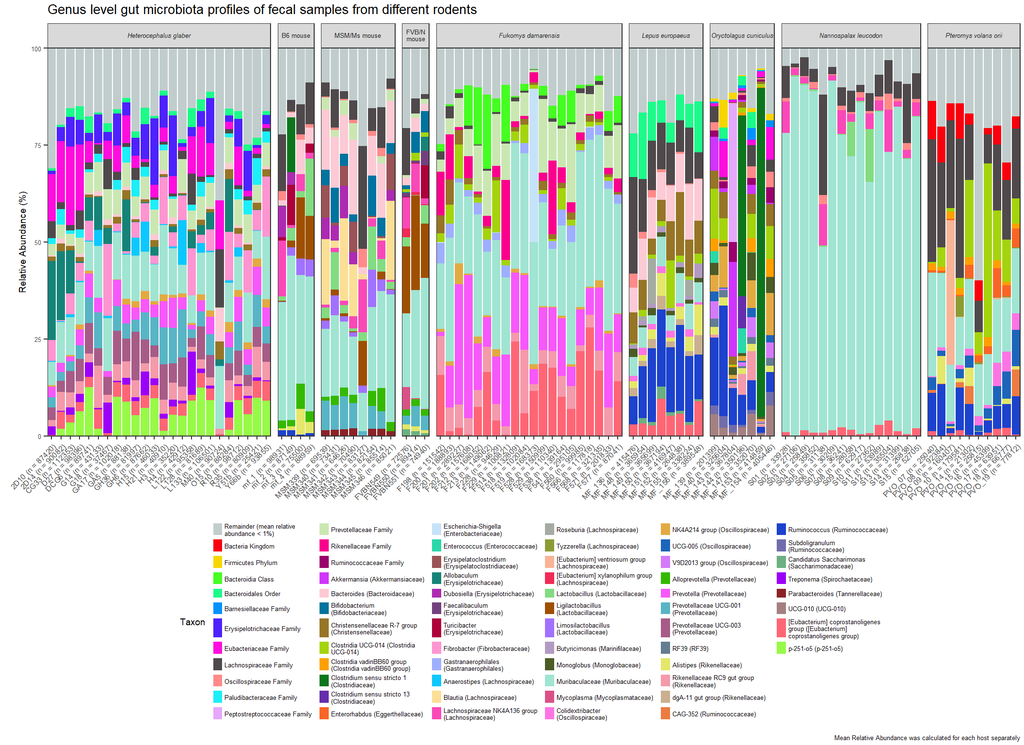

```r
print(barplot.all+
        ggtitle(paste(agglom.rank,"level gut microbiota profiles of fecal samples from different rodents"))+
        theme(plot.title = element_text(size=10))
      )
```

```r
rm(list = ls(all=TRUE))
gc()
```

```
##           used (Mb) gc trigger  (Mb) max used  (Mb)
## Ncells 1800928 96.2    3468485 185.3  2488569 133.0
## Vcells 3459548 26.4    8388608  64.0  8324211  63.6
```

# 5 PCA

## 5.1 Introduction

This script performs PCA to see how similar our samples are, then plot the results using PCA biplot.

## 5.2 Load necessary libraries.

```r
# if(!requireNamespace("BiocManager")){
#   install.packages("BiocManager")
# }
# BiocManager::install("phyloseq")
# install.packages(c("tidyverse","vegan","Polychrome"))
library(tidyverse)
```

```
## ✖ purrr::%||%()   masks base::%||%()
```

```r
library(vegan) # Need v2.6-4 instead of current (2.7-1)
```

## 5.3 Specifying parameters and directory/file names.

Name of the folder with QIIME2 output:

```r
authorname<-"pooled"
```

Specify paths and image formats:

```r
rdafiles.directory<-"./output/rdafiles"
rtables.directory<-file.path("./output/rtables",authorname)
image.formats<-c("png","tiff")
```

Truncation level that we chose in QIIME2:

```r
truncationlvl<-"234"
```

The taxonomic rank that was used for agglomeration:

```r
agglom.rank<-"Genus"
```

Single reads or paired reads (decided in QIIME2):

```r
read.end.type<-"single"
```

Import abundance table as an rds file (NOT rarefied):

```r
ps.q.agg.date_time<-"20260211_17_01_10"
ps.q.agg<-readRDS(file=file.path(
  "./output/rdafiles",
  paste(ps.q.agg.date_time,"phyloseq-qiime",authorname,agglom.rank,
        read.end.type, truncationlvl,"table.rds",sep = "-")))
# 20260211_17_01_07 ps.q.agg.date_time ASV level, all hosts
# 20260211_17_01_10 ps.q.agg.date_time genus level, all hosts
# 20260211_17_01_09 ps.q.agg.date_time family level, all hosts
# 20260211_17_01_08 ps.q.agg.date_time phylum level, all hosts
```

Import the rarefied abundance table:

```r
ps.q.df.pca.input.date_time<-"20260211_17_14_19"
```

Import metadata:

```r
custom.md<-readRDS("./output/rdafiles/custom.md.rds")
```

This is for plot filenames:

```r
plot.types<-c("plot"="",
              "plot.with.labels"="-with-labels")
```

Set “pretty” labels

```r
pretty.level.names<-c("NMR" = "*H. glaber*", # better labels for facets
                      "DMR" = "*F. damarensis*",
                      "B6mouse" = "B6 mouse",
                      "MSMmouse" = "MSM/Ms mouse",
                      "FVBNmouse" = "FVB/N mouse",
                      "spalax" = "*N. leucodon*",
                      "pvo" = "*P. v. orii*",
                      "hare" = "*L. europaeus*",
                      "rabbit" = "*O. cuniculus*")
custom.levels<-intersect(names(pretty.level.names),custom.md$class)
```

Set a general theme for ggplot2. Add more parameters depending on the plot.

```r
mytheme <- theme(plot.title = element_text(size = 27),
                 axis.text.x = element_text(angle=0,size=20),
                 axis.text.y = element_text(size=20),
                 axis.title = element_text(size = 20),
                 legend.text = ggtext::element_markdown(size = 15),
                 legend.title = element_text(size = 25),
                 legend.position = "right",
                 plot.caption = ggtext::element_markdown(hjust = 0,
                                                         size=20),
                 plot.caption.position = "plot",
                 panel.grid.minor = element_blank(),
                 panel.grid.major = element_blank()
)
```

Remove rows with 0 Abundance, if there’s any.

```r
ps.q.agg<-ps.q.agg%>%
    filter(class%in%custom.levels,Abundance!=0)
```

## 5.4 PCA

Import rarefied dataframe.

```r
ps.q.df.pca.input<-readRDS(
  file.path(rdafiles.directory,paste0(
    paste(
      ps.q.df.pca.input.date_time,
      "ps.q.df.rare-nonfiltered",agglom.rank,
      paste(custom.levels,collapse = '-'),sep = "-"),
    ".rds")))
```

Convert into wide format.

```r
ps.q.df.wide.pca<-ps.q.df.pca.input%>%
  dplyr::select(all_of(c(agglom.rank,"Sample","Abundance")))%>%
  pivot_wider(names_from = all_of(agglom.rank),
              values_from = "Abundance",
              values_fill = 0)%>%
  as.data.frame()
```

Column names are ASVs and row names are sample IDs.

```r
rownames(ps.q.df.wide.pca)<-ps.q.df.wide.pca$Sample
```

Remove the Sample column (the first column)

```r
ps.q.df.wide.pca<-ps.q.df.wide.pca[,-1]
ps.q.df.wide.pca<-as.matrix(ps.q.df.wide.pca)
```

The first crucial step is to transform the compositional data: Use a log-ratio transformation, typically the centered log-ratio (clr) or isometric log-ratio (ilr) transformation. The clr transformation is often preferred for interpretability, while ilr is used for statistical properties. We will use robust CLR (RCLR) with natural log.

```r
ps.q.df.wide.pca.tfm<-decostand(ps.q.df.wide.pca,
                                method="rclr",
                                logbase = exp)
```

Calculate principal components

```r
pca.q<-prcomp(ps.q.df.wide.pca.tfm)
str(pca.q)
```

```
## List of 5
##  $ sdev    : num [1:99] 6.97 5.41 4.89 3.82 3.38 ...
##  $ rotation: num [1:453, 1:99] -0.03152 -0.0778 -0.18165 -0.01843 0.00281 ...
##   ..- attr(*, "dimnames")=List of 2
##   .. ..$ : chr [1:453] "Clostridium_sensu_stricto_1" "Lachnospiraceae Family" "Ruminococcus" "Akkermansia" ...
##   .. ..$ : chr [1:99] "PC1" "PC2" "PC3" "PC4" ...
##  $ center  : Named num [1:453] -0.0768 3.2566 1.0767 -0.1418 -0.1708 ...
##   ..- attr(*, "names")= chr [1:453] "Clostridium_sensu_stricto_1" "Lachnospiraceae Family" "Ruminococcus" "Akkermansia" ...
##  $ scale   : logi FALSE
##  $ x       : num [1:99, 1:99] -3.599 -3.611 -3.63 0.916 -4.296 ...
##   ..- attr(*, "dimnames")=List of 2
##   .. ..$ : chr [1:99] "MF_153" "MF_144" "MF_143" "F568" ...
##   .. ..$ : chr [1:99] "PC1" "PC2" "PC3" "PC4" ...
##  - attr(*, "class")= chr "prcomp"
```

- `sdev` is standard deviations of principal components. Used to construct the scree plot
- `rotation` is loadings
- `center` is values used for centering  
  `x` is scores (original data in the new coordinate system) s

```r
dim(pca.q$x)
```

```
## [1] 99 99
```

### 5.4.1 Scree plot.

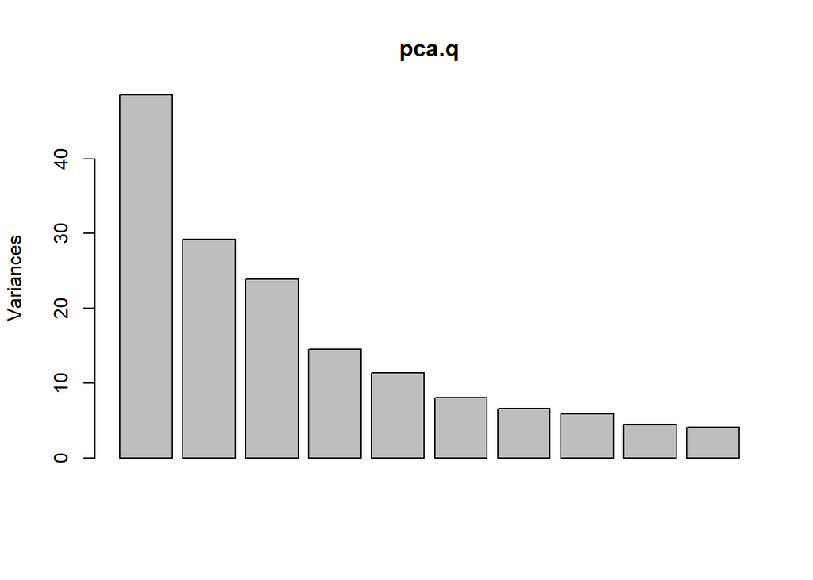

```r
plot(pca.q)
```

Calculate total variance explained by each principal component.

```r
pca.q$sdev^2 / sum(pca.q$sdev^2)
```

```
##  [1] 1.744725e-01 1.051049e-01 8.601101e-02 5.231909e-02 4.094930e-02
##  [6] 2.880968e-02 2.375095e-02 2.108757e-02 1.584835e-02 1.483367e-02
## [11] 1.428852e-02 1.357512e-02 1.310330e-02 1.262264e-02 1.197909e-02
## [16] 1.172715e-02 1.120764e-02 1.076258e-02 1.029480e-02 9.904512e-03
## [21] 9.212540e-03 9.132490e-03 8.972234e-03 8.667591e-03 8.506074e-03
## [26] 8.282911e-03 8.204947e-03 8.110227e-03 7.845169e-03 7.630207e-03
## [31] 7.374500e-03 7.224884e-03 7.136563e-03 6.989461e-03 6.909612e-03
## [36] 6.531880e-03 6.437620e-03 6.322104e-03 6.146358e-03 5.976846e-03
## [41] 5.751596e-03 5.677508e-03 5.586847e-03 5.311083e-03 5.225144e-03
## [46] 5.060255e-03 4.990511e-03 4.824745e-03 4.707292e-03 4.665081e-03
## [51] 4.505377e-03 4.270703e-03 4.164786e-03 4.100307e-03 4.033182e-03
## [56] 3.971821e-03 3.818998e-03 3.810236e-03 3.653010e-03 3.468019e-03
## [61] 3.401557e-03 3.335419e-03 3.191321e-03 3.108696e-03 3.073076e-03
## [66] 3.027988e-03 2.898403e-03 2.768525e-03 2.745600e-03 2.579934e-03
## [71] 2.564928e-03 2.449996e-03 2.385286e-03 2.359917e-03 2.283972e-03
## [76] 2.142193e-03 2.087694e-03 2.007430e-03 1.934505e-03 1.886858e-03
## [81] 1.827991e-03 1.772764e-03 1.674376e-03 1.621538e-03 1.532195e-03
## [86] 1.417016e-03 1.389677e-03 1.295239e-03 1.224857e-03 1.203206e-03
## [91] 1.160403e-03 1.098644e-03 9.714754e-04 9.425636e-04 8.263662e-04
## [96] 7.664012e-04 6.814456e-04 4.974547e-04 3.440863e-32
```

Calculate total variance explained by each principal component.

```r
var_explained = pca.q$sdev^2 / sum(pca.q$sdev^2)
```

Create a scree plot:

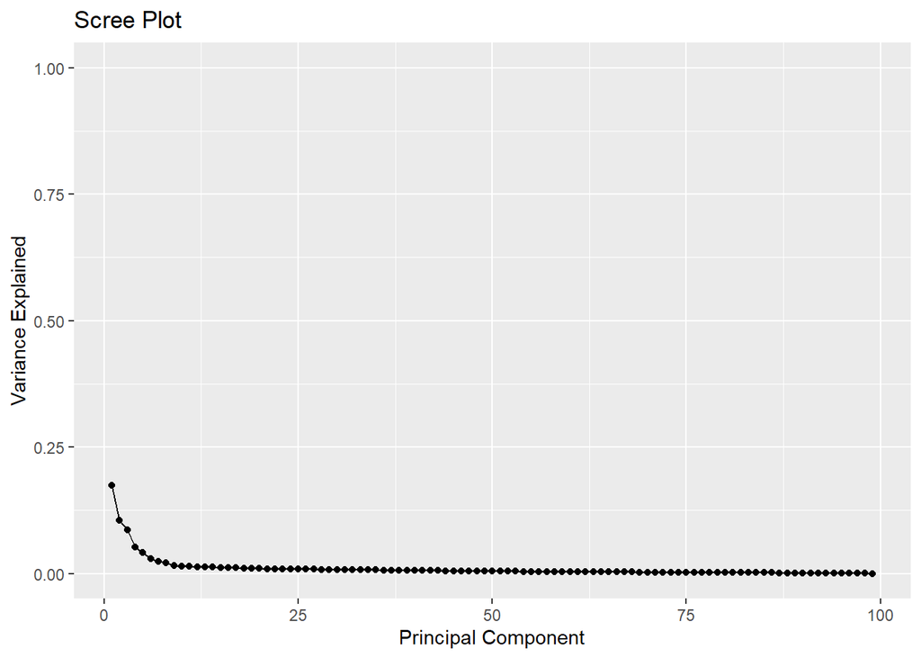

```r
qplot(seq_along(1:nrow(ps.q.df.wide.pca.tfm)), var_explained) +
  geom_line() +
  xlab("Principal Component") +
  ylab("Variance Explained") +
  ggtitle("Scree Plot") +
  ylim(0, 1)
```

### 5.4.2 Loading plot.

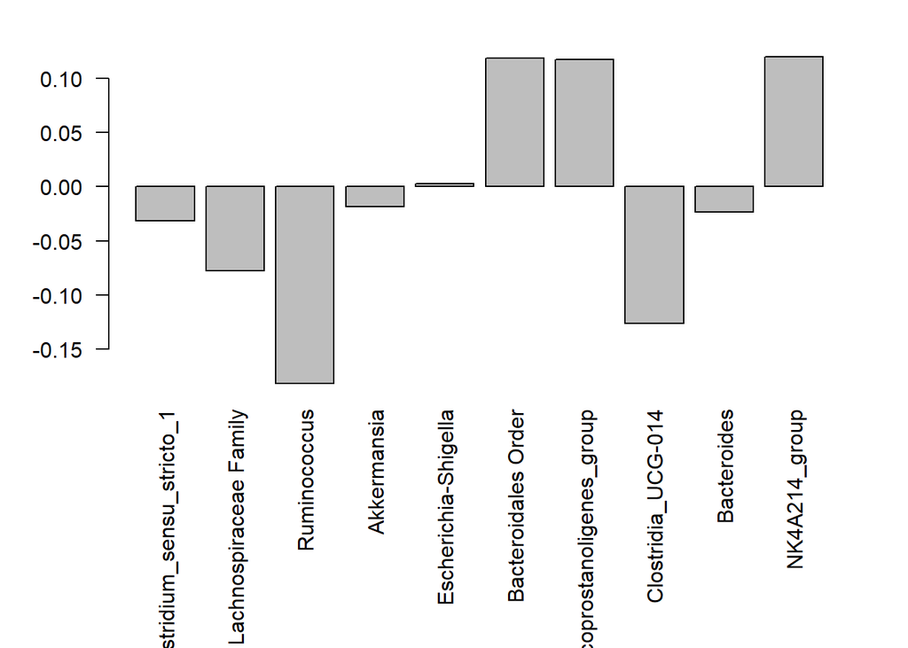

```r
par(mar = c(10, 4, 2, 2) + 0.2) #
barplot(pca.q$rotation[1:10,1],las=2)
```

Display principal components (loadings):

```r
head(pca.q$rotation[,1:10])
```

```
##                                      PC1          PC2          PC3         PC4
## Clostridium_sensu_stricto_1 -0.031518059  0.036707731  0.064412501 -0.07961709
## Lachnospiraceae Family      -0.077795705 -0.094532634  0.023433122  0.06092577
## Ruminococcus                -0.181652311 -0.028448405  0.321060294  0.05384011
## Akkermansia                 -0.018433932  0.032391532  0.102289018 -0.08491319
## Escherichia-Shigella         0.002808135  0.007096814 -0.002429096  0.03242215
## Bacteroidales Order          0.118888893  0.078186505  0.091923056  0.26370432
##                                     PC5         PC6          PC7          PC8
## Clostridium_sensu_stricto_1  0.02456757 -0.13674236  0.159367051 -0.071214747
## Lachnospiraceae Family      -0.11715911  0.15138783 -0.052866286  0.073385777
## Ruminococcus                -0.06080495  0.06459345 -0.078896636  0.048876056
## Akkermansia                  0.10495458 -0.13321163  0.149813463  0.054961882
## Escherichia-Shigella         0.04523813 -0.02271905 -0.004382312 -0.008058512
## Bacteroidales Order         -0.11606434 -0.13996492  0.095809564 -0.098481569
##                                     PC9        PC10
## Clostridium_sensu_stricto_1 -0.02094601 -0.07158920
## Lachnospiraceae Family      -0.05668997 -0.01107006
## Ruminococcus                 0.11322750 -0.01090265
## Akkermansia                 -0.16206724 -0.14051758
## Escherichia-Shigella        -0.04415288  0.02211869
## Bacteroidales Order         -0.01335693 -0.02128727
```

Display the first six scores:

```r
head(pca.q$x[,1:10])
```

```
##               PC1        PC2       PC3        PC4        PC5        PC6
## MF_153 -3.5985547  1.1836953  7.404343 -6.1829404  3.8997891 -4.5900342
## MF_144 -3.6106287  2.0027573 11.137334 -2.9507908  5.3331872 -4.7472887
## MF_143 -3.6298166  0.2339191  8.314244 -7.1961136  6.1584604 -5.6813638
## F568    0.9162817  9.9723559 -2.357291  0.6690833 -0.9185572 -0.2974813
## MF_136 -4.2964931 -1.8217090  5.668957  8.6751183 -0.5461135 -0.9644861
## F541    2.3332504 10.3538301 -3.057309  1.8544092  0.8968698  0.8638079
##               PC7        PC8        PC9       PC10
## MF_153  3.1238607 -1.8597256  3.1576570  1.3203312
## MF_144  6.3305536 -1.7412050 -1.1672293 -4.1115970
## MF_143  2.1231266 -0.8611543  1.2628157  0.1094953
## F568   -0.9385405 -0.2132931 -0.3782896 -0.3737285
## MF_136 -0.2045075  0.4299077 -1.6175520 -4.4929553
## F541   -0.2682827  0.1482054  0.5726769 -0.8067776
```

## 5.5 PCA Plot.

```r
PC1<-pca.q$x[,1]
PC2<-pca.q$x[,2]
```

Check how much variance is explained by the first two principal components:

```r
perc.var<-round(100*summary(pca.q)$importance[2,1:2],2)
perc.var
```

```
##   PC1   PC2
## 17.45 10.51
```

Combine the principal component vectors into a dataframe:

```r
PC1.df <- as.data.frame(PC1)%>%
  mutate(Sample = rownames(ps.q.df.wide.pca))
PC2.df <- as.data.frame(PC2)%>%
  mutate(Sample = rownames(ps.q.df.wide.pca))
```

Plot the PCA results:

```r
pca.plot<-PC1.df%>%
  left_join(PC2.df)%>%
  left_join(custom.md)%>%
  mutate(class = factor(class, levels=custom.levels))%>%
  group_by(class)%>%
  mutate(class_id = cur_group_id(), # add numeric id
         class_name = pretty.level.names[class_id])%>%
  ggplot(aes(x = PC1,
             y = PC2,
             color = class_name,
             fill = class_name)) +
  geom_point(aes(shape = class_name),
             size = 2,
             color = "black")+
  scale_shape_manual(values = 0:9,
                     breaks = pretty.level.names,
                     labels = unname(pretty.level.names))+
  stat_ellipse(geom = "polygon",
               level = 0.8,
               alpha = 0.2,
               show.legend = FALSE,
               color = "black")+
  scale_fill_viridis_d(option = "C",
                       labels = unname(pretty.level.names))+
  theme_bw()+
  # ggtitle(paste0("PCA between different rodents (",agglom.rank, " level)"))+
  labs(x = paste0("PC1 (", perc.var[1], "%)"),
       y = paste0("PC2 (", perc.var[2], "%)"),
       shape = "Host")+
  guides(fill="none")+
  mytheme+ # general theme
  theme(legend.position = "bottom")+
  labs(shape ="")
```

Label each point by sample name:

```r
pca.plot.with.labels<-pca.plot+
  ggrepel::geom_text_repel(aes(label = Sample),
                           show.legend = FALSE,
                           color = "black")
```

```
## Too few points to calculate an ellipse
```

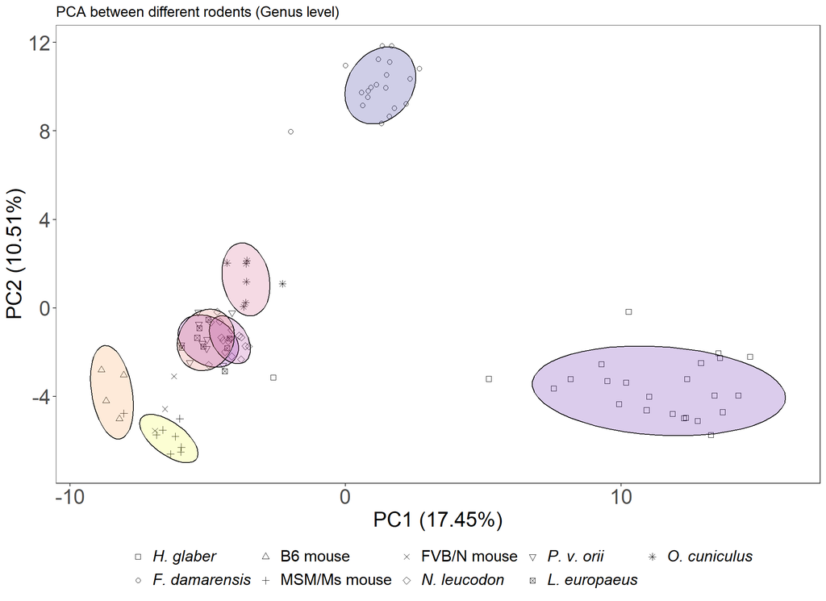

```r
print(pca.plot +
        ggtitle(paste0("PCA between different rodents (",agglom.rank, " level)"))+
        theme(plot.title = element_text(size = 14)))
```

```
## Too few points to calculate an ellipse
```

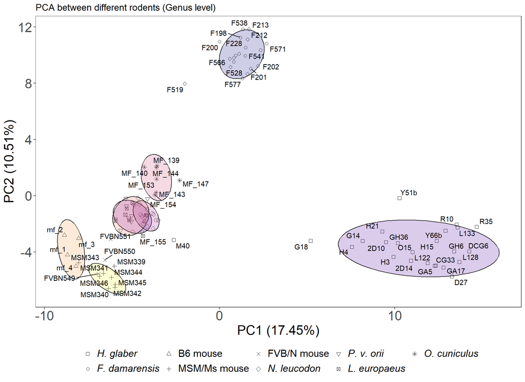

```r
print(pca.plot.with.labels +
        ggtitle(paste0("PCA between different rodents (",agglom.rank, " level)"))+
        theme(plot.title = element_text(size = 14)))
```

```r
# Save the plots
# for(plot.type in seq_along(plot.types)){
#   for(image.format in image.formats){
#     ggsave(filename = paste0(paste(paste(format(Sys.time(), format="%Y%m%d"),
#                               format(Sys.time(), format = "%H_%M_%S"),
#                               sep = "_"),
#                         "pca",
#                         paste(custom.levels,collapse = '-'),
#                         agglom.rank,truncationlvl,sep = "-"),
#                   plot.types[plot.type], ".",image.format),
#            path = "./images/diversity/pca",
#            plot=get(paste0("pca.",names(plot.types[plot.type]))),
#            width=11, height=8,units="in",
#            # width = 4500,height = 3000,units = "px",
#            dpi=300,device = image.format)
#   }
# }
```

## 5.6 Find ASVs that contribute to PCs.

```r
aload<-abs(pca.q$rotation)
```

Below, 2 means columns; sweep divides each column of loadings and divides by the column sum.

```r
head(sweep(aload,2,colSums(aload),"/"))[1:5,1:5]
```

```
##                                      PC1          PC2          PC3         PC4
## Clostridium_sensu_stricto_1 0.0027594790 0.0031605537 0.0057552546 0.007078525
## Lachnospiraceae Family      0.0068111940 0.0081393063 0.0020937486 0.005416734
## Ruminococcus                0.0159040801 0.0024494216 0.0286867256 0.004786768
## Akkermansia                 0.0016139334 0.0027889268 0.0091395201 0.007549385
## Escherichia-Shigella        0.0002458587 0.0006110392 0.0002170397 0.002882559
##                                     PC5
## Clostridium_sensu_stricto_1 0.002043314
## Lachnospiraceae Family      0.009744263
## Ruminococcus                0.005057220
## Akkermansia                 0.008729197
## Escherichia-Shigella        0.003762509
```

```r
colSums(sweep(aload, 2, colSums(aload), "/"))
```

```
##  PC1  PC2  PC3  PC4  PC5  PC6  PC7  PC8  PC9 PC10 PC11 PC12 PC13 PC14 PC15 PC16
##    1    1    1    1    1    1    1    1    1    1    1    1    1    1    1    1
## PC17 PC18 PC19 PC20 PC21 PC22 PC23 PC24 PC25 PC26 PC27 PC28 PC29 PC30 PC31 PC32
##    1    1    1    1    1    1    1    1    1    1    1    1    1    1    1    1
## PC33 PC34 PC35 PC36 PC37 PC38 PC39 PC40 PC41 PC42 PC43 PC44 PC45 PC46 PC47 PC48
##    1    1    1    1    1    1    1    1    1    1    1    1    1    1    1    1
## PC49 PC50 PC51 PC52 PC53 PC54 PC55 PC56 PC57 PC58 PC59 PC60 PC61 PC62 PC63 PC64
##    1    1    1    1    1    1    1    1    1    1    1    1    1    1    1    1
## PC65 PC66 PC67 PC68 PC69 PC70 PC71 PC72 PC73 PC74 PC75 PC76 PC77 PC78 PC79 PC80
##    1    1    1    1    1    1    1    1    1    1    1    1    1    1    1    1
## PC81 PC82 PC83 PC84 PC85 PC86 PC87 PC88 PC89 PC90 PC91 PC92 PC93 PC94 PC95 PC96
##    1    1    1    1    1    1    1    1    1    1    1    1    1    1    1    1
## PC97 PC98 PC99
##    1    1    1
```

```r
colSums(aload)
```

```
##      PC1      PC2      PC3      PC4      PC5      PC6      PC7      PC8
## 11.42174 11.61434 11.19195 11.24770 12.02339 12.04236 12.64831 12.93837
##      PC9     PC10     PC11     PC12     PC13     PC14     PC15     PC16
## 13.48081 13.33036 13.80955 13.35380 14.74120 14.35129 14.44915 14.44764
##     PC17     PC18     PC19     PC20     PC21     PC22     PC23     PC24
## 14.58393 14.20721 15.47676 14.43393 14.59855 14.92279 15.07775 15.48744
##     PC25     PC26     PC27     PC28     PC29     PC30     PC31     PC32
## 15.04753 15.42653 14.82999 15.06155 16.01102 15.32288 15.06023 15.07044
##     PC33     PC34     PC35     PC36     PC37     PC38     PC39     PC40
## 15.53181 15.10457 15.67300 15.51065 15.48762 15.32792 15.47530 15.30194
##     PC41     PC42     PC43     PC44     PC45     PC46     PC47     PC48
## 15.83838 15.43000 15.34449 15.60465 15.71492 15.62779 15.95517 15.23497
##     PC49     PC50     PC51     PC52     PC53     PC54     PC55     PC56
## 14.80808 15.68980 15.20470 15.26584 15.70624 15.55117 15.48802 15.11079
##     PC57     PC58     PC59     PC60     PC61     PC62     PC63     PC64
## 16.22583 14.80225 16.22380 15.70449 15.87198 15.99083 15.32445 16.03342
##     PC65     PC66     PC67     PC68     PC69     PC70     PC71     PC72
## 15.47449 15.51278 15.60883 15.44067 15.98639 16.02878 16.01400 15.48818
##     PC73     PC74     PC75     PC76     PC77     PC78     PC79     PC80
## 16.38325 15.57759 15.99477 15.48283 15.72872 16.19011 15.52008 15.39930
##     PC81     PC82     PC83     PC84     PC85     PC86     PC87     PC88
## 15.76407 16.05936 15.74108 15.48130 15.29148 15.66499 15.79093 15.07205
##     PC89     PC90     PC91     PC92     PC93     PC94     PC95     PC96
## 15.29634 15.45195 15.35486 14.99253 15.68676 14.91006 14.83783 15.41061
##     PC97     PC98     PC99
## 15.23829 14.34926 14.96599
```

```r
aload[1,1]/colSums(aload)[1]
```

```
##         PC1
## 0.002759479
```

```r
pc.df<-as.data.frame(sweep(aload,2,colSums(aload),"/")[,1:2])
lapply(pc.df,max)
```

```
## $PC1
## [1] 0.02093477
##
## $PC2
## [1] 0.02432026
```

```r
max.ind<-lapply(pc.df,which.max)
pc.df[max.ind$PC1,]
```

```
##                                   PC1         PC2
## Erysipelotrichaceae Family 0.02093477 0.009611688
```

```r
pc.df[max.ind$PC2,]
```

```
##                              PC1        PC2
## Rikenellaceae Family 0.001550251 0.02432026
```

```r
pc1.loadings<-pc.df%>%
  rownames_to_column(var=agglom.rank)%>%
  arrange(-PC1)%>%
  mutate(PC_num="PC1")%>%
  head()
pc2.loadings<-pc.df%>%
  rownames_to_column(var=agglom.rank)%>%
  arrange(-PC2)%>%
  mutate(PC_num="PC2")%>%
  head()

pc1.loadings$Genus
```

```
## [1] "Erysipelotrichaceae Family" "Prevotella"
## [3] "Prevotellaceae_UCG-003"     "p-251-o5"
## [5] "Prevotellaceae Family"      "Fibrobacter"
```

```r
pc2.loadings$Genus
```

```
## [1] "Rikenellaceae Family"   "Bacteroidia Class"      "Prevotella"
## [4] "Gastranaerophilales"    "Eggerthellaceae Family" "Prevotellaceae_UCG-001"
```

```r
loadings.df<-pc1.loadings%>%
  rbind(pc2.loadings)%>%
  dplyr::select(-PC1,-PC2)%>%
  add_count(Genus)%>%
  mutate(PC_num=ifelse(n==2,"PC1_and_PC2",PC_num))%>%
  distinct(Genus,PC_num)
loadings.df
```

```
##                         Genus      PC_num
## 1  Erysipelotrichaceae Family         PC1
## 2                  Prevotella PC1_and_PC2
## 3      Prevotellaceae_UCG-003         PC1
## 4                    p-251-o5         PC1
## 5       Prevotellaceae Family         PC1
## 6                 Fibrobacter         PC1
## 7        Rikenellaceae Family         PC2
## 8           Bacteroidia Class         PC2
## 9         Gastranaerophilales         PC2
## 10     Eggerthellaceae Family         PC2
## 11     Prevotellaceae_UCG-001         PC2
```

Check if the loadings are found in the data:

```r
source("./code/r-scripts/add_relab_to_tax_df.R")
ps.q.agg.pc_loadings<-add_relab_to_tax_df(ps.q.agg,"Genus")%>%
  distinct(class,Genus,MeanRelativeAbundance,sdRelativeAbundance)%>%
  right_join(loadings.df)
# write.table(ps.q.agg.pc_loadings,
#             file=file.path(rtables.directory,
#                            paste(paste(format(Sys.time(),format="%Y%m%d"),
#                                        format(Sys.time(),format = "%H_%M_%S"),sep = "_"),
#                                  "pca-loadings-mean_relative_abundance.tsv",sep="-")),
#             row.names = F,sep = "\t")
ps.q.agg.pc_loadings
```

```
## # A tibble: 60 × 5
##    class Genus                  MeanRelativeAbundance sdRelativeAbundance PC_num
##    <fct> <chr>                                  <dbl>               <dbl> <chr>
##  1 DMR   Prevotella                             14.2                 8.60 PC1_a…
##  2 DMR   Prevotellaceae Family                   9.26                4.94 PC1
##  3 DMR   Bacteroidia Class                       4.99                5.63 PC2
##  4 DMR   Rikenellaceae Family                    4.28                5.95 PC2
##  5 NMR   Fibrobacter                             5.71                5.01 PC1
##  6 DMR   Gastranaerophilales                     2.48                1.34 PC2
##  7 NMR   Erysipelotrichaceae F…                  5.53                4.57 PC1
##  8 NMR   p-251-o5                                6.32                3.73 PC1
##  9 NMR   Prevotellaceae_UCG-003                  5.48                2.66 PC1
## 10 NMR   Prevotellaceae_UCG-001                  4.63                2.86 PC2
## # ℹ 50 more rows
```

```r
rm(list = ls(all=TRUE))
gc()
```

```
##           used  (Mb) gc trigger  (Mb) max used  (Mb)
## Ncells 2833333 151.4    4347687 232.2  4347687 232.2
## Vcells 4960616  37.9   10146329  77.5  8388251  64.0
```

# 6 Alpha diversity analysis of QIIME2 output

## 6.1 Introduction

This script analyses alpha diversity among hosts. We will compare hosts using three metrics: the number of observed genera, Shannon diversity index, and inverse Simpson index.

## 6.2 Load necessary libraries and scripts.

```r
# if(!requireNamespace("BiocManager")){
#   install.packages("BiocManager")
# }
# BiocManager::install("phyloseq")
# install.packages(c("tidyverse","vegan","Polychrome"))
# library(phyloseq)
library(tidyverse)
```

```
## ✖ purrr::%||%()   masks base::%||%()
```

```r
library(vegan)
```

## 6.3 Specifying parameters and directory/file names.

Name of the folder with QIIME2 output:

```r
authorname<-"pooled"
```

Specify paths and image formats:

```r
rdafiles.directory<-"./output/rdafiles"
rtables.directory<-file.path("./output/rtables",authorname)
image.formats<-c("png","tiff")
```

Truncation level that we chose in QIIME2:

```r
truncationlvl<-"234"
```

The taxonomic rank that was used for agglomeration:

```r
agglom.rank<-"Genus"
```

Single reads or paired reads (decided in QIIME2):

```r
read.end.type<-"single"
```

Import abundance table as an rds file (NOT rarefied):

```r
ps.q.agg.date_time<-"20260211_17_01_10"
ps.q.agg<-readRDS(file=file.path(
  rdafiles.directory,
  paste(ps.q.agg.date_time,"phyloseq-qiime",authorname,agglom.rank,
        read.end.type, truncationlvl,"table.rds",sep = "-")))
# 20260211_17_01_07 ps.q.agg.date_time ASV level, all hosts
# 20260211_17_01_10 ps.q.agg.date_time genus level, all hosts
# 20260211_17_01_09 ps.q.agg.date_time family level, all hosts
# 20260211_17_01_08 ps.q.agg.date_time phylum level, all hosts
```

Import the rarefied abundance table (rds file):

```r
ps.q.df.preprocessed.date_time<-"20260211_17_14_19"
# 20260211_17_14_19 rarefied table for all hosts, genus level
# 20260211_17_14_20 rarefied table file for NMR, genus level
# 20260211_17_14_21 rarefied table file for NMR, ASV level
```

Import metadata:

```r
custom.md<-readRDS(file.path(rdafiles.directory,"custom.md.rds"))
```

Set “pretty” labels

```r
pretty.level.names<-c("NMR" = "*H. glaber*", # better labels for facets
                      "DMR" = "*F. damarensis*",
                      "B6mouse" = "B6 mouse",
                      "MSMmouse" = "MSM/Ms mouse",
                      "FVBNmouse" = "FVB/N mouse",
                      "spalax" = "*N. leucodon*",
                      "pvo" = "*P. v. orii*",
                      "hare" = "*L. europaeus*",
                      "rabbit" = "*O. cuniculus*")
custom.levels<-intersect(names(pretty.level.names),custom.md$class)
```

Facet labels

```r
metric.labs <- c('sobs'= case_when(agglom.rank == "OTU" ~
                                     "Richness \n(Observed species)",
                                agglom.rank == "Genus" ~
                                  "Richness \n(Observed genera)") ,
              'shannon' = "Shannon",
              'invsimpson' = "Inverse \nSimpson")
```

Metrics to plot

```r
plot.metrics<-c("sobs","shannon","invsimpson")
div.indices<-c("sobs","shannon", "invsimpson")

mytheme<-theme(
  axis.title.x = element_blank(),
  axis.title.y = element_blank(),
  axis.text.y = element_text(size=15),
  axis.title = element_text(size = 15),
  strip.text.x = element_text(size=15),
  plot.title = element_text(size = 15),
  legend.text = element_text(size = 15),
  legend.title = element_text(size = 18),
  legend.position = "right",
  panel.grid.minor = element_blank(),
  panel.grid.major = element_blank())
```

Remove rows with 0 Abundance, if there’s any.

```r
ps.q.agg <- ps.q.agg%>%
    filter(class%in%custom.levels,Abundance!=0)
```

Import rarefied dataframe and select Sample, Abundance, class, and agglom.rank columns.

```r
ps.q.df.preprocessed<-readRDS(
  file.path(rdafiles.directory,paste0(
    paste(
      ps.q.df.preprocessed.date_time,
      "ps.q.df.rare-nonfiltered",agglom.rank,
      paste(custom.levels,collapse = '-'),sep = "-"),
    ".rds")))%>%
  filter(class%in%custom.levels, Abundance!=0)%>%
  dplyr::select(Sample,Abundance,class,all_of(agglom.rank),)
```

## 6.4 Alpha diversity analysis.

### 6.4.1 Compute alpha diversity metrics.

```r
all.div<-ps.q.df.preprocessed%>%
  group_by(Sample)%>%
  reframe(sobs=specnumber(Abundance), # richness (num of species)
          shannon=diversity(Abundance,index = "shannon"),
          invsimpson=diversity(Abundance, index="invsimpson"), # inverse simpson
          tot=sum(Abundance),
          class=class)%>%
  group_by(Sample)%>%
  pivot_longer(cols=c(sobs,shannon,invsimpson),
               names_to="metric")%>%
  distinct()
```

### 6.4.2 Alpha diversity tests.

The Kruskal-Wallis rank sum test analyzes differences in each alpha diversity metric across animal hosts.

```r
kt.results<-data.frame(matrix(nrow = 2,ncol=length(div.indices)))
colnames(kt.results)<-div.indices
rownames(kt.results)<-c("statistic", "pvalue")
```

All unique pairwise combinations:

```r
combinations<-combn(custom.levels,2)
w.results<-data.frame(matrix(nrow = ncol(combinations),
                             ncol=length(div.indices))) # ncol(combinations) pairwise comparisons
colnames(w.results)<-div.indices
w.results<-array(dim = c(length(table(combinations[1,])), # nrows
                         length(table(combinations[2,])), # ncols
                         length(div.indices)), # num of 2D arrays (stacking)
                 dimnames = list(NULL, NULL, div.indices))



for (div.metric in div.indices) {
  metric.ds<-all.div%>%
    filter(metric==div.metric)%>%
    distinct()
  # perform kruskal-wallis test
  kt<-kruskal.test(value~class,data=metric.ds)

  kt.results["statistic",div.metric]<- kt$statistic
  kt.results["pvalue",div.metric]<- kt$p.value
  # low pvalue indicates statistical difference between some groups
  # But which groups are different from others?
  # Perform pairwise wilcoxon test

  # NB: You must not run pairwise wilcoxon test unless kruskal wallis results
  # are significant
  if(kt$p.value<0.05){
    w.test<-pairwise.wilcox.test(metric.ds$value,
                                 metric.ds$class,
                                 p.adjust.method = "BH"
                                 ,exact=FALSE
                                 )
    w.results[,,div.metric]<-w.test$p.value

  }else(
    w.results[,,div.metric]<-matrix(data = "n.s.",
                                    nrow = nrow(w.test$p.value),
                                    ncol = ncol(w.test$p.value))

  )
  dimnames(w.results)[[1]]<-dimnames(w.test$p.value)[[1]] # change rownames of w.results
  dimnames(w.results)[[2]]<-dimnames(w.test$p.value)[[2]] # change colnames of w.results
}

kt.results
```

```
##                   sobs      shannon   invsimpson
## statistic 7.280958e+01 7.646242e+01 7.374686e+01
## pvalue    1.352624e-12 2.511894e-13 8.787165e-13
```

```r
w.results
```

```
## , , sobs
##
##               B6mouse          DMR FVBNmouse         hare     MSMmouse
## DMR       0.691993266           NA        NA           NA           NA
## FVBNmouse 0.691993266 2.057970e-01        NA           NA           NA
## hare      0.236012189 1.740406e-03 0.8273413           NA           NA
## MSMmouse  0.981025330 5.162308e-01 0.1830412 0.0040781266           NA
## NMR       0.016498264 3.560095e-06 0.1320516 0.0312766917 0.0004875759
## pvo       0.638688814 3.262471e-01 0.2360122 0.0204299011 0.6625897294
## rabbit    1.000000000 7.172796e-01 0.4371681 0.0741462942 0.9810253298
## spalax    0.008726373 7.392181e-06 0.0204299 0.0005478033 0.0005478033
##                    NMR          pvo       rabbit
## DMR                 NA           NA           NA
## FVBNmouse           NA           NA           NA
## hare                NA           NA           NA
## MSMmouse            NA           NA           NA
## NMR                 NA           NA           NA
## pvo       3.996673e-04           NA           NA
## rabbit    2.590009e-03 0.6625897294           NA
## spalax    3.929571e-06 0.0004875759 0.0009793901
##
## , , shannon
##
##               B6mouse          DMR  FVBNmouse        hare     MSMmouse
## DMR       0.425803710           NA         NA          NA           NA
## FVBNmouse 0.521666471 6.050488e-02         NA          NA           NA
## hare      0.019068304 4.168804e-04 0.63327805          NA           NA
## MSMmouse  0.091437337 5.452710e-03 0.82250895 0.007101269           NA
## NMR       0.005452710 6.815077e-07 0.02432257 0.000441647 0.0002152878
## pvo       0.814132811 1.170594e-01 0.79599888 0.096156624 0.7245959403
## rabbit    0.822508946 3.850466e-01 1.00000000 0.795998883 0.9811102146
## spalax    0.007626574 7.499778e-06 0.01938005 0.000441647 0.0004416470
##                    NMR          pvo      rabbit
## DMR                 NA           NA          NA
## FVBNmouse           NA           NA          NA
## hare                NA           NA          NA
## MSMmouse            NA           NA          NA
## NMR                 NA           NA          NA
## pvo       1.608806e-04           NA          NA
## rabbit    1.014765e-01 0.7959988831          NA
## spalax    3.957312e-06 0.0002152878 0.006747595
##
## , , invsimpson
##
##               B6mouse          DMR  FVBNmouse         hare     MSMmouse
## DMR       1.000000000           NA         NA           NA           NA
## FVBNmouse 0.798870448 3.807495e-01         NA           NA           NA
## hare      0.019068304 6.682285e-04 0.09446310           NA           NA
## MSMmouse  0.063951580 1.044555e-02 0.88195688 0.0271745461           NA
## NMR       0.005948411 5.944136e-07 0.01479553 0.0004907189 0.0002469123
## pvo       0.415935888 2.811976e-01 0.98750821 0.1718127525 0.8819568759
## rabbit    0.818487813 7.988704e-01 1.00000000 0.8508953578 0.9639463193
## spalax    0.008799893 7.499778e-06 0.01938005 0.0004907189 0.0004907189
##                    NMR          pvo      rabbit
## DMR                 NA           NA          NA
## FVBNmouse           NA           NA          NA
## hare                NA           NA          NA
## MSMmouse            NA           NA          NA
## NMR                 NA           NA          NA
## pvo       2.469123e-04           NA          NA
## rabbit    2.673735e-01 0.9639463193          NA
## spalax    3.957312e-06 0.0002469123 0.008799893
```

```r
stopifnot(all(kt.results[2,]<0.05))

# convert multidimensional array into data frame
# w.results.df<-w.results%>%
#   as.data.frame.table()%>%
#   drop_na()
# colnames(w.results.df)<-c("class1","class2","div.metric","p.value")

max.values<-all.div%>%
  group_by(metric)%>%
  summarise(max_val=max(value))

all.div$class<-factor(all.div$class,levels=custom.levels)
```

## 6.5 Plot alpha diversity metrics.

```r
div.plot<-all.div%>%
  filter(metric%in%plot.metrics)%>%
  mutate(class = factor(class, levels = custom.levels))%>%
  group_by(class)%>%
  mutate(class_id = cur_group_id(), # add numeric id
         class_letter = LETTERS[class_id], # then, turn it into a letter
         class_name = paste(class_letter, pretty.level.names[class_id],sep = ": "))%>%
  ggplot(aes(x = class_letter,
             y = value,
             fill = class_name))+
  geom_boxplot(show.legend = T,
               outliers = F)+ # outliers won't be visible anyway
  facet_wrap(~factor(metric, # reorder facets
                     levels=plot.metrics),
             ncol=length(plot.metrics),
             scales="free_y", # free y axis range
             labeller = as_labeller(metric.labs))+ # rename facets
  theme_bw()+
  # scale_color_manual(breaks = unname(pretty.level.names),
  #                    labels=unname(pretty.level.names))+
  # scale_x_discrete(labels=pretty.level.names,
  #                  limits=custom.levels)+ # rename boxplot labels (x axis)
  scale_fill_viridis_d(option="C")+
  stat_summary(fun=median, geom="point", shape=23, size=3, color="black",fill="white",
               position = position_dodge2(width = 0.75,
                                          preserve = "single"))+
  labs(fill = "Host")+
  # ggtitle(paste0("Alpha diversity of the gut microbiota of different rodents \n(",agglom.rank, " level)"))+
  mytheme + # general theme
  theme(axis.text.x = ggtext::element_markdown(size=12),
        legend.text = ggtext::element_markdown(size=15))

div.plot.jitter<-div.plot+
  geom_jitter(aes(colour=class_letter),
              width = 0.1, # jitter spread
              shape = 1, # empty dots
              size=1.8,
              show.legend = FALSE)+
  scale_color_viridis_d(direction = -1,option="C")+
  guides(color = "none")
```

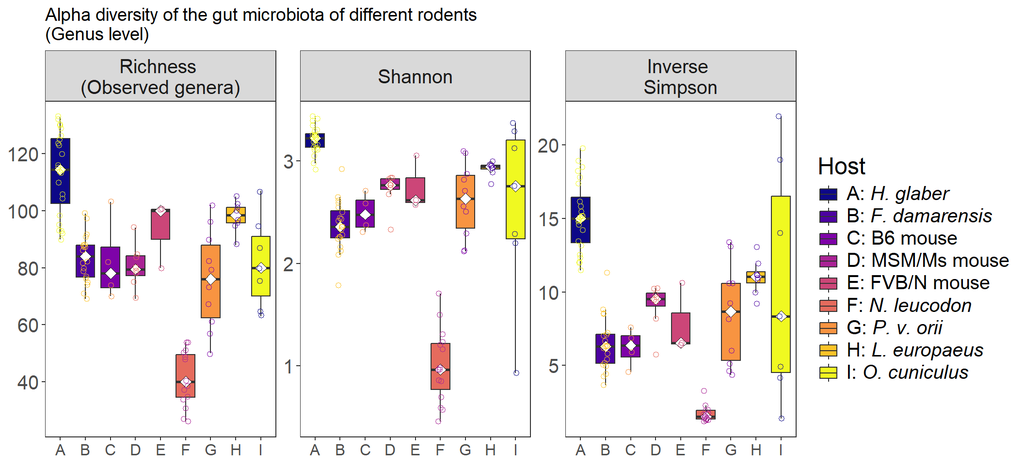

```r
print(div.plot.jitter +
        ggtitle(paste0("Alpha diversity of the gut microbiota of different rodents \n(",agglom.rank, " level)"))+
        theme(plot.title = element_text(size = 14))
)
```

```r
div.plot.dots<-div.plot+
  geom_dotplot(aes(colour=class),
               fill="white",
               color="black",
               binaxis='y',
               stackdir='center',
               dotsize=0.4) # add dots
```

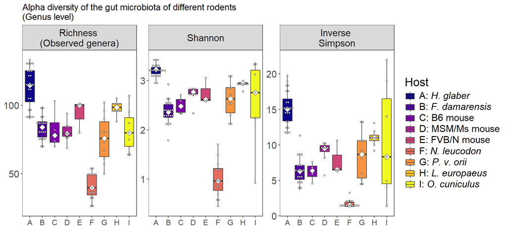

```r
print(div.plot.dots +
        ggtitle(paste0("Alpha diversity of the gut microbiota of different rodents \n(",agglom.rank, " level)"))+
        theme(plot.title = element_text(size = 14))
)
```

```r
# for(image.format in image.formats){
#   ggsave(paste0("./images/diversity/alpha/",
#                 paste(paste(format(Sys.time(),format="%Y%m%d"),
#                             format(Sys.time(),format = "%H_%M_%S"),sep = "_"),
#                       "alpha-jitter",
#                       paste(plot.metrics,collapse = "-"),
#                       paste(custom.levels,collapse = '-'),
#                       agglom.rank,truncationlvl,
#                       sep = "-"),".",image.format),
#          plot=div.plot.jitter,
#          width=11, height=5,units="in",
#          # width = 4500,height = 2000,units = "px",
#          dpi=300,device = image.format)
#   ggsave(paste0("./images/diversity/alpha/",
#                 paste(paste(format(Sys.time(),format="%Y%m%d"),
#                             format(Sys.time(),format = "%H_%M_%S"),sep = "_"),
#                       "alpha-dots",
#                       paste(plot.metrics,collapse = "-"),
#                       paste(custom.levels,collapse = '-'),
#                       agglom.rank,truncationlvl,
#                       sep = "-"),".",image.format),
#          plot=div.plot.dots,
#          width=11, height=5,units="in",
#          # width = 4500,height = 2000,units = "px",
#          dpi=300,device = image.format)
# }
```

### 6.5.1 Add significance stars.

```r
coord.combs<-combn(seq_along(custom.levels),2)

# First, find significant results (stars)
stars.list<-matrix(NA,nrow=length(div.indices),ncol = ncol(coord.combs))
for (k in 1:dim(w.results)[3]) { # loop over each sub array
  for (i in 1:dim(w.results)[1]) { # then each row
    for (j in 1:dim(w.results)[2]) { # then each column
      if (!is.na(w.results[i,j,k])) { # extract non-NA values
        ith.row<-rownames(w.results[,,k])[i]
        jth.col<-colnames(w.results[,,k])[j]
        w.val<- w.results[i,j,k]

        # e.g. ith.row="NMR"
        # jth.col="hare"
        # find in custom.levels the positions that correspond to c("NMR","hare")
        # the result: level.position = c(1,4)
        levels.position<-which(custom.levels%in%c(ith.row,jth.col))
        # find these positions in the coord.combs to get the column
        # that stores levels.position
        # result: level.col=3
        level.col<-which(apply(coord.combs,2,function(x)
          return(all(x==levels.position))))
        # assign the w.val to stars.list:kth row is diversity metric
        # level.col column is the combination of levels
        # we must assign either "*" or "n.s." depeding on w.result[i,j,k]
        stars.list[k,level.col]<-ifelse(w.val!="n.s.",ifelse(w.val<0.05,"*","n.s."),w.val)
      }
    }
  }
}

stars.list<-as.vector(t(stars.list))

stars<-tibble(
  metric=factor(rep(plot.metrics,each=ncol(coord.combs)), # each plot metric repeated by the number of combinations
                levels = plot.metrics), # names of our metrics
  label=stars.list
)
star.indices<-which(stars$label=="*") # only significant results

freqs<-as.data.frame(table(stars))%>%filter(label=="*")
yvalues<-c()
for (i in seq_along(freqs)){
  vec<-seq(from=1, by=0.08,length.out=freqs[i,"Freq"])*
    as.numeric(max.values[max.values$metric==freqs[i,"metric"],"max_val"])
  yvalues<-c(yvalues,vec)
}

# the horizontal lines
# merge two vectors: two rows
# c() turns them into a vector

# y coordinates
# multiply vectors to get a matrix: nrows is the number of comparisons
# ncols is the number of plot.metrics
# seq is the sequence of values that will multiply maxvalues

# start and end values can be found from pairwise combinations
# x values have dimensions: num of metrics * num of pairwise comparisons
xvalues<-rep(coord.combs[1,],
             length=length(div.indices)*ncol(coord.combs)) # first row is x start values
xendvalues<-rep(coord.combs[2,],
                length=length(div.indices)*ncol(coord.combs)) # second row is x end values

# select only significant results
xvalues<-xvalues[star.indices]
xendvalues<-xendvalues[star.indices]

horizontal.lines<-tibble(
  metric=factor(rep(plot.metrics,each=ncol(coord.combs)),
                levels = plot.metrics)[star.indices], # names of our metrics
  x = xvalues,       #1 2 1 1 2 1 1 2 1 1 2 1
  xend = xendvalues, #2 3 3 2 3 3 2 3 3 2 3 3
  y =yvalues,
  yend = yvalues
)

# labels depend on our tests (statistical significance)
xstars<-(xvalues+xendvalues)/2
stars<-stars%>% filter(label=="*")%>%
  mutate(x= xstars,
         y =c(yvalues)*1.01)

newplot<-div.plot+
  geom_segment(data=horizontal.lines, # add horizontal.lines of significance
               aes(x=x, xend=xend, y=y, yend=yend),
               inherit.aes = FALSE)+# no conflict with different fills
  geom_text(data = stars,aes(x=x, y=y, label=label),
            inherit.aes = FALSE,size=10) # add stars
```

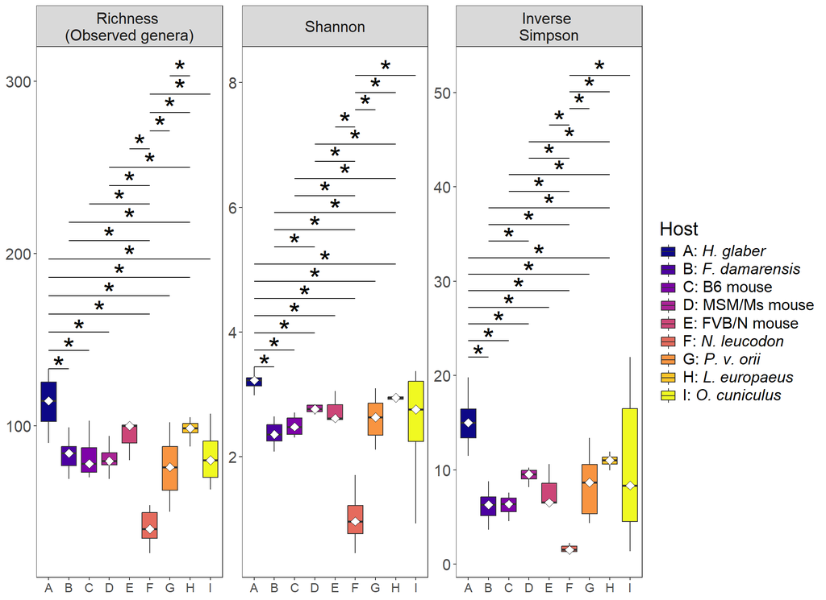

```r
print(newplot)
```

```r
rm(list = ls(all=TRUE))
gc()
```

```
##           used  (Mb) gc trigger  (Mb) max used  (Mb)
## Ncells 2860997 152.8    4347284 232.2  4347284 232.2
## Vcells 5015809  38.3   10146329  77.5  8002247  61.1
```

# 7 Differential microbial abundance tests with MaAsLin2, ALDEx2, and ANCOM-BC

## 7.1 Introduction

This script performs differential microbial abundance tests on different hosts. We will use MaAsLin2, ALDEx2, and ANCOM-BC.

## 7.2 Load necessary libraries.

```r
# if(!requireNamespace("BiocManager")){
#   install.packages("BiocManager")
# }
# Current: Bioconductor version 3.20 (BiocManager 1.30.27), R 4.4.3 (2025-02-28 ucrt)
```

ALDEx2: 1.38.0 Maaslin2: 1.20.0 ANCOM-BC: 2.8.1

```r
# BiocManager::install(c("Maaslin2","ALDEx2","ANCOMBC","phyloseq"), version = "3.20")
# BiocManager::install("ALDEx2", version = "3.17")
# BiocManager::install("ANCOMBC", version = "3.17")
# BiocManager::install("phyloseq", version = "3.17")
# install.packages(c("tidyverse","Polychrome"))
library(tidyverse)
```

```
## ✖ purrr::%||%()   masks base::%||%()
```

```r
library(Maaslin2)
library(ALDEx2)
library(ANCOMBC)
library(phyloseq)
library(Polychrome)
```

## 7.3 Specifying parameters and directory/file names.

Name of the folder with QIIME2 output:

```r
authorname<-"pooled"
```

Directories with input files:

```r
rdafiles.directory<-"./output/rdafiles"
rtables.directory<-file.path("./output/rtables",authorname)
```

Truncation level that we chose in QIIME2:

```r
truncationlvl<-"234"
```

Single reads or paired reads (decided in QIIME2):

```r
read.end.type<-"single"
rare.status<-"rare"
filter.status<-"nonfiltered"
```

## 7.4 Prepare necessary functions.

Function that performs differential abundance tests with different parameters. Instead of repeating the code for each comparison, call the function and change the parameters.

```r
prepare_data <- function(agglom.rank, comparison,
                         ref.level, inside.host){
  rdafiles.directory<-"./output/rdafiles"
  rare.status<-"rare"
  filter.status<-"nonfiltered"
  print(paste("Performing differential microbial abundance tests on", comparison, "variable at", agglom.rank, "level.",
              "Reference:", ref.level))
  #' Import abundance table as an rds file (NOT rarefied):
  if(inside.host == TRUE){
    if(agglom.rank == "OTU"){
      ps.q.agg.date_time<-"20260211_17_01_07" # ASV NMR
      ps.q.df.preprocessed.date_time <- "20260211_17_14_21"
    }
    custom.levels<-"NMR"
    custom.md<-readRDS("./output/rdafiles/custom.md.ages.rds")%>%
      filter(sequencing_type == "Naked mole-rat 16S rRNA gene sequencing")
  }else if(inside.host ==FALSE){
    if(agglom.rank == "Genus" ){
      ps.q.agg.date_time<-"20260211_17_01_10" # Genus all hosts
      custom.levels<-c("NMR",
                       "DMR",
                       "B6mouse",
                       "MSMmouse",
                       "FVBNmouse",
                       "spalax",
                       "pvo",
                       "hare",
                       "rabbit")
      custom.md<-readRDS("./output/rdafiles/custom.md.rds")
      ps.q.df.preprocessed.date_time <- "20260211_17_14_19"

    }
  }
  #' Import abundance table as an rds file (NOT rarefied):
  ps.q.agg<-readRDS(file=file.path(
    rdafiles.directory,
    paste(ps.q.agg.date_time,"phyloseq-qiime",authorname,agglom.rank,read.end.type,
          truncationlvl,"table.rds",sep = "-")))
  ps.q.agg<-ps.q.agg%>%
    filter(class%in%custom.levels,Abundance!=0)

  #' Rarefied abundance table:
  ps.q.df.preprocessed<-readRDS(
    file.path(rdafiles.directory,paste0(
      paste(
        ps.q.df.preprocessed.date_time,
        paste0("ps.q.df.",rare.status),filter.status,agglom.rank,
        paste(custom.levels,collapse = '-'),sep = "-"),
      ".rds")))
  if(inside.host ==TRUE){
    ps.q.df.preprocessed<-ps.q.df.preprocessed%>%
      filter(class=="NMR",Abundance!=0)
  }

  #' Specify output file name:
  output.filename<-paste(paste(custom.levels,collapse = '-'),
                         agglom.rank,comparison,
                         truncationlvl,"ref",ref.level,
                         sep="-")
  print(paste("Output filename prefix:", output.filename))
  # Preparing the wide dataset.
  ps.q.df.wide<-ps.q.df.preprocessed%>%
    dplyr::select(all_of(c("Sample",agglom.rank,"Abundance","class")))%>%
    filter(Abundance!=0)%>%
    pivot_wider(names_from = agglom.rank, # or OTU
                values_from = "Abundance",
                values_fill = 0)%>%
    as.data.frame()%>%
    column_to_rownames("Sample")%>%
    dplyr::select(-class)
  # Colnames are OTUs and rownames are sample IDs.
  if(setequal(custom.levels,"NMR")){
    if(comparison=="age"){
      sample.groups<-c("agegroup0_10",
                       "agegroup10_16")
    }else if(comparison=="sex"){
      sample.groups<-c("female",
                       "male")
    }
  }else{
    sample.groups<-custom.levels
  }
  print(sample.groups)
  print("Prepared the data for tests")

  return(list(dataset = ps.q.df.wide,
              ps.q.agg = ps.q.agg,
              output.filename = output.filename,
              metadata = custom.md,
              custom.levels = custom.levels,
              sample.groups = sample.groups))
}
```

Function that performs a test with MaAsLin2:

```r
perform_maaslin2_test <- function(ps.q.df.wide,
                                 output.filename,
                                 comparison,
                                 custom.md,
                                 custom.levels,
                                 ref.level,
                                 inside.host){
  authorname <-"pooled"
  rare.status<-"rare"
  # Create reference levels.
  if (comparison=="age"){
    maaslin.reference<-paste("agegroup", ref.level, sep = ",")
    maaslin.comparison<-"agegroup"
  }else if(comparison=="sex"){
    maaslin.reference<-paste("sex", ref.level, sep = ",")
    maaslin.comparison<-"sex"
  }

  if (inside.host == TRUE){
    if(setequal(custom.levels,"NMR")){
      relations<-read.table("./data/metadata/pooled-metadata/nmr-relations.tsv",
                            header = T,
                            sep = "\t")
      custom.md<-custom.md%>%
        left_join(relations,by="Sample")
      rownames(custom.md)<-custom.md$Sample
    }
  }

  # Run Maaslin2.
  if(inside.host==TRUE){
    set.seed(1)
    maaslin.fit_data =
      Maaslin2(input_data = ps.q.df.wide,
               input_metadata = custom.md,
               min_prevalence = 0,
               normalization = "TSS",
               transform = "LOG",
               analysis_method = "LM",
               random_effects = c("relation"),
               standardize = FALSE,
               output = file.path("./output/maaslin2",
                                  paste0(authorname,"-output"),
                                  rare.status,paste(
                                    paste(format(Sys.time(),format="%Y%m%d"),
                                          format(Sys.time(),
                                                 format = "%H_%M_%S"),sep = "_"),
                                    output.filename, "with-relations",sep = "-")),
               fixed_effects = maaslin.comparison,
               reference = maaslin.reference,
               max_significance = 0.05)
  }else{
    set.seed(1)
    maaslin.fit_data =
      Maaslin2(input_data = ps.q.df.wide,
               input_metadata = custom.md,
               min_prevalence = 0,
               analysis_method = "LM",
               normalization = "TSS",
               transform = "LOG",
               random_effects = NULL,
               standardize = FALSE,
               output = file.path("./output/maaslin2",
                                  paste0(authorname,"-output"),
                                  rare.status,paste(
                                    paste(format(Sys.time(),format="%Y%m%d"),
                                          format(Sys.time(),format = "%H_%M_%S"),sep = "_"),
                                    output.filename,sep = "-")),
               fixed_effects = c("class"),
               reference = paste0("class,",ref.level),
               max_significance = 0.05)

  }
  return(maaslin.fit_data)
}
```

Function to process the MaAsLin2 output:

```r
process_maaslin2_output<-function(agglom.rank,
                                  maaslin.fit_data,
                                  ps.q.agg,
                                  sample.groups){
  #' Downstream processing of Maaslin2 output.
  source("./code/r-scripts/make_features_maaslin.R")
  #' Extract features with qvalue < 0.05.
  if(min(maaslin.fit_data$results$qval)<0.05){
    maaslin.signif.features<-maaslin.fit_data$results%>%
      filter(qval<0.05) # should be qval
  }else{
    maaslin.signif.features<-maaslin.fit_data$results%>%
      arrange(qval)%>%
      head(n = 15) # if no significant results found
  }

  #' Make features pretty. We have to make this exchange because maaslin
  #' output treats space and hyphen as the same thing.
  if(agglom.rank=="OTU"){
    maaslin.signif.features$feature<-gsub("^X","",
                                          maaslin.signif.features$feature)
  }else{
    foo<-ps.q.agg
    foo<-foo%>%mutate("maaslin"=get(agglom.rank))
    foo<-make_features_maaslin(foo,"maaslin")
    foo<-unique(foo[,c("maaslin",agglom.rank)])
    maaslin.signif.features<-maaslin.signif.features%>%
      left_join(foo[,c("maaslin",agglom.rank)],by=c("feature"="maaslin"))%>%
      distinct()
    rm(foo)
    maaslin.signif.features$feature<-maaslin.signif.features[,agglom.rank]
    maaslin.signif.features<-subset(maaslin.signif.features,
                                    select=-get(agglom.rank))
  }

  #' Extract features that are downregulated in all hosts simultaneously.
  # if(setequal(custom.levels,"NMR")){
  #   if(comparison=="age"){
  #     sample.groups<-c("agegroup0_10",
  #                      "agegroup10_16")
  #   }else if(comparison=="sex"){
  #     sample.groups<-c("F",
  #                      "M")
  #   }
  # }else{
  #   sample.groups<-custom.levels
  # }
  # Downreglated features have coef<0.
  # We also add association strength column
  maaslin.signif.decreased<-maaslin.signif.features%>%
    as_tibble()%>%
    filter(coef<0)%>%
    group_by(feature)%>%
    filter(n()==length(sample.groups)-1)%>%
    arrange(pval,feature)%>%
    mutate(n=n())%>%
    mutate(assoc.str=-log(qval)*sign(coef))%>%
    ungroup()


  #' Check if all features (OTU/taxa/etc) are also present in the
  #' ps.q.agg dataframe.
  if(agglom.rank=="OTU"){
    table(maaslin.signif.decreased$feature%in%ps.q.agg$OTU)
  }else{
    table(maaslin.signif.decreased$feature%in%ps.q.agg[,agglom.rank])
  }
  # write.table(maaslin.signif.features,
  #             file=file.path("./output/rtables/pooled",paste(
  #               paste(format(Sys.time(),format="%Y%m%d"),
  #                     format(Sys.time(),format = "%H_%M_%S"),sep = "_"),
  #               "maaslin2",output.filename,
  #               "signif.tsv",sep="-")),
  #             row.names = F,sep = "\t")
  # write.table(maaslin.signif.decreased,
  #             file=file.path("./output/rtables/pooled",
  #                            paste(paste(format(Sys.time(),format="%Y%m%d"),
  #                                        format(Sys.time(),format = "%H_%M_%S"),
  #                                        sep = "_"),
  #                                  "maaslin.signif.decreased",
  #                                  output.filename,
  #                                  "signif.tsv",sep="-")),
  #             row.names = F,sep = "\t")
  return(list(maaslin.signif.features = maaslin.signif.features,
         maaslin.signif.decreased = maaslin.signif.decreased))

}
```

Function that performs a test with ANCOM-BC:

```r
perform_ancombc_test<-function(agglom.rank,
                               ps.q.df.wide,
                               ps.q.agg,
                               custom.md,
                               sample.groups){
  #' Extract the taxonomic table.
  if(agglom.rank=="OTU"){
    taxmat<-ps.q.agg%>%
      dplyr::select(OTU,Kingdom,Phylum,Class,Order,Family,Genus)%>%
      distinct()%>%
      column_to_rownames(var = "OTU")%>%
      as.matrix()
  }else{
    all.ranks<-c("Kingdom", "Phylum", "Class", "Order", "Family","Genus")
    agglom.rank.index<-match(agglom.rank,all.ranks)
    custom.ranks<-all.ranks[1:agglom.rank.index]

    taxmat<-ps.q.agg%>%
      ungroup()%>%
      dplyr::select(all_of(custom.ranks))%>%
      distinct()%>%
      column_to_rownames(var = all_of(agglom.rank))%>%
      as.matrix()
  }
  #' Create a phyloseq object for ANCOMBC.
  ps.q.OTU<-t(ps.q.df.wide)
  ps.q.OTU<-otu_table(ps.q.OTU,taxa_are_rows = T)
  ps.q.TAX<-tax_table(taxmat)
  ps.q.phyloseq.new<-phyloseq(otu_table(ps.q.OTU),
                              tax_table(ps.q.TAX),
                              sample_data(custom.md))

  #' Relevel the comparison vector. The first level will be the reference
  #' for custom leveling
  ancombc.levels<-c(ref.level,
                    sample.groups[sample.groups!=ref.level])
  if(comparison=="host"){
    sample_data(ps.q.phyloseq.new)$class<-
      factor(sample_data(ps.q.phyloseq.new)$class,
             levels = ancombc.levels)
    ancombc.comparison<-"class"
  }else if (comparison=="age"){
    sample_data(ps.q.phyloseq.new)$agegroup<-
      factor(sample_data(ps.q.phyloseq.new)$agegroup,
             levels = ancombc.levels)
    ancombc.comparison<-"agegroup"
  }else if(comparison=="sex"){
    sample_data(ps.q.phyloseq.new)$sex<-
      factor(sample_data(ps.q.phyloseq.new)$sex,
             levels = ancombc.levels)
    ancombc.comparison<-"sex"
  }

  #' Perform the differential abundance test.
  ancombc.out<-ancombc(
    data = ps.q.phyloseq.new,
    # tax_level = ,
    formula = ancombc.comparison,
    p_adj_method = "fdr",
    prv_cut = 0, # by default prevalence filter of 10% is applied
    lib_cut = 0,
    group = ancombc.comparison,
    struc_zero = TRUE,
    neg_lb = TRUE,
    tol = 1e-5,
    max_iter = 100,
    conserve = TRUE,
    alpha = 0.05,
    global = TRUE
  )
  return(ancombc.out)
}
```

Function that performs downstream processing of output from three tools (if you compare between hosts) or one tool (if you compare within host).

```r
analyse_test_output <-function(agglom.rank,
                               inside.host,
                               comparison,
                               custom.levels,
                               ref.level,
                               sample.groups,
                               output.filename,
                               custom.md,
                               ps.q.agg,
                               maaslin.signif.features,
                               maaslin.signif.decreased,
                               aldex.signif.features = NULL,
                               aldex.neg.effect = NULL,
                               ancombc.signif.features = NULL,
                               ancombc.signif.decreased = NULL){
  image.formats<-c("png","tiff")
  rtables.directory<-file.path("./output/rtables",authorname)

  if(inside.host==FALSE){
    #' Find common significant features between three tools.
    print(Reduce(intersect,list(maaslin.signif.features$feature,
                                aldex.signif.features$Taxon,
                                ancombc.signif.features$taxon_id)))

    #' Find common significantly decreased features between three tools.
    print(Reduce(intersect,list(maaslin.signif.decreased$feature,
                                aldex.neg.effect$Taxon,
                                ancombc.signif.decreased$taxon_id)))

    #' Common significant and decreased features between tools
    common.signif<-Reduce(intersect,list(maaslin.signif.features$feature,
                                         aldex.signif.features$Taxon,
                                         ancombc.signif.features$taxon_id))
    #' Only Maaslin2 and ANCOM-BC: they're decreased in other hosts, not in ref.
    common.decreased<-Reduce(intersect,list(maaslin.signif.decreased$feature,
                                            ancombc.signif.decreased$taxon_id))

    common.decreased.df<-ps.q.agg%>%
      filter(class==ref.level,Genus%in%common.decreased)%>%
      distinct(Genus,.keep_all = T)%>%
      ungroup()%>%
      arrange(-MeanRelativeAbundance)%>%
      dplyr::select(Genus,MeanRelativeAbundance)
    head(common.decreased.df)
    # write.table(common.decreased.df,
    #             file=file.path(rtables.directory,
    #                            paste(paste(format(Sys.time(),format="%Y%m%d"),
    #                                        format(Sys.time(),format = "%H_%M_%S"),
    #                                        sep = "_"),
    #                                  "significant-features",
    #                                  output.filename,
    #                                  "signif.tsv",sep="-")),
    #             row.names = F,sep = "\t")
  }


  #' Plot differentially abundant features.
  if(comparison=="host"){
    pretty.level.names<-
      c("NMR" = "*Heterocephalus glaber*", # better labels for facets
        "DMR" = "*Fukomys damarensis*",
        "B6mouse" = "B6 mouse",
        "MSMmouse" = "MSM/Ms mouse",
        "FVBNmouse" = "FVB/N mouse",
        "spalax" = "*Nannospalax leucodon*",
        "pvo" = "*Pteromys volans orii*",
        "hare" = "*Lepus europaeus*",
        "rabbit" = "*Oryctolagus cuniculus*"
      )
    ggplot.levels<-names(pretty.level.names)
    gg.labs.name<-"Host"
    gg.title.groups<-"hosts"
  }else if (comparison=="age"){
    pretty.level.names<-names(table(custom.md$agegroup))

    names(pretty.level.names)<-custom.md%>%
      ungroup%>%
      dplyr::select(agegroup)%>%
      distinct(agegroup)%>%
      arrange(agegroup)%>%
      pull

    ggplot.levels<-names(pretty.level.names)
    gg.labs.name<-"Age group"
    gg.title.groups<-"age groups"

  }else if (comparison=="sex"){
    pretty.level.names<-
      c("female" = "Females",
        "male" = "Males")
    ggplot.levels<-names(pretty.level.names)
    pretty.level.names<-pretty.level.names[
      which(names(pretty.level.names)%in%ggplot.levels)]
    gg.labs.name<-"Host sex"
    gg.title.groups<-"groups"
  }

  plot.theme <-theme(
    axis.title.y = element_blank(),
    axis.title = element_text(size = 5),
    axis.text.y = ggtext::element_markdown(size=5),
    # axis.text.y = element_text(size=5),
    axis.text.x = element_text(size=5),
    strip.text.x = ggtext::element_markdown(size=5),
    plot.title = element_text(size =5),
    legend.text = element_text(size = 5),
    legend.title = element_text(size = 5),
    legend.position = "none",
    panel.grid.minor = element_blank(),
    panel.grid.major = element_blank()
  )

  if(inside.host==TRUE){
    pretty.asv.names.df<-ps.q.agg%>%
      ungroup()%>%
      filter(get(agglom.rank)%in%maaslin.signif.features$feature,class=="NMR")%>%
      distinct(get(agglom.rank),.keep_all = T)%>%
      dplyr::select(OTU,Genus)%>%
      mutate(Taxon=paste0("ASV from ","<i>",Genus,"</i> (p = ",
                          round(maaslin.signif.features$qval,digits=3),")"))
    pretty.asv.names<-c(pretty.asv.names.df$Taxon)
    names(pretty.asv.names)<-pretty.asv.names.df$OTU

    if(comparison =="age"){
      feature.plot<-ps.q.agg%>%
        filter(get(agglom.rank)%in%maaslin.signif.features$feature,class=="NMR")%>%
        left_join(custom.md)%>%
        group_by_at(c(agglom.rank,"agegroup"))%>%
        ggplot(aes(x=factor(agegroup,levels=names(pretty.level.names)),
                   y=RelativeAbundance,
                   fill=factor(agegroup)))
    }else if(comparison =="sex"){
      feature.plot<-ps.q.agg%>%
        filter(get(agglom.rank)%in%maaslin.signif.features$feature,class=="NMR")%>%
        left_join(custom.md)%>%
        group_by_at(c(agglom.rank,"sex"))%>%
        ggplot(aes(x=factor(sex,levels=names(pretty.level.names)),
                   y=RelativeAbundance,
                   fill=factor(sex)))
    }
    feature.plot<-feature.plot +
      geom_boxplot(show.legend = FALSE)+
      facet_wrap(~OTU,scales = "free_y",
                 ncol = 2,
                 labeller = as_labeller(pretty.asv.names))+
      theme_bw()+
      labs(x="",
           y="Relative abundance (%)")+
      scale_x_discrete(labels=pretty.level.names,
                       limits=ggplot.levels)+ # rename boxplot labels (x axis)
      # scale_fill_manual(values = custom.fill)+
      scale_fill_viridis_d(direction = (-1),
                           end = 0.9,
                           alpha = 0.5)+
      # ggtitle(paste0("Relative abundance of differentially abundant ASVs \nin different naked mole-rat groups"))+
      plot.theme


    # for(image.format in image.formats){
    #   ggsave(paste0("./images/taxaboxplots/",
    #                 paste(paste(format(Sys.time(),format="%Y%m%d"),
    #                             format(Sys.time(),format = "%H_%M_%S"),sep = "_"),
    #                       ref.level,"specific-bacteria","NMR",comparison,
    #                       sep = "-"),".",image.format),
    #          plot=feature.plot,
    #          width=11, height=8,units="in",
    #          # width = 4500,height = 2500,units = "px",
    #          dpi=300,device = image.format)
    # }
  }else{
    feature.plot<-ps.q.agg%>%
      filter(get(agglom.rank)%in%common.decreased)%>%
      group_by_at(c("class",agglom.rank))%>%
      ggplot(aes(x=factor(class,levels=rev(ggplot.levels)),
                 y=RelativeAbundance,
                 fill=factor(class,levels=rev(ggplot.levels))))+
      geom_boxplot(show.legend = FALSE)+
      facet_wrap(~Genus,scales = "free_x",
                 ncol = 4)+
      theme_bw(base_size = 5)+
      coord_flip()+
      labs(x="",
           y="Relative abundance (%)")+
      scale_color_viridis_d(breaks = rev(unname(pretty.level.names)),
                            labels=rev(unname(pretty.level.names)))+
      scale_x_discrete(labels=rev(pretty.level.names),
                       limits=rev(ggplot.levels))+ # rename boxplot labels (x axis)
      scale_fill_viridis_d(option="C")+
      # ggtitle(paste0("Relative abundance of naked mole-rat-specific taxa"))+
      plot.theme


    # for(image.format in image.formats){
    #   ggsave(paste0("./images/taxaboxplots/",
    #                 paste(paste(format(Sys.time(),format="%Y%m%d"),
    #                             format(Sys.time(),format = "%H_%M_%S"),
    #                             sep = "_"),
    #                       "NMR-specific-bacteria",
    #                       sep = "-"),".",image.format),
    #          plot=feature.plot,
    #          width=8, height=11,units="in",
    #          # width = 4000,height = 12000,units = "px",
    #          dpi=300,device = image.format)
    # }

  }
  print(feature.plot)


}
```

## 7.5 Compare hosts (Genus level).

Choose what to compare:

```r
comparison<-"host"
```

Choose the reference level:

```r
ref.level<-"NMR"
agglom.rank<-"Genus"
inside.host<- FALSE
```

Prepare data for tests.

```r
host.data.for_test<-prepare_data(agglom.rank = agglom.rank,
             comparison = comparison,
             ref.level = ref.level,
             inside.host = inside.host)
```

```
## [1] "Performing differential microbial abundance tests on host variable at Genus level. Reference: NMR"
## [1] "Output filename prefix: NMR-DMR-B6mouse-MSMmouse-FVBNmouse-spalax-pvo-hare-rabbit-Genus-host-234-ref-NMR"
```

```
## [1] "NMR"       "DMR"       "B6mouse"   "MSMmouse"  "FVBNmouse" "spalax"
## [7] "pvo"       "hare"      "rabbit"
## [1] "Prepared the data for tests"
```

### 7.5.1 Run a test with MaAsLin2.

```r
maaslin.fit_data.host<-
  perform_maaslin2_test(ps.q.df.wide = host.data.for_test$dataset,
                        comparison = comparison,
                        output.filename = host.data.for_test$output.filename,
                        custom.md = host.data.for_test$metadata,
                        custom.levels = host.data.for_test$custom.levels,
                        ref.level = ref.level,
                        inside.host = inside.host
                     )
```

[output not shown]

[output cut: 431 more lines]

[output not shown]

[output not shown]

[output not shown]

[output not shown]

[output not shown]

[output not shown]

[output not shown]

[output not shown]

[output not shown]

[output not shown]

[output not shown]

[output not shown]

[output not shown]

[output not shown]

[output not shown]

[output not shown]

[output not shown]

[output not shown]

[output not shown]

[output not shown]

[output not shown]

[output not shown]

[output not shown]

[output not shown]

[output not shown]

[output not shown]

[output not shown]

[output not shown]

[output not shown]

[output not shown]

[output not shown]

[output not shown]

[output not shown]

[output not shown]

[output not shown]

[output not shown]

[output not shown]

[output not shown]

[output not shown]

[output not shown]

[output not shown]

[output not shown]

[output not shown]

[output not shown]

[output not shown]

[output not shown]

[output not shown]

[output not shown]

[output not shown]

[output not shown]

[output not shown]

[output not shown]

[output not shown]

[output not shown]

[output not shown]

[output not shown]

[output not shown]

[output not shown]

[output not shown]

[output not shown]

[output not shown]

[output not shown]

[output not shown]

[output not shown]

[output not shown]

[output not shown]

[output not shown]

[output not shown]

[output not shown]

[output not shown]

[output not shown]

[output not shown]

[output not shown]

[output not shown]

[output not shown]

[output not shown]

[output not shown]

[output not shown]

[output not shown]

[output not shown]

[output not shown]

[output not shown]

[output not shown]

[output not shown]

[output not shown]

[output not shown]

[output not shown]

[output not shown]

[output not shown]

[output not shown]

[output not shown]

[output not shown]

[output not shown]

[output not shown]

[output not shown]

[output not shown]

[output not shown]

[output not shown]

[output not shown]

[output not shown]

[output not shown]

[output not shown]

[output not shown]

[output not shown]

[output not shown]

[output not shown]

[output not shown]

[output not shown]

[output not shown]

[output not shown]

[output not shown]

[output not shown]

[output not shown]

[output not shown]

[output not shown]

[output not shown]

[output not shown]

[output not shown]

[output not shown]

[output not shown]

[output not shown]

[output not shown]

[output not shown]

[output not shown]

[output not shown]

[output not shown]

[output not shown]

[output not shown]

[output not shown]

[output not shown]

[output not shown]